# Modeling: PBS Utah Major Donor Prediction

Author

Benjamin Hogan

Published

October 21, 2026

## 1 Introduction

### 1.1 Business Problem

Congress ended federal funding for public broadcasting in 2025, and PBS Utah now expects a recurring shortfall of about $2 million per year. Major donors, people who give $1,200 or more in a fiscal year, are about 0.3% of donors but give about 8% of individual donor revenue (FY2021 to FY2026). PBS Utah does not have a reliable, data-driven way to find which current non-major donors are most likely to become major donors, or at what giving level. Development staff need a ranked list of prospects they can work through, and the officer cultivation program can work about 1,000 donors a year.

### 1.2 Analytic Problem

The analytic problem is to rank donors by their chance of a rare event. The setup follows the group EDA:

- **Unit of analysis.** One person at the end of fiscal year t (June 30), called a donor-year. A donor-year is eligible if the person gave in FY t and was not a major donor in FY t. Every feature uses only information dated on or before June 30 of FY t.
- **Primary target.** Whether the person becomes a major donor in FY t+1, meaning $1,200 or more of their own giving and soft credits, or a couple reaching $1,200 together.
- **Secondary targets.** Becoming a major donor within 3 years and within 5 years of FY t, and the giving tier reached in the conversion year ($1,200, $2,000, or $5,000 and up).
- **How rare the outcome is.** Each cohort from FY2021 to FY2024 has 31,000 to 33,000 eligible donors and only 37 to 55 converters, about 0.15% overall. A model that predicts “no” for everyone would be more than 99.8% accurate, so accuracy says nothing here. Models are judged on how well they rank.
- **Success measure.** Recall at a list of 1,000, the share of next-year converters who appear in a model’s top 1,000. Precision and lift at 1,000 are reported alongside it. The test cohorts are FY2022 to FY2024, which hold 134 converters, 59 of them donors who had never been major before.
- **Benchmark.** Ranking donors by their FY t giving alone already puts 75.4% of test-cohort converters in the top 1,000, and 59.6% of never-major converters. A model is only useful if it beats that ranking and also clears a simple rule that lists former major donors and anyone who gave $500 or more.

Two features of the data make this harder than an ordinary classification problem. Officer contact changes whether a donor converts, so the contact flags can be used in training but have to be switched off when donors are scored. The FY2026 influx changed the conversion rate, so the FY2025 cohort, whose outcomes fall in FY2026, is kept out of model selection.

### 1.3 Purpose of This Notebook

This is my individual modeling notebook. It builds on the group EDA rather than repeating it: it uses the same shared build script, the same definitions, the same baselines, and the same validation design. The team will compare the individual modeling notebooks and combine them into a group notebook later.

The notebook works through the following:

1. Builds a feature table from the group EDA’s feature list and adds engineered features (Data Preparation).
2. Reproduces the baselines with the same evaluation code the models use (Benchmarks).
3. Screens a wide range of model families, then narrows to the most promising ones through feature engineering, a comparison of training windows, and hyperparameter tuning (Modeling Process).
4. Chooses the best model with a rule that guards against picking a model that only did well by chance (Model Comparison and Selection).
5. Reports the chosen model’s in-sample and out-of-sample performance, calibration, run time, and main drivers, and checks it once on the FY2025 cohort (Best Model Performance).
6. Extends the shortlist to the 3 and 5 year outcomes and to the giving tier (Longer Windows and Giving Tier).
7. Asks whether the results are good enough to help PBS Utah close the gap (Business Validation and Results).

### 1.4 Decisions Carried Over From the Group EDA

Decisions carried over from the group EDA

| Topic | Rule used in this notebook |
| --- | --- |
| Cleaning and panel | The group EDA’s shared build script, copied unchanged: content-based removal of copy rows, legacy gifts credited to the first listed person, and the household rule. |
| Eligible population | Donors who gave in FY t and were not major in FY t. Former major donors stay in and are flagged. Lapsed donors are reported separately, not modeled. |
| Features | Only information dated on or before June 30 of FY t. The PBS classification fields and the University of Utah dollar fields are dropped because they encode later giving. |
| Cultivation contact | Contacted and held-out flags are used in training only and are switched off when scoring. |
| Validation | Rolling tests on FY2022, FY2023, and FY2024, each trained on earlier cohorts, with spouses kept in the same fold. Tuning happens inside the training cohorts. |
| FY2025 cohort | Not used for model selection. Used once at the end as a labeled check, then added to the final training data. |
| Baselines | Prior-year giving is the bar. The former major or $500 rule is a second check. RFV, giving thresholds, and random selection are reported for context. |
| Uncertainty | Couple-clustered bootstrap intervals, and model-versus-baseline comparisons made on the same bootstrap draws. |

### 1.5 Decisions Made for This Notebook

- **No model family is ruled out in advance.** Every family that can rank donors is screened first, and only the ones that earn it move on to feature engineering and full tuning.
- **The training window is an experiment.** Cohorts from FY2021 on have every feature but few converters. Legacy-era cohorts back to FY1999 add several hundred converters but only have giving history. Both, and a mix of the two, are compared on the same test cohorts.
- **Several tuning metrics are tracked.** Average precision, ROC AUC, log loss, and recall at a fixed share of each fold are all recorded, and I check whether the choice of metric changes the result.
- **A more complex model has to earn its place.** With 134 test converters, a few lucky hits can separate two models. A more complex model replaces a simpler one only if its gain holds on paired bootstrap draws, and the FY2025 check is run once, after the choice is made.
- **The 12 month outcome gets the full treatment.** The 3 and 5 year outcomes reuse the shortlist with a smaller tuning grid and are reported as projections. For the tier, three approaches are compared.

## 2 Data Preparation

```python
import time
from pathlib import Path

import pandas as pd
import polars as pl
from plotnine import *

import build_panel as bp

RAW = Path("tables")
CACHE = Path("data_cache")

# the same shared build as the group EDA, so definitions and counts match it
build_start = time.perf_counter()
raw = bp.load_tables(RAW, CACHE)                 # raw tables, typed and snake-cased
clean, audit = bp.clean_tables(raw)              # shared cleaning rules
person_years = bp.build_person_years(clean)      # one row per person per fiscal year
cohorts = bp.build_cohorts(person_years)         # eligible and lapsed donors at each snapshot
build_seconds = time.perf_counter() - build_start

# formatting helpers for inline numbers in the text
def n(x):
    return f"{x:,.0f}"

def pct(x, d=1):
    return f"{100 * x:.{d}f}%"

def pp(x, d=2):
    # a difference between two rates, in percentage points
    return f"{100 * x:.{d}f}"

def usd(x):
    return f"${x:,.0f}"

HEADER_NAMES = {"t": "FY t", "fy": "FY", "n_unique": "Distinct values", "dtype": "Type"}
HEADER_WORDS = (("_fy_t_", "_FY t_"), ("_fy_", "_FY_"), ("_ci_", "_CI_"), ("_auc_", "_AUC_"), ("_rfv_", "_RFV_"))

def readable(col):
    # snake_case column name to a readable table header
    if col in HEADER_NAMES:
        return HEADER_NAMES[col]
    text = f"_{col}_"
    for old, new in HEADER_WORDS:
        text = text.replace(old, new)
    text = text.strip("_").replace("_", " ")
    return text[0].upper() + text[1:]

def show(df, pct_cols=(), pct_digits=1, caption=None):
    # render a polars frame as a captioned html table, keeping year columns free of separators
    out = df.with_columns([
        pl.col(c).map_elements(lambda v: f"{100 * v:.{pct_digits}f}%", return_dtype=pl.String) for c in pct_cols
    ])
    year_cols = ("fy", "t", "cohort", "test_cohort")
    out = out.with_columns([pl.col(c).cast(pl.String) for c in out.columns if c in year_cols])
    out = out.rename({c: readable(c) for c in out.columns})
    styled = out.to_pandas().style.format(thousands=",", precision=2, na_rep="").hide(axis="index")
    return styled.set_caption(caption) if caption else styled

_ = theme_set(theme_minimal() + theme(figure_size=(8, 4)))  # assign so the old theme is not printed
```

The shared build produces 572,487 person-years and 2,209,529 cohort rows in 7 seconds.

### 2.1 Feature Table

The models need one row per eligible donor-year with every feature measured at June 30 of FY t. The eligible donors at a given FY t are the same for every outcome window, so I keep one row per donor-year and store the 12 month, 3 year, and 5 year outcomes as separate target columns. A longer outcome is left empty when its window runs past FY2026. Lapsed donors are left out, since the group EDA found too few converters among them to model.

The features come from the shared build script’s functions, the same ones the group EDA used to test signals within giving bands. Solicitation and Passport records start in FY2021, so for earlier cohorts those features are set to missing rather than zero, because “not solicited” and “no record exists yet” are different things.

```python
ENGAGEMENT_START = 2021   # first fiscal year with solicitation and Passport records
SNAPSHOT_FY = 2026        # the constituent snapshot (age) is taken in FY2026

# eligible donor-years; the 3 and 5 year outcomes join on as extra target columns
active = cohorts.filter(pl.col("segment") == "active")
frame = active.filter(pl.col("window") == 1).select(
    "constituent_id", "couple_id", "t", "prior_total", "former_major", y_12m="converted"
)
for w, name in ((3, "y_3yr"), (5, "y_5yr")):
    frame = frame.join(
        active.filter(pl.col("window") == w).select("constituent_id", "t", pl.col("converted").alias(name)),
        on=["constituent_id", "t"], how="left",
    )
n_rows = frame.height

# each feature step is a function of the cleaned tables, so the leakage check can rerun it on truncated data
def add_base_features(rows, clean, person_years):
    """Giving history, solicitation, Passport, constituent fields, and cultivation flags at the end of FY t."""
    # giving history from gifts dated on or before June 30 of FY t
    gifts = bp.individual_gifts(clean)
    rows = (
        rows.join(bp.giving_features(rows, person_years, gifts), on=["constituent_id", "t"], how="left")
        .with_columns(
            change_from_last_year=pl.col("prior_total") - pl.col("prev_total"),
            largest_gift_share=pl.col("largest_gift_t") / pl.col("prior_total"),
        )
        .drop("recurring_amt", "recurring_payments")   # only used to build sustainer and monthly_amount
    )

    # solicitation and Passport; missing before FY2021, when no records exist
    sol = bp.solicitation_features(rows, bp.solicitation_by_year(clean))
    pas = bp.passport_features(rows, clean["passport"])
    engagement_cols = [c for c in sol.columns + pas.columns if c not in ("constituent_id", "t")]
    rows = (
        rows.join(sol, on=["constituent_id", "t"], how="left")
        .join(pas, on=["constituent_id", "t"], how="left")
        .with_columns([pl.when(pl.col("t") >= ENGAGEMENT_START).then(pl.col(c)).alias(c) for c in engagement_cols])
    )

    # constituent fields the group EDA kept, with age shifted back to FY t
    con = clean["constituents"]
    rows = (
        rows.join(con.select("constituent_id", "age", "gender", "address_state", "spouse_constituent_id",
                             "primary_constituent_type"), on="constituent_id", how="left")
        .with_columns(
            age_at_t=pl.col("age") - (SNAPSHOT_FY - pl.col("t")),
            gender=pl.col("gender").fill_null("Unknown"),
            lives_in_utah=pl.col("address_state") == "UT",
            spouse_on_file=pl.col("spouse_constituent_id").is_not_null(),
            type_group=pl.when(pl.col("primary_constituent_type").is_in(["Friends", "Donors"])).then(pl.col("primary_constituent_type"))
                .when(pl.col("primary_constituent_type").str.starts_with("Alumni")).then(pl.lit("Alumni"))
                .otherwise(pl.lit("other University affiliation")),
        )
        .drop("age", "address_state", "spouse_constituent_id", "primary_constituent_type")
    )

    # cultivation: a donor selected in FY t is contacted or held out during FY t+1
    cult = clean["cultivation"].select(constituent_id="synthetic_id", t="fiscal_year", cult_contacted="contacted")
    assert cult.select("constituent_id", "t").is_unique().all()
    return (
        rows.join(cult, on=["constituent_id", "t"], how="left")
        .with_columns(
            selected=pl.col("cult_contacted").is_not_null(),          # officer selection, used as a benchmark only
            contacted=pl.col("cult_contacted").fill_null(False),
            held_out=pl.col("cult_contacted").is_not_null() & ~pl.col("cult_contacted").fill_null(True),
        )
        .drop("cult_contacted")
        .sort("t", "constituent_id")
    )

frame = add_base_features(frame, clean, person_years)
assert frame.height == n_rows   # no join added or dropped donor-years
# every selected donor is either contacted or held out, never both
assert (frame["contacted"] & frame["held_out"]).sum() == 0
assert ((frame["contacted"] | frame["held_out"]) == frame["selected"]).all()
```

```python
ERAS = ["legacy era, FY1999 to FY2020", "FY2021 (training only)", "FY2022 to FY2024 (test)", "FY2025 (final check)"]
era = (pl.when(pl.col("t") < 2021).then(pl.lit(ERAS[0])).when(pl.col("t") == 2021).then(pl.lit(ERAS[1]))
       .when(pl.col("t") <= 2024).then(pl.lit(ERAS[2])).otherwise(pl.lit(ERAS[3])).cast(pl.Enum(ERAS)))
era_summary = (
    frame.group_by(era=era)
    .agg(cohorts=pl.col("t").n_unique(), donor_years=pl.len(),
         converters_12m=pl.col("y_12m").sum(), never_major_12m=(pl.col("y_12m") & ~pl.col("former_major")).sum(),
         converters_3yr=pl.col("y_3yr").sum(), converters_5yr=pl.col("y_5yr").sum(),
         has_engagement=pl.col("solicitations").is_not_null().mean())
    .sort("era")
)
es = {r["era"]: r for r in era_summary.iter_rows(named=True)}
show(era_summary, pct_cols=["has_engagement"], pct_digits=0,
     caption="Feature table by era: donor-years, converters by outcome window, and engagement coverage")
```

Table 1: Feature table by era: donor-years, converters by outcome window, and engagement coverage

| Era | Cohorts | Donor years | Converters 12m | Never major 12m | Converters 3yr | Converters 5yr | Has engagement |
| --- | --- | --- | --- | --- | --- | --- | --- |
| legacy era, FY1999 to FY2020 | 22 | 370,962 | 522 | 318 | 1,224 | 1,686 | 0% |
| FY2021 (training only) | 1 | 30,843 | 55 | 29 | 114 | 169 | 100% |
| FY2022 to FY2024 (test) | 3 | 97,190 | 134 | 59 | 229 | 0 | 100% |
| FY2025 (final check) | 1 | 32,886 | 81 | 44 | 0 | 0 | 100% |

The table has 531,881 donor-years across 27 cohorts. The split matters for the experiments later. The FY2021 to FY2024 cohorts have every feature but only 189 converters at 12 months, while the legacy-era cohorts add 522 more with giving history only. Longer outcomes are counted only for cohorts whose window ends by FY2026, so the FY2025 cohort has no 3 year outcome and the 5 year outcome stops at FY2021.

### 2.2 Giving Features Across the Two Gift Systems

Gifts before FY2021 come from the legacy system and later gifts from Unite. The shared build takes sustainer status, the monthly sustainer amount, and upgrade and additional gifts from Unite payments only, which is all the group EDA needed because it studied the FY2021 to FY2024 cohorts. Here they would read “no” for every legacy-era donor, which would make the legacy cohorts look worse than they are in the training window comparison. The legacy table records the same things: each gift is either one-time or sustaining, and its gift type includes upgrades and additional gifts. I rebuild the four features from both systems.

Soft credits are different, because they only exist from FY2021. Soft credits in FY t are set to missing before FY2021, and soft credits before FY t are missing through the FY2021 cohort, since no earlier soft credits exist. I also add a new sustainer flag, a donor who sustains in FY t but did not in FY t-1. It does not use payment counts, because legacy sustainers show two to six payments a year while Unite sustainers show eleven or twelve.

```python
UNITE_START = 2021   # first fiscal year of Unite payments and soft credits; legacy gifts end in FY2020

def gift_flags_by_year(clean, person_years):
    """Sustaining and gift-type flags per person-year, from Unite (FY2021 on) and legacy (FY2020 and earlier)."""
    unite_flags = person_years.filter(pl.col("fy") >= UNITE_START).select(
        "constituent_id", "fy",
        sustainer_y=pl.col("recurring_payments") > 0,
        monthly_y=pl.when(pl.col("recurring_payments") > 0).then(pl.col("recurring_amt") / pl.col("recurring_payments")),
        upgrade_y=pl.col("upgrade_gift"),
        additional_y=pl.col("additional_gift"),
    )
    legacy_flags = (
        clean["legacy"]
        .with_columns(fy=bp.fiscal_year("gift_date"), sustaining=pl.col("gift_kind") == "Sustaining")
        .group_by(pl.col("constituent_id_1").alias("constituent_id"), "fy")
        .agg(
            sustainer_y=pl.col("sustaining").any(),
            monthly_y=pl.col("payment_amount").filter(pl.col("sustaining")).mean(),
            upgrade_y=(pl.col("gift_type") == "Upgrade").any(),
            additional_y=(pl.col("gift_type") == "Additional").any(),
        )
    )
    flags = pl.concat([unite_flags, legacy_flags], how="vertical_relaxed")
    assert flags.select("constituent_id", "fy").is_unique().all()   # the two systems never share a year
    return flags

def add_era_consistent(rows, clean, person_years):
    """Replace the Unite-only gift features with versions from both systems, and mask soft credits before FY2021."""
    flags = gift_flags_by_year(clean, person_years)
    prev_flags = flags.select("constituent_id", t=pl.col("fy") + 1, sustainer_prev="sustainer_y")
    return (
        rows.drop("sustainer", "monthly_amount", "upgrade_gift", "additional_gift")
        .join(flags.rename({"fy": "t"}), on=["constituent_id", "t"], how="left")
        .join(prev_flags, on=["constituent_id", "t"], how="left")
        .with_columns(
            sustainer=pl.col("sustainer_y").fill_null(False),
            monthly_amount=pl.col("monthly_y"),
            upgrade_gift=pl.col("upgrade_y").fill_null(False),
            additional_gift=pl.col("additional_y").fill_null(False),
            new_sustainer=pl.col("sustainer_y").fill_null(False) & ~pl.col("sustainer_prev").fill_null(False),
            # soft credits start in FY2021, so they are unknown before then
            soft_in_t=pl.when(pl.col("t") >= UNITE_START).then(pl.col("soft_in_t")),
            soft_before=pl.when(pl.col("t") > UNITE_START).then(pl.col("soft_before")),
        )
        .drop("sustainer_y", "monthly_y", "upgrade_y", "additional_y", "sustainer_prev")
    )

# the Unite part has to reproduce the shared build's features exactly
gift_flags = gift_flags_by_year(clean, person_years)
check = frame.filter(pl.col("t") >= UNITE_START).join(gift_flags.rename({"fy": "t"}), on=["constituent_id", "t"], how="left")
assert (check["sustainer"] == check["sustainer_y"].fill_null(False)).all()
assert (check["monthly_amount"].fill_null(-1) == check["monthly_y"].fill_null(-1)).all()
assert (check["upgrade_gift"] == check["upgrade_y"].fill_null(False)).all()
assert (check["additional_gift"] == check["additional_y"].fill_null(False)).all()

frame = add_era_consistent(frame, clean, person_years)
assert frame.height == n_rows

# the rebuilt features side by side in the two eras
era2 = pl.when(pl.col("t") < UNITE_START).then(pl.lit("legacy era, FY1999 to FY2020")).otherwise(pl.lit("Unite era, FY2021 to FY2025"))
era_flags = (
    frame.group_by(era=era2)
    .agg(sustainer=pl.col("sustainer").mean(), median_monthly_amount=pl.col("monthly_amount").median(),
         new_sustainer_among_sustainers=pl.col("new_sustainer").filter(pl.col("sustainer")).mean(),
         upgrade_gift=pl.col("upgrade_gift").mean(), additional_gift=pl.col("additional_gift").mean())
    .sort("era")
)
ef = {r["era"]: r for r in era_flags.iter_rows(named=True)}
sust_by_t = dict(frame.group_by("t").agg(pl.col("sustainer").mean()).iter_rows())
show(era_flags, pct_cols=["sustainer", "new_sustainer_among_sustainers", "upgrade_gift", "additional_gift"],
     caption="Sustaining and gift-type features in the legacy and Unite eras")
```

Table 2: Sustaining and gift-type features in the legacy and Unite eras

| Era | Sustainer | Median monthly amount | New sustainer among sustainers | Upgrade gift | Additional gift |
| --- | --- | --- | --- | --- | --- |
| Unite era, FY2021 to FY2025 | 65.2% | 6.00 | 21.3% | 2.1% | 16.4% |
| legacy era, FY1999 to FY2020 | 33.5% | 6.00 | 26.9% | 2.1% | 18.9% |

The Unite part of the rebuilt features matches the shared build exactly, so nothing changes for the FY2021 to FY2025 cohorts except the new sustainer flag and the soft-credit masking. The legacy-era versions behave like the Unite ones. The median monthly amount is $6 in both eras, and upgrade gifts appear in about 2% of donor-years in each. The share of donors who sustain is about half as large in the legacy era overall, but that is a trend rather than a break between systems: it rises from 14% in FY1999 to 62% in FY2020 and keeps rising to 69% in FY2025, with no jump at the switch to Unite.

### 2.3 Features From the Group EDA

The registry below lists every feature, its group, and its status from the group EDA’s feature table. Later sections build their feature sets from this registry, so a feature’s status here is the status it has in every model. Engineered features are added to it in the next subsection.

```python
# feature -> (group, status, definition); status follows the group EDA's feature table
FEATURES = {
    "prior_total":            ("giving history", "use", "Giving in FY t: own payments, soft credits, and legacy gifts"),
    "former_major":           ("giving history", "use", "Major donor in any earlier fiscal year"),
    "prev_total":             ("giving history", "use", "Giving in FY t-1"),
    "change_from_last_year":  ("giving history", "use", "FY t giving minus FY t-1 giving"),
    "two_years_before":       ("giving history", "use", "Total giving in FY t-2 and FY t-1"),
    "years_last5":            ("giving history", "use", "Fiscal years with a gift, FY t-4 to FY t"),
    "years_since_first_gift": ("giving history", "use", "Years from the first fiscal year with a gift (legacy included) to FY t"),
    "legacy_years":           ("giving history", "use", "Fiscal years with a legacy-system gift"),
    "legacy_gift_count":      ("giving history", "use", "Number of legacy-system gifts"),
    "largest_gift_t":         ("giving history", "use", "Largest single gift in FY t"),
    "largest_gift_share":     ("giving history", "use", "Largest single gift as a share of FY t giving"),
    "sustainer":              ("giving history", "use", "Made a recurring (Unite) or sustaining (legacy) payment in FY t"),
    "monthly_amount":         ("giving history", "use", "Average sustaining payment in FY t (empty for non-sustainers)"),
    "soft_before":            ("giving history", "use", "Received a soft credit before FY t (empty through FY2021)"),
    "days_since_last_gift":   ("giving history", "test", "Days from the last gift to June 30 of FY t (empty for sustainers)"),
    "upgrade_gift":           ("giving history", "test", "Made an upgrade gift in FY t (Unite or legacy gift type)"),
    "additional_gift":        ("giving history", "test", "Made an additional gift in FY t (Unite or legacy gift type)"),
    "soft_in_t":              ("giving history", "test", "Received a soft credit in FY t (empty before FY2021)"),
    "solicitations":          ("solicitation", "test", "Solicitations in FY t"),
    "responses":              ("solicitation", "test", "Responses dated in FY t"),
    "solicitations_3yr":      ("solicitation", "test", "Solicitations in FY t-2 to FY t (records start in FY2021)"),
    "by_mail":                ("solicitation", "test", "Solicited by mail in FY t"),
    "by_email":               ("solicitation", "test", "Solicited by email in FY t"),
    "by_digital":             ("solicitation", "test", "Solicited by digital channels in FY t"),
    "by_phone_or_in_person":  ("solicitation", "test", "Solicited by phone or in person in FY t"),
    "titles":                 ("Passport", "test", "Passport titles viewed in FY t (empty when no record)"),
    "genres":                 ("Passport", "test", "Passport genres viewed in FY t (empty when no record)"),
    "share_watched":          ("Passport", "test", "Average share of each title watched in FY t (empty when no record)"),
    "viewed_t":               ("Passport", "test", "Has a Passport record in FY t"),
    "viewed_by_t":            ("Passport", "test", "Has a Passport record in any year up to FY t"),
    "age_at_t":               ("person", "use", "Age at June 30 of FY t, from the FY2026 snapshot age"),
    "gender":                 ("person", "use", "Female, Male, or Unknown"),
    "lives_in_utah":          ("person", "test", "Address in Utah"),
    "spouse_on_file":         ("person", "test", "Has a spouse record"),
    "type_group":             ("person", "sensitivity only", "Constituent type: Friends, Donors, Alumni, or other University affiliation"),
    "contacted":              ("cultivation", "training only", "Selected in FY t and contacted in FY t+1 (off when scoring)"),
    "held_out":               ("cultivation", "training only", "Selected in FY t and held out of contact (off when scoring)"),
}
missing_from_frame = [f for f in FEATURES if f not in frame.columns]
assert not missing_from_frame, missing_from_frame

registry = pl.DataFrame(
    [{"feature": f, "group": g, "status": s, "definition": d} for f, (g, s, d) in FEATURES.items()]
)
status_counts = dict(registry.group_by("status").len().iter_rows())
show(registry, caption="Features carried over from the group EDA, with their status")
```

Table 3: Features carried over from the group EDA, with their status

| Feature | Group | Status | Definition |
| --- | --- | --- | --- |
| prior_total | giving history | use | Giving in FY t: own payments, soft credits, and legacy gifts |
| former_major | giving history | use | Major donor in any earlier fiscal year |
| prev_total | giving history | use | Giving in FY t-1 |
| change_from_last_year | giving history | use | FY t giving minus FY t-1 giving |
| two_years_before | giving history | use | Total giving in FY t-2 and FY t-1 |
| years_last5 | giving history | use | Fiscal years with a gift, FY t-4 to FY t |
| years_since_first_gift | giving history | use | Years from the first fiscal year with a gift (legacy included) to FY t |
| legacy_years | giving history | use | Fiscal years with a legacy-system gift |
| legacy_gift_count | giving history | use | Number of legacy-system gifts |
| largest_gift_t | giving history | use | Largest single gift in FY t |
| largest_gift_share | giving history | use | Largest single gift as a share of FY t giving |
| sustainer | giving history | use | Made a recurring (Unite) or sustaining (legacy) payment in FY t |
| monthly_amount | giving history | use | Average sustaining payment in FY t (empty for non-sustainers) |
| soft_before | giving history | use | Received a soft credit before FY t (empty through FY2021) |
| days_since_last_gift | giving history | test | Days from the last gift to June 30 of FY t (empty for sustainers) |
| upgrade_gift | giving history | test | Made an upgrade gift in FY t (Unite or legacy gift type) |
| additional_gift | giving history | test | Made an additional gift in FY t (Unite or legacy gift type) |
| soft_in_t | giving history | test | Received a soft credit in FY t (empty before FY2021) |
| solicitations | solicitation | test | Solicitations in FY t |
| responses | solicitation | test | Responses dated in FY t |
| solicitations_3yr | solicitation | test | Solicitations in FY t-2 to FY t (records start in FY2021) |
| by_mail | solicitation | test | Solicited by mail in FY t |
| by_email | solicitation | test | Solicited by email in FY t |
| by_digital | solicitation | test | Solicited by digital channels in FY t |
| by_phone_or_in_person | solicitation | test | Solicited by phone or in person in FY t |
| titles | Passport | test | Passport titles viewed in FY t (empty when no record) |
| genres | Passport | test | Passport genres viewed in FY t (empty when no record) |
| share_watched | Passport | test | Average share of each title watched in FY t (empty when no record) |
| viewed_t | Passport | test | Has a Passport record in FY t |
| viewed_by_t | Passport | test | Has a Passport record in any year up to FY t |
| age_at_t | person | use | Age at June 30 of FY t, from the FY2026 snapshot age |
| gender | person | use | Female, Male, or Unknown |
| lives_in_utah | person | test | Address in Utah |
| spouse_on_file | person | test | Has a spouse record |
| type_group | person | sensitivity only | Constituent type: Friends, Donors, Alumni, or other University affiliation |
| contacted | cultivation | training only | Selected in FY t and contacted in FY t+1 (off when scoring) |
| held_out | cultivation | training only | Selected in FY t and held out of contact (off when scoring) |

Of the 37 features, 16 are in the group EDA’s “use” list and 18 were expected to add little and are kept to be tested. Most of the “test” features are solicitation and Passport measures, which only exist from FY2021. The two cultivation flags are used in training only: every donor is scored with both switched off, so the ranking reflects the donor and not whether an officer happened to call. The `selected` column, which marks every donor officers chose, is kept outside the registry because it is the officer-selection benchmark, not a feature.

Two features need a caution. The three-year solicitation count covers only one year for the FY2021 cohort and two years for FY2022, because solicitation records start in FY2021. Age is the snapshot age shifted back to FY t. The data dictionary says snapshot fields describe each constituent as of the end of the data, so I treat the snapshot age as the age in FY2026, as the group EDA did.

### 2.4 Engineered Features

The group EDA’s features describe how much a donor gave and how often. The engineered features below target patterns the EDA found but the carried-over features capture only indirectly. All of them use the same June 30 cutoff.

- **Former major detail.** About half of converters are former major donors, and a yes or no flag treats a donor who was major last year the same as one who was major twenty years ago. I add the number of past major years, the years since the last one, and the largest annual total before FY t.
- **Shape of giving.** Annual totals cluster at exact amounts, with a group at $600 and a gap just below $1,200. Flags at $500 and $600 let linear models pick up those steps, which they cannot do from raw dollars. I left out a $1,000 flag because only 15 eligible donor-years gave between $1,000 and $1,199, which is the gap the EDA found. I also add the ratio of FY t giving to FY t-1 giving and a three-year trend (the least-squares slope of giving over FY t-2 to FY t, which works out to half the change from FY t-2 to FY t).
- **Couple giving.** Under the household rule a couple can convert together, so the spouse’s FY t giving and the couple’s combined total are known at the prediction date and could matter.
- **Recency.** A gift between April 1 and June 30 of FY t, a coarser but steadier measure than days since the last gift. Both recency measures are left empty for sustainers. Unite sustainers pay every month, so nearly all of them have a recent gift, while legacy sustainers show two to six payments a year and look no more recent than other donors. For a sustainer, a recent payment reflects the payment schedule rather than a choice to give, and a model trained on both eras would otherwise learn the difference between the two systems as if it were donor behavior.
- **New sustainer.** Built in the previous subsection.

Dollar amounts are also log transformed, but only inside the pipelines for models that are sensitive to scale (linear, distance-based, and neural network models), since tree-based models are unaffected by monotone transformations. Amounts that can be negative, such as the change from last year, use a signed log. That transformation is set up with the validation pipelines in the Modeling Process section.

```python
def add_engineered(rows, clean, person_years):
    """Former major detail, shape of giving, couple giving, and recency at the end of FY t."""
    keys = rows.select("constituent_id", "t")

    # former major detail, from major years before FY t (legacy years included)
    majors = person_years.filter(pl.col("major")).select("constituent_id", major_fy=pl.col("fy"))
    major_detail = (
        keys.join(majors, on="constituent_id", how="inner").filter(pl.col("major_fy") < pl.col("t"))
        .group_by("constituent_id", "t").agg(major_years_before=pl.len(), last_major_fy=pl.col("major_fy").max())
    )
    largest_before = (
        keys.join(person_years.select("constituent_id", "fy", "total"), on="constituent_id", how="inner")
        .filter(pl.col("fy") < pl.col("t"))
        .group_by("constituent_id", "t").agg(largest_total_before=pl.col("total").max())
    )

    # any gift dated April 1 to June 30 of FY t (those months fall in FY t)
    last_quarter = (
        bp.individual_gifts(clean).filter(pl.col("date").dt.month().is_in([4, 5, 6]))
        .select("constituent_id", t=bp.fiscal_year("date")).unique()
        .with_columns(gift_last_quarter=pl.lit(True))
    )

    # the spouse's giving in FY t, already attached to each person-year by the shared build
    spouse = person_years.select("constituent_id", t=pl.col("fy"), spouse_total_t=pl.col("spouse_total"))

    return (
        rows.join(major_detail, on=["constituent_id", "t"], how="left")
        .join(largest_before, on=["constituent_id", "t"], how="left")
        .join(last_quarter, on=["constituent_id", "t"], how="left")
        .join(spouse, on=["constituent_id", "t"], how="left")
        .with_columns(
            major_years_before=pl.col("major_years_before").fill_null(0),
            years_since_last_major=pl.col("t") - pl.col("last_major_fy"),          # empty for never-major donors
            largest_total_before=pl.col("largest_total_before").fill_null(0),      # 0 when there is no earlier gift
            gave_500=pl.col("prior_total") >= 500,
            gave_600=pl.col("prior_total") >= 600,
            ratio_to_last_year=pl.when(pl.col("prev_total") > 0).then(pl.col("prior_total") / pl.col("prev_total")),
            # least-squares slope over FY t-2, t-1, t; giving in FY t-2 is the two-year total minus FY t-1
            trend_3yr=(pl.col("prior_total") - (pl.col("two_years_before") - pl.col("prev_total"))) / 2,
            gift_last_quarter=pl.col("gift_last_quarter").fill_null(False),
            spouse_total_t=pl.col("spouse_total_t").fill_null(0),
        )
        .with_columns(
            couple_total_t=pl.col("prior_total") + pl.col("spouse_total_t"),
            # recency follows the payment schedule for sustainers, and the schedules differ between systems
            gift_last_quarter=pl.when(~pl.col("sustainer")).then(pl.col("gift_last_quarter")),
            days_since_last_gift=pl.when(~pl.col("sustainer")).then(pl.col("days_since_last_gift")),
        )
        .drop("last_major_fy")
    )

frame = add_engineered(frame, clean, person_years)
assert frame.height == n_rows
assert frame.filter(pl.col("t").is_between(2021, 2025))["prior_total"].is_between(1000, 1200, closed="left").sum() == 1
assert frame["prior_total"].is_between(1000, 1200, closed="left").sum() == 15   # why there is no $1,000 flag
assert ((frame["major_years_before"] > 0) == frame["former_major"]).all()   # agrees with the shared build's flag

FEATURES.update({
    "major_years_before":     ("former major detail", "engineered", "Fiscal years as a major donor before FY t"),
    "years_since_last_major": ("former major detail", "engineered", "Years from the last major year to FY t (empty if never major)"),
    "largest_total_before":   ("former major detail", "engineered", "Largest annual total in any year before FY t"),
    "gave_500":               ("shape of giving", "engineered", "Gave $500 or more in FY t"),
    "gave_600":               ("shape of giving", "engineered", "Gave $600 or more in FY t"),
    "ratio_to_last_year":     ("shape of giving", "engineered", "FY t giving divided by FY t-1 giving (empty if no FY t-1 gift)"),
    "trend_3yr":              ("shape of giving", "engineered", "Least-squares slope of giving over FY t-2 to FY t"),
    "spouse_total_t":         ("couple giving", "engineered", "Spouse's giving in FY t (0 if no spouse on file)"),
    "couple_total_t":         ("couple giving", "engineered", "Own plus spouse's giving in FY t"),
    "gift_last_quarter":      ("recency", "engineered", "Gave between April 1 and June 30 of FY t (empty for sustainers)"),
    "new_sustainer":          ("sustainer", "engineered", "Sustains in FY t but did not in FY t-1"),
})
assert all(f in frame.columns for f in FEATURES)

# dollar features that get a log (or signed log) transform in scale-sensitive pipelines
DOLLAR_FEATURES = ["prior_total", "prev_total", "change_from_last_year", "two_years_before", "largest_gift_t",
                   "monthly_amount", "largest_total_before", "trend_3yr", "spouse_total_t", "couple_total_t"]

# how each engineered feature looks in the two eras: share true, or median among non-missing values
eng = [f for f, (_, s, _) in FEATURES.items() if s == "engineered"]
summary_rows = []
for f in eng:
    col = pl.col(f)
    stat = col.mean() if frame[f].dtype == pl.Boolean else col.median()
    by_era = frame.group_by(legacy=pl.col("t") < UNITE_START).agg(stat.alias("v"), col.is_null().mean().alias("m"))
    v = {r["legacy"]: r for r in by_era.iter_rows(named=True)}
    summary_rows.append({
        "feature": f, "group": FEATURES[f][0],
        "summary": "share true" if frame[f].dtype == pl.Boolean else "median",
        "legacy_era": v[True]["v"], "unite_era": v[False]["v"],
        "missing_legacy": v[True]["m"], "missing_unite": v[False]["m"],
    })
eng_summary = pl.DataFrame(summary_rows)
es2 = {r["feature"]: r for r in eng_summary.iter_rows(named=True)}
show(eng_summary.with_columns(pl.col("legacy_era", "unite_era").round(3)), pct_cols=["missing_legacy", "missing_unite"],
     caption="Engineered features in the legacy and Unite eras (share true for flags, median for amounts)")
```

Table 4: Engineered features in the legacy and Unite eras (share true for flags, median for amounts)

| Feature | Group | Summary | Legacy era | Unite era | Missing legacy | Missing unite |
| --- | --- | --- | --- | --- | --- | --- |
| major_years_before | former major detail | median | 0.00 | 0.00 | 0.0% | 0.0% |
| years_since_last_major | former major detail | median | 3.00 | 3.00 | 99.6% | 99.4% |
| largest_total_before | former major detail | median | 22.00 | 69.00 | 0.0% | 0.0% |
| gave_500 | shape of giving | share true | 0.01 | 0.01 | 0.0% | 0.0% |
| gave_600 | shape of giving | share true | 0.01 | 0.01 | 0.0% | 0.0% |
| ratio_to_last_year | shape of giving | median | 1.00 | 1.00 | 39.8% | 25.3% |
| trend_3yr | shape of giving | median | 3.50 | 2.50 | 0.0% | 0.0% |
| spouse_total_t | couple giving | median | 0.00 | 0.00 | 0.0% | 0.0% |
| couple_total_t | couple giving | median | 34.00 | 60.00 | 0.0% | 0.0% |
| gift_last_quarter | recency | share true | 0.30 | 0.30 | 33.5% | 65.2% |
| new_sustainer | sustainer | share true | 0.09 | 0.14 | 0.0% | 0.0% |

The registry now holds 48 features, 11 of them engineered. The engineered features have status “engineered” rather than “use”, so the feature engineering step can add them as a group and check whether they improve recall over the group EDA’s set. Two of them are empty by definition for some donors: the years since the last major year for donors who were never major, and the ratio to last year for donors with no FY t-1 gift. How those gaps are filled is part of the next subsection.

### 2.5 Missing Values

Every missing value in the feature table falls into one of two groups, and they need different treatment.

- **Not applicable.** The value does not exist for that donor: a monthly amount for someone who does not sustain, the years since the last major year for someone who was never major, a ratio to last year for someone who did not give last year, recency for a sustainer, or the share of each title watched for someone with no Passport record. Another feature already marks these donors (the sustainer flag, former major status, FY t-1 giving, the Passport flag), so the gap carries no information of its own.
- **Not recorded yet.** The data source did not exist for that cohort: solicitation and Passport records before FY2021, and soft credits before FY2021. These gaps only matter for the training window experiment. Every cohort from FY2021 on has these features, with one partial exception: soft credits before FY t are unknown for the FY2021 cohort.

One kind of gap is really a zero. A donor in an FY2021 or later cohort with no Passport record viewed no titles and no genres that we know of, so the two Passport counts are set to 0 for them, and the Passport flag marks that they had no record, as the group EDA did.

```python
def fill_known_zeros(rows):
    """No Passport record in an FY2021 or later cohort: zero titles and genres, flagged by viewed_t."""
    return rows.with_columns([
        pl.when((pl.col("t") >= ENGAGEMENT_START) & pl.col(c).is_null()).then(0).otherwise(pl.col(c)).alias(c)
        for c in ("titles", "genres")
    ])

frame = fill_known_zeros(frame)

NOT_RECORDED = "not recorded before FY2021"
MISSING_REASONS = {
    "monthly_amount":         ("not applicable", "Not a sustainer in FY t"),
    "days_since_last_gift":   ("not applicable", "Sustainer, so recency follows the payment schedule"),
    "gift_last_quarter":      ("not applicable", "Sustainer, so recency follows the payment schedule"),
    "years_since_last_major": ("not applicable", "Never a major donor"),
    "ratio_to_last_year":     ("not applicable", "No gift in FY t-1"),
    "share_watched":          ("not applicable", "No Passport record in FY t (and no records before FY2021)"),
    "soft_before":            (NOT_RECORDED, "Soft credits start in FY2021, so earlier ones are unknown through the FY2021 cohort"),
    "soft_in_t":              (NOT_RECORDED, "Soft credits start in FY2021"),
    **{c: (NOT_RECORDED, "Solicitation records start in FY2021")
       for c in ("solicitations", "responses", "solicitations_3yr", "by_mail", "by_email", "by_digital", "by_phone_or_in_person")},
    **{c: (NOT_RECORDED, "Passport records start in FY2021") for c in ("titles", "genres", "viewed_t", "viewed_by_t")},
}

# every feature with a gap has a documented reason, and no documented feature is complete
era3 = (pl.when(pl.col("t") < UNITE_START).then(pl.lit("legacy"))
        .when(pl.col("t") == UNITE_START).then(pl.lit("fy2021")).otherwise(pl.lit("later")))
null_share = frame.group_by(era=era3).agg([pl.col(f).is_null().mean() for f in FEATURES])
ns = {r["era"]: r for r in null_share.iter_rows(named=True)}
has_gaps = {f for f in FEATURES if any(ns[e][f] > 0 for e in ns)}
assert has_gaps == set(MISSING_REASONS), has_gaps ^ set(MISSING_REASONS)
# "not recorded" gaps never reach the cohorts after FY2021, and only soft_before reaches FY2021
assert all(ns["later"][f] == 0 for f, (kind, _) in MISSING_REASONS.items() if kind == NOT_RECORDED)
assert {f for f, (kind, _) in MISSING_REASONS.items() if kind == NOT_RECORDED and ns["fy2021"][f] > 0} == {"soft_before"}

missing_table = pl.DataFrame([
    {"feature": f, "kind": kind, "reason": why,
     "missing_FY1999_to_FY2020": ns["legacy"][f], "missing_FY2021": ns["fy2021"][f], "missing_FY2022_to_FY2025": ns["later"][f]}
    for f, (kind, why) in MISSING_REASONS.items()
])
show(missing_table, pct_cols=["missing_FY1999_to_FY2020", "missing_FY2021", "missing_FY2022_to_FY2025"], pct_digits=0,
     caption="Features with missing values: why they are missing and how often, by era")
```

Table 5: Features with missing values: why they are missing and how often, by era

| Feature | Kind | Reason | Missing FY1999 to FY2020 | Missing FY2021 | Missing FY2022 to FY2025 |
| --- | --- | --- | --- | --- | --- |
| monthly_amount | not applicable | Not a sustainer in FY t | 67% | 41% | 33% |
| days_since_last_gift | not applicable | Sustainer, so recency follows the payment schedule | 33% | 59% | 67% |
| gift_last_quarter | not applicable | Sustainer, so recency follows the payment schedule | 33% | 59% | 67% |
| years_since_last_major | not applicable | Never a major donor | 100% | 99% | 99% |
| ratio_to_last_year | not applicable | No gift in FY t-1 | 40% | 32% | 24% |
| share_watched | not applicable | No Passport record in FY t (and no records before FY2021) | 100% | 50% | 50% |
| soft_before | not recorded before FY2021 | Soft credits start in FY2021, so earlier ones are unknown through the FY2021 cohort | 100% | 100% | 0% |
| soft_in_t | not recorded before FY2021 | Soft credits start in FY2021 | 100% | 0% | 0% |
| solicitations | not recorded before FY2021 | Solicitation records start in FY2021 | 100% | 0% | 0% |
| responses | not recorded before FY2021 | Solicitation records start in FY2021 | 100% | 0% | 0% |
| solicitations_3yr | not recorded before FY2021 | Solicitation records start in FY2021 | 100% | 0% | 0% |
| by_mail | not recorded before FY2021 | Solicitation records start in FY2021 | 100% | 0% | 0% |
| by_email | not recorded before FY2021 | Solicitation records start in FY2021 | 100% | 0% | 0% |
| by_digital | not recorded before FY2021 | Solicitation records start in FY2021 | 100% | 0% | 0% |
| by_phone_or_in_person | not recorded before FY2021 | Solicitation records start in FY2021 | 100% | 0% | 0% |
| titles | not recorded before FY2021 | Passport records start in FY2021 | 100% | 0% | 0% |
| genres | not recorded before FY2021 | Passport records start in FY2021 | 100% | 0% | 0% |
| viewed_t | not recorded before FY2021 | Passport records start in FY2021 | 100% | 0% | 0% |
| viewed_by_t | not recorded before FY2021 | Passport records start in FY2021 | 100% | 0% | 0% |

19 of the 48 features have gaps, and the checks above confirm that each has a documented reason and that “not recorded” gaps stop at FY2021. Everything else in the table is complete, including age and gender. Gender is recorded as Unknown for 17% of donor-years, which the group EDA kept as its own level because it may mark thinner records.

How the remaining gaps reach a model depends on the model:

- **Tree-based models** (decision trees, random forests, extra trees, balanced random forests, and the gradient boosting libraries) take missing values directly and learn which branch they belong on. I checked that each of these accepts missing values in the installed versions. For them the table goes in as it is.
- **All other models** (linear models, discriminant analysis, naive Bayes, k-nearest neighbors, support vector machines, neural networks, and AdaBoost) need complete inputs. For them each feature with gaps is filled with its training-fold median, and a 0/1 indicator column is added that marks where the gap was. For “not applicable” gaps the indicator repeats a flag the model already has, which is harmless with regularization.

The fill values are learned inside each training fold, never from the test cohort, so this step cannot leak information. The pipelines that do this are set up in the Modeling Process section, together with the log transform for dollar amounts and one-hot encoding of gender and constituent type.

### 2.6 Leakage Checks

Leakage is the biggest risk in this project, because the group EDA found several fields that describe the outcome and features that look strong only because they are measured in the outcome year. Each feature step above takes a filter on June 30 of FY t into account, but a filter in the wrong place would be easy to miss. So instead of reading the code, I test it. For a few cohorts I cut every cleaned table back to what it would have held on June 30 of FY t, rebuild the eligible donors and their features from scratch with the same functions, and require the result to match the full feature table exactly.

The cutoff applies to gifts, soft credits, and legacy gifts by date, to solicitations by campaign start date (with responses dated after June 30 treated as not yet received), and to Passport records by fiscal year. Two things are not cut back. The constituent snapshot has only one version, which is why age is shifted back and the fields that encode later giving are dropped. The cultivation flags record contact that happens in FY t+1, which is why they are used in training only and switched off when donors are scored; they are left out of the comparison.

I test three cohorts: FY2012 from the legacy era, FY2021 at the switch to Unite (where the new sustainer flag looks back into legacy records and soft credits begin), and FY2023, which has every data source including cultivation.

```python
from datetime import date

from polars.testing import assert_frame_equal

LEAK_TEST_COHORTS = [2012, 2021, 2023]

def truncate(clean, t, end=None):
    """The cleaned tables as they would have looked on June 30 of FY t (or on an earlier end date)."""
    end = end or date(t, 6, 30)
    cut = dict(clean)
    cut["payments"] = clean["payments"].filter(pl.col("credit_date") <= end)
    cut["soft_credits"] = clean["soft_credits"].filter(pl.col("credit_date") <= end)
    cut["legacy"] = clean["legacy"].filter(pl.col("gift_date") <= end)
    cut["passport"] = clean["passport"].filter(pl.col("fiscal_year") <= t)
    late = pl.col("responded_date") > end
    cut["campaign_members"] = (
        clean["campaign_members"].filter(pl.col("campaign_start_date") <= end)
        .with_columns(responded=pl.when(late).then(False).otherwise(pl.col("responded")),
                      responded_date=pl.when(late).then(None).otherwise(pl.col("responded_date")))
    )
    return cut

def rebuild_cohort(t, end=None):
    """Eligible donors and all features for cohort t, using only data dated on or before June 30 of FY t."""
    cut = truncate(clean, t, end)
    py_cut = bp.build_person_years(cut)
    earlier_majors = py_cut.filter(pl.col("major") & (pl.col("fy") < t))["constituent_id"].implode()
    rows = (
        py_cut.filter((pl.col("fy") == t) & ~pl.col("major"))
        .select("constituent_id", "couple_id", t=pl.lit(t, dtype=pl.Int32), prior_total=pl.col("total"))
        .with_columns(former_major=pl.col("constituent_id").is_in(earlier_majors))
    )
    for step in (add_base_features, add_era_consistent, add_engineered):
        rows = step(rows, cut, py_cut)
    return fill_known_zeros(rows)

# everything except the outcomes and the training-only cultivation flags
compare_cols = ["constituent_id", "couple_id", "t", "prior_total", "former_major", "selected"] + [
    f for f, (_, status, _) in FEATURES.items() if status != "training only" and f not in ("prior_total", "former_major")
]
leak_rows = []
for t in LEAK_TEST_COHORTS:
    start = time.perf_counter()
    full = frame.filter(pl.col("t") == t).select(compare_cols).sort("constituent_id")
    cut_back = rebuild_cohort(t).select(compare_cols).sort("constituent_id")
    # same donors, same values; dtypes can differ (for example 32 and 64 bit integers)
    assert_frame_equal(full, cut_back, check_dtypes=False, check_exact=False, rel_tol=1e-9)
    leak_rows.append({"cohort": t, "donor_years": full.height, "columns_compared": len(compare_cols) - 3,
                      "result": "identical", "seconds": round(time.perf_counter() - start, 1)})

# control: data cut three months early has to break the match, or the check could not detect anything
control = frame.filter(pl.col("t") == 2023).select(compare_cols).sort("constituent_id")
control_cut = rebuild_cohort(2023, end=date(2023, 3, 31)).select(compare_cols).sort("constituent_id")
try:
    assert_frame_equal(control, control_cut, check_dtypes=False, check_exact=False, rel_tol=1e-9)
    control_detected = False
except AssertionError:
    control_detected = True
assert control_detected
control_lost = control.join(control_cut, on="constituent_id", how="anti").height    # no FY2023 gift by March 31
control_added = control_cut.join(control, on="constituent_id", how="anti").height   # crossed $1,200 after March 31
control_changed = (
    control.join(control_cut, on="constituent_id", how="inner", suffix="_cut")
    .filter(pl.col("prior_total") != pl.col("prior_total_cut")).height
)

# fields that encode giving after FY t never enter the table, and no outcome or ID is a feature
LEAKY_FIELDS = ["major_donor_class_pbs_utah", "annual_giving_group", "sustainer_pbs_utah",
                "lifetime_uofu_fundraising", "previous_fy_uofu_cash", "prospect_committed_giving_amount_uofu"]
assert set(LEAKY_FIELDS) <= set(clean["constituents"].columns)   # the names are real columns
assert not set(LEAKY_FIELDS) & set(frame.columns)
assert not {"y_12m", "y_3yr", "y_5yr", "constituent_id", "couple_id", "t", "selected"} & set(FEATURES)

show(pl.DataFrame(leak_rows), caption="Features rebuilt from data cut back to June 30 of FY t, compared with the full feature table")
```

Table 6: Features rebuilt from data cut back to June 30 of FY t, compared with the full feature table

| Cohort | Donor years | Columns compared | Result | Seconds |
| --- | --- | --- | --- | --- |
| 2012 | 14,163 | 47 | identical | 0.40 |
| 2021 | 30,843 | 47 | identical | 0.90 |
| 2023 | 33,208 | 47 | identical | 1.40 |

All three cohorts match exactly: the same eligible donors, the same former major flags, and the same value in every feature column. Since the rebuilt versions could not have seen anything after June 30 of FY t, no feature in the table uses information from the outcome years. To make sure the comparison can actually catch a difference, the chunk also rebuilds FY2023 from data cut at March 31 instead of June 30. That version fails the comparison, as it should. It loses 2,526 donors who had not yet given in FY2023 by March 31, gains 40 who were still under $1,200 on March 31 but became major donors by June 30, and gives a different FY2023 total for 22,291 of the donors in both versions. The check also confirms that the eligible population itself does not depend on later data. The checks at the end of the chunk confirm that the six snapshot fields the group EDA found to encode later PBS giving never enter the table, and that no outcome or identifier is in the feature registry.

## 3 Benchmarks

A model is only worth using if it finds future major donors better than simple rules PBS Utah could apply today. This section sets up the evaluation code that every model in the notebook is scored with, and runs it on the baselines from the group EDA. Using the same code for baselines and models means any difference between them comes from the ranking, not from how it was measured.

### 3.1 How Rankings Are Scored

Every ranking, whether from a baseline or a model, is scored the same way:

- **The list.** In each test cohort, donors are ranked and the top 1,000 form the list, about what the cultivation program can work in a year. If several donors tie at the cutoff, the remaining places are split evenly among them, so a rule that picks fewer than 1,000 donors fills the rest of its list at random rather than by luck of the sort order.
- **The measures.** Recall is the share of the cohort’s converters on the list, precision is the share of the list that converts, and lift is precision divided by the cohort’s conversion rate. They are pooled over the FY2022 to FY2024 test cohorts by adding up converters found and converters in total.
- **Uncertainty.** Intervals come from the group EDA’s couple-clustered bootstrap: each of 1,000 resamples draws whole couples (or single donors) with replacement and keeps all of their cohort rows together.
- **Paired comparisons.** Every ranking is scored on the same 1,000 resamples, so the difference between two rankings can be computed resample by resample. This is how a model is compared with a baseline later on. Two rankings scored on the same donors have strongly correlated results, so checking whether two separate intervals overlap would understate a real difference.

```python
import numpy as np

K = 1000            # list size, about the cultivation program's annual capacity
REPS = 1000         # bootstrap resamples
SEED = 20261009     # the group EDA's seed, so intervals match it exactly
TEST_COHORTS = [2022, 2023, 2024]

def ranked(df, col):
    # per cohort, rows sorted by score with a group id for each tied score
    parts = []
    for t in sorted(df["t"].unique().to_list()):
        d = df.filter(pl.col("t") == t).sort(col, descending=True)
        gid = (d[col].rank("dense", descending=True) - 1).cast(pl.Int64).to_numpy()
        parts.append((d["couple_id"], d["y"].to_numpy().astype(float), d["w"].to_numpy().astype(float), gid))
    return parts

def hits_at_k(conv, w, gid, k):
    # expected converters in the top k by weight, splitting the tied group at the cutoff evenly
    gw = np.bincount(gid, weights=w)
    gc = np.bincount(gid, weights=w * conv)
    cum = np.cumsum(gw)
    g = np.searchsorted(cum, k)
    if g >= len(gw):
        return gc.sum()
    return gc[:g].sum() + gc[g] * (k - (cum[g] - gw[g])) / gw[g]

def bootstrap(df, scores, k=K, reps=REPS, seed=SEED):
    """Recall, precision, and lift at k for each score column, pooled over the cohorts in df.

    df needs couple_id, t, y (the outcome), w (a row weight), and the score columns. Returns the
    point estimates and the values on each couple-clustered resample. All scores share the same
    resamples, so differences between them are paired.
    """
    couples = df["couple_id"].unique().sort()
    lists = {name: [(couples.search_sorted(c).to_numpy(), conv, w, gid) for c, conv, w, gid in ranked(df, col)]
             for name, col in scores.items()}
    n_cohorts = df["t"].n_unique()

    def metrics(mult):
        out = {}
        for name, parts in lists.items():
            hits = conv_total = weight_total = 0.0
            for ci_, conv, w, gid in parts:
                ww = w if mult is None else w * mult[ci_]
                hits += hits_at_k(conv, ww, gid, k)
                conv_total += (ww * conv).sum()
                weight_total += ww.sum()
            precision = hits / (k * n_cohorts)
            out[name] = (hits / conv_total, precision, precision / (conv_total / weight_total))
        return out

    point = metrics(None)
    rng = np.random.default_rng(seed)
    m = len(couples)
    draws = {name: [] for name in scores}
    for _ in range(reps):
        mult = np.bincount(rng.integers(0, m, m), minlength=m).astype(float)
        for name, vals in metrics(mult).items():
            draws[name].append(vals)
    return {"point": point, "draws": {name: np.array(v) for name, v in draws.items()}}

def summarize(boot, label="ranking"):
    # one row per score: recall, precision, and lift with 95% intervals
    rows = []
    for name, (r, p, l) in boot["point"].items():
        lo, hi = np.quantile(boot["draws"][name], [0.025, 0.975], axis=0)
        rows.append({label: name, "recall": r, "recall_low": lo[0], "recall_high": hi[0],
                     "precision": p, "lift": round(l, 1), "lift_low": round(lo[2], 1), "lift_high": round(hi[2], 1)})
    return pl.DataFrame(rows)

def paired_difference(boot, a, b):
    # recall of a minus recall of b, on the same resamples
    diff = boot["draws"][a][:, 0] - boot["draws"][b][:, 0]
    lo, hi = np.quantile(diff, [0.025, 0.975])
    return {"difference": boot["point"][a][0] - boot["point"][b][0], "low": lo, "high": hi,
            "share_of_draws_above_zero": (diff > 0).mean()}
```

### 3.2 The Baselines

The baselines are the ones the group EDA defined:

- **Prior-year giving.** Donors ranked by their FY t giving. This is the bar to beat.
- **Former major or $500.** Former major donors and anyone who gave $500 or more in FY t, with the rest of the list filled at random. The team agreed the model should also clear this rule.
- **Recency, frequency, and value (RFV).** The classic score named in the business problem: the sum of three 1 to 5 scores for days since the last gift, years given in the last five, and FY t giving.
- **Threshold rules.** $500 or more in FY t, and $1,000 or more over FY t-2 to FY t.
- **Officer selection.** The donors officers chose, scored on the no-contact pool described below.

The RFV recency score uses days since the last gift for every donor, as the group EDA did, so it is computed here from the shared build rather than from the feature table, where that feature is left empty for sustainers.

```python
def quintile(col, descending=False):
    # 1 to 5 score from the within-cohort percentile rank, with ties sharing a rank
    pct_rank = pl.col(col).rank("average", descending=descending) / pl.len()
    return (pct_rank * 5).ceil().clip(1, 5).cast(pl.Int32).over("t")

# days since the last gift for every donor, including sustainers, for the RFV score only
rfv_days = bp.giving_features(frame, person_years, bp.individual_gifts(clean)).select(
    "constituent_id", "t", rfv_days="days_since_last_gift"
)
scored = (
    frame.join(rfv_days, on=["constituent_id", "t"], how="left")
    .with_columns(
        y=pl.col("y_12m"), w=pl.lit(1.0),
        rule_500=(pl.col("prior_total") >= 500).cast(pl.Int32),
        rule_3yr_1000=((pl.col("prior_total") + pl.col("two_years_before")) >= 1000).cast(pl.Int32),
        rule_former_or_500=(pl.col("former_major") | (pl.col("prior_total") >= 500)).cast(pl.Int32),
    )
    .with_columns(rfv=quintile("rfv_days", descending=True) + pl.col("years_last5").cast(pl.Int32) + quintile("prior_total"))
)
assert scored.height == frame.height

BASELINES = {
    "prior-year giving": "prior_total",
    "former major or $500": "rule_former_or_500",
    "RFV score": "rfv",
    "$500 or more in FY t": "rule_500",
    "$1,000 or more over three years": "rule_3yr_1000",
}
```

### 3.3 Baselines on the Test Cohorts

```python
test_scored = scored.filter(pl.col("t").is_in(TEST_COHORTS))
test_never = test_scored.filter(~pl.col("former_major"))
boot_all = bootstrap(test_scored, BASELINES)
boot_never = bootstrap(test_never, BASELINES)

baseline_table = pl.concat([
    summarize(boot_all, "baseline").with_columns(group=pl.lit("all eligible")),
    summarize(boot_never, "baseline").with_columns(group=pl.lit("never major")),
]).select("group", "baseline", "recall", "recall_low", "recall_high", "precision", "lift", "lift_low", "lift_high")
ba = {r["baseline"]: r for r in baseline_table.filter(pl.col("group") == "all eligible").iter_rows(named=True)}
bn = {r["baseline"]: r for r in baseline_table.filter(pl.col("group") == "never major").iter_rows(named=True)}

# a random list of 1,000 holds K / cohort size of the converters on average
random_all = K * len(TEST_COHORTS) / test_scored.height
random_never = K * len(TEST_COHORTS) / test_never.height
former_vs_prior = paired_difference(boot_all, "former major or $500", "prior-year giving")
former_vs_prior_never = paired_difference(boot_never, "former major or $500", "prior-year giving")

show(baseline_table, pct_cols=["recall", "recall_low", "recall_high", "precision"],
     caption="Baselines at a list of 1,000, FY2022 to FY2024 test cohorts, with couple-clustered 95% intervals")
```

Table 7: Baselines at a list of 1,000, FY2022 to FY2024 test cohorts, with couple-clustered 95% intervals

| Group | Baseline | Recall | Recall low | Recall high | Precision | Lift | Lift low | Lift high |
| --- | --- | --- | --- | --- | --- | --- | --- | --- |
| all eligible | prior-year giving | 75.4% | 68.4% | 81.4% | 3.4% | 24.40 | 22.20 | 26.40 |
| all eligible | former major or $500 | 76.6% | 69.6% | 83.7% | 3.4% | 24.80 | 22.50 | 27.10 |
| all eligible | RFV score | 41.8% | 33.5% | 50.2% | 1.9% | 13.50 | 10.90 | 16.30 |
| all eligible | $500 or more in FY t | 67.9% | 59.7% | 75.6% | 3.0% | 22.00 | 19.30 | 24.50 |
| all eligible | $1,000 or more over three years | 66.4% | 58.5% | 73.9% | 3.0% | 21.50 | 19.00 | 23.90 |
| never major | prior-year giving | 59.6% | 48.7% | 70.3% | 1.2% | 19.20 | 15.70 | 22.60 |
| never major | former major or $500 | 47.1% | 35.4% | 59.7% | 0.9% | 15.20 | 11.40 | 19.20 |
| never major | RFV score | 28.9% | 18.6% | 41.2% | 0.6% | 9.30 | 6.00 | 13.30 |
| never major | $500 or more in FY t | 47.1% | 35.4% | 59.7% | 0.9% | 15.20 | 11.40 | 19.20 |
| never major | $1,000 or more over three years | 30.7% | 20.3% | 41.6% | 0.6% | 9.90 | 6.50 | 13.40 |

```python
def recall_by_cohort(df, scores, k=K):
    # recall at k in each cohort separately, with ties at the cutoff split evenly
    rows = []
    for t in sorted(df["t"].unique().to_list()):
        d = df.filter(pl.col("t") == t)
        row = {"cohort": t, "converters": int(d["y"].sum())}
        for name, col in scores.items():
            (_, conv, w, gid), = ranked(d, col)
            row[name] = hits_at_k(conv, w, gid, k) / conv.sum()
        rows.append(row)
    return pl.DataFrame(rows)

bars = {k: BASELINES[k] for k in ("prior-year giving", "former major or $500")}
by_cohort = recall_by_cohort(test_scored, bars).join(
    recall_by_cohort(test_never, bars).rename({"converters": "never_major_converters",
                                               "prior-year giving": "never_major_prior_year",
                                               "former major or $500": "never_major_former_or_500"}),
    on="cohort",
)
show(by_cohort, pct_cols=["prior-year giving", "former major or $500", "never_major_prior_year", "never_major_former_or_500"],
     caption="Recall at 1,000 for the two bars in each test cohort")
```

Table 8: Recall at 1,000 for the two bars in each test cohort

| Cohort | Converters | Prior-year giving | Former major or $500 | Never major converters | Never major prior year | Never major former or 500 |
| --- | --- | --- | --- | --- | --- | --- |
| 2022 | 53 | 69.1% | 76.0% | 22 | 52.6% | 42.4% |
| 2023 | 37 | 74.9% | 68.1% | 21 | 63.8% | 44.2% |
| 2024 | 44 | 83.4% | 84.4% | 16 | 63.8% | 57.3% |

A random list of 1,000 would hold about 3.1% of converters in a test cohort. Ranking by prior-year giving holds 75.4% (95% interval 68.4% to 81.4%), a precision of 3.4% and about 24 times the base rate. Among never-major donors it holds 59.6%, against 3.1% for a random list.

- **Former major or $500** reaches 76.6% for all eligible donors, slightly above the prior-year ranking. On the same resamples the difference is 1.2 points (95% interval -3.5 to 5.6), so the two are indistinguishable. For never-major donors the former major part does nothing and the rule falls to 47.1%, 12.5 points below the ranking.
- **RFV** is far weaker, at 41.8% overall and 28.9% for never-major donors, as the group EDA found.
- **The threshold rules** reach 67.9% ($500) and 66.4% ($1,000 over three years).

The cohort table shows how much recall moves from year to year with only 37 to 53 converters per cohort. The prior-year ranking ranges from 69.1% to 83.4%, and for never-major donors, with 16 to 22 converters per cohort, from 52.6% to 63.8%. A single converter is worth about 6 points of never-major recall in the smallest cohort, which is why models are compared on the pooled cohorts with paired intervals rather than cohort by cohort.

### 3.4 Officer Selection Without Contact

Officers chose about 1,000 donors a year, but contact raised conversion among the three quarters who were contacted, so their outcomes would flatter officer selection and any ranking that places them near the top. Following the group EDA, the no-contact pool drops the contacted donors and counts each held-out donor as many times as needed to stand in for everyone officers selected that year (selected divided by held out), which rebuilds the eligible pool as it would have looked without contact.

```python
held_weight = (
    clean["cultivation"].filter(pl.col("fiscal_year").is_in(TEST_COHORTS))
    .group_by(t=pl.col("fiscal_year").cast(pl.Int32)).agg(w_held=pl.len() / pl.col("holdout").sum())
)
no_contact = (
    test_scored.filter(~pl.col("contacted"))
    .join(held_weight, on="t", how="left")
    .with_columns(
        w=pl.when(pl.col("held_out")).then(pl.col("w_held")).otherwise(pl.lit(1.0)),
        officer=pl.col("held_out").cast(pl.Int32),
    )
)
NO_CONTACT_BASELINES = {"officer selection": "officer", **BASELINES}
boot_nc = bootstrap(no_contact, NO_CONTACT_BASELINES)
boot_nc_never = bootstrap(no_contact.filter(~pl.col("former_major")), NO_CONTACT_BASELINES)
nc_table = pl.concat([
    summarize(boot_nc, "baseline").with_columns(group=pl.lit("all eligible")),
    summarize(boot_nc_never, "baseline").with_columns(group=pl.lit("never major")),
]).select("group", "baseline", "recall", "recall_low", "recall_high", "precision", "lift")
nc = {r["baseline"]: r for r in nc_table.filter(pl.col("group") == "all eligible").iter_rows(named=True)}
ncn = {r["baseline"]: r for r in nc_table.filter(pl.col("group") == "never major").iter_rows(named=True)}
show(nc_table, pct_cols=["recall", "recall_low", "recall_high", "precision"],
     caption="Baselines on the no-contact pool, including officer selection, FY2022 to FY2024")
```

Table 9: Baselines on the no-contact pool, including officer selection, FY2022 to FY2024

| Group | Baseline | Recall | Recall low | Recall high | Precision | Lift |
| --- | --- | --- | --- | --- | --- | --- |
| all eligible | officer selection | 70.8% | 52.4% | 80.7% | 2.0% | 22.90 |
| all eligible | prior-year giving | 72.2% | 57.8% | 83.4% | 2.1% | 23.40 |
| all eligible | former major or $500 | 74.7% | 60.8% | 85.2% | 2.1% | 24.20 |
| all eligible | RFV score | 32.4% | 14.1% | 51.2% | 0.9% | 10.50 |
| all eligible | $500 or more in FY t | 59.8% | 41.7% | 75.7% | 1.7% | 19.40 |
| all eligible | $1,000 or more over three years | 62.1% | 44.6% | 76.7% | 1.8% | 20.10 |
| never major | officer selection | 42.5% | 12.3% | 63.0% | 0.5% | 13.70 |
| never major | prior-year giving | 61.0% | 34.7% | 77.1% | 0.8% | 19.70 |
| never major | former major or $500 | 43.6% | 15.1% | 64.3% | 0.6% | 14.00 |
| never major | RFV score | 26.4% | 3.1% | 51.3% | 0.3% | 8.50 |
| never major | $500 or more in FY t | 43.6% | 15.1% | 64.3% | 0.6% | 14.00 |
| never major | $1,000 or more over three years | 15.4% | 2.5% | 34.4% | 0.2% | 5.00 |

On the no-contact pool officer selection holds 70.8% of converters (52.4% to 80.7%), close to the prior-year ranking’s 72.2%. Among never-major donors officers hold 42.5% against 61.0% for the ranking, with very wide intervals because they rest on 744 held-out donor-years. Every model is scored on this pool as well, so it can be compared with current practice and not only with the simple rules.

### 3.5 Bars the Model Has to Clear

```python
# the evaluation code reproduces the group EDA's published bars on the FY2022 to FY2024 test cohorts
def published(row, recall, low, high):
    return (round(100 * row["recall"], 1), round(100 * row["recall_low"], 1), round(100 * row["recall_high"], 1)) == (recall, low, high)

assert published(ba["prior-year giving"], 75.4, 68.4, 81.4)
assert published(ba["former major or $500"], 76.6, 69.6, 83.7)
assert published(bn["prior-year giving"], 59.6, 48.7, 70.3)
assert published(bn["former major or $500"], 47.1, 35.4, 59.7)

# and the group EDA's FY2021 to FY2024 baseline table and no-contact table, as a second check
v_scored = scored.filter(pl.col("t").is_between(2021, 2024))
v_all, v_never = summarize(bootstrap(v_scored, BASELINES), "b"), summarize(bootstrap(v_scored.filter(~pl.col("former_major")), BASELINES), "b")
va = {r["b"]: r for r in v_all.iter_rows(named=True)}
vn = {r["b"]: r for r in v_never.iter_rows(named=True)}
assert published(va["prior-year giving"], 75.0, 69.5, 80.3) and published(vn["prior-year giving"], 59.5, 49.9, 68.5)
assert published(va["former major or $500"], 76.1, 69.9, 82.3) and published(va["RFV score"], 39.5, 33.0, 46.7)
assert published(va["$500 or more in FY t"], 68.5, 62.0, 75.2) and published(va["$1,000 or more over three years"], 65.9, 58.9, 72.3)
assert published(nc["officer selection"], 70.8, 52.4, 80.7) and published(nc["prior-year giving"], 72.2, 57.8, 83.4)
assert published(ncn["officer selection"], 42.5, 12.3, 63.0) and published(ncn["prior-year giving"], 61.0, 34.7, 77.1)

bars_table = pl.DataFrame([
    {"group": "all eligible", "measure": "recall at 1,000", "prior_year_giving": ba["prior-year giving"]["recall"],
     "former_major_or_500": ba["former major or $500"]["recall"], "officer_selection_no_contact": nc["officer selection"]["recall"]},
    {"group": "never major", "measure": "recall at 1,000", "prior_year_giving": bn["prior-year giving"]["recall"],
     "former_major_or_500": bn["former major or $500"]["recall"], "officer_selection_no_contact": ncn["officer selection"]["recall"]},
])
show(bars_table, pct_cols=["prior_year_giving", "former_major_or_500", "officer_selection_no_contact"],
     caption="The bars a model has to clear on the FY2022 to FY2024 test cohorts")
```

Table 10: The bars a model has to clear on the FY2022 to FY2024 test cohorts

| Group | Measure | Prior year giving | Former major or 500 | Officer selection no contact |
| --- | --- | --- | --- | --- |
| all eligible | recall at 1,000 | 75.4% | 76.6% | 70.8% |
| never major | recall at 1,000 | 59.6% | 47.1% | 42.5% |

The evaluation code reproduces the group EDA’s published numbers to the decimal, for the test cohorts, for its FY2021 to FY2024 table, and for the no-contact pool, so the benchmarks here are the same ones the team agreed on. For a model to be worth recommending, on the FY2022 to FY2024 test cohorts it has to:

1. Beat the prior-year ranking’s 75.4% recall for all eligible donors and 59.6% for never-major donors.
2. Also clear the former major or $500 rule, which sets the higher bar for all eligible donors at 76.6%.

I call a model better than a baseline only when the 95% interval of the paired difference is above zero. A gain whose interval includes zero is reported as a gain, but not as evidence that the model beats the bar. A gain for never-major donors matters most, because those are the donors staff are least likely to know already, and it is also where the prior-year ranking leaves the most room: it misses about 40% of never-major converters.

## 4 Modeling Process

### 4.1 Validation Design

The validation design follows the group EDA and has two layers.

- **Outer layer: a rolling test over time.** For each test cohort (FY2022, FY2023, FY2024), a model is trained only on cohorts whose outcomes were known by June 30 of the test year, meaning FY t-1 and earlier for the 12 month outcome, and then scores the test cohort. This mimics how PBS Utah would use the model: train on what has happened, score the donors in hand. The three test cohorts are pooled for the measures in the Benchmarks section. The FY2025 cohort is not touched until the end.
- **Inner layer: cross-validation for tuning.** Hyperparameters are chosen by 5-fold cross-validation inside the training cohorts only. Folds are grouped by couple, so a donor’s rows from different years, and the rows of both spouses, always land in the same fold. Without grouping, a model could be validated on a donor it had already seen in another year. Folds are also stratified so each one gets a similar share of converters.

Three rules apply in both layers. The contacted and held-out flags are switched off whenever donors are scored, so the ranking reflects the donor rather than whether an officer called. Every preprocessing step that learns from data (medians, scaling) is fit on the training rows of each fold only. And every fit and prediction is timed, so run time can be compared across models.

For tuning, each inner fold records four measures, since the choice of tuning measure is one of the things this notebook tests: average precision (the area under the precision-recall curve), ROC AUC, log loss, and recall in the top 3% of the fold, which is roughly the share of a cohort that a list of 1,000 covers.

### 4.2 Preprocessing

Models differ in what they can take as input, so the feature table is turned into a numeric matrix in one shared step, and only scale-sensitive models get further preprocessing:

- **Shared for every model.** Yes or no flags become 0 or 1, gender (and constituent type, when used) is one-hot encoded with its fixed set of levels, and every gap becomes a missing value.
- **Tree-based models** take that matrix as it is, since they handle missing values and are unaffected by monotone transformations.
- **Scale-sensitive models** (linear, discriminant, naive Bayes, nearest neighbors, support vector machines, neural networks, AdaBoost) get a pipeline fit on each training fold: a signed log of the dollar amounts, median imputation with a missing indicator for each feature that has gaps, and standardization.

```python
import hashlib
import itertools
import json
import warnings
from time import perf_counter

from sklearn.base import BaseEstimator, ClassifierMixin, TransformerMixin, clone
from sklearn.compose import ColumnTransformer
from sklearn.impute import SimpleImputer
from sklearn.metrics import average_precision_score, log_loss, roc_auc_score
from sklearn.model_selection import StratifiedGroupKFold
from sklearn.pipeline import make_pipeline
from sklearn.preprocessing import FunctionTransformer, SplineTransformer, StandardScaler

warnings.filterwarnings("ignore", category=UserWarning)   # sklearn notes about feature names on numpy input

CATEGORIES = {"gender": ["Female", "Male", "Unknown"],
              "type_group": ["Friends", "Donors", "Alumni", "other University affiliation"]}
TRAINING_ONLY = [f for f, (_, status, _) in FEATURES.items() if status == "training only"]
TOP_SHARE = 0.03    # inner-fold recall cutoff, about 1,000 of a cohort of 31,000 to 33,000

def design(df, features):
    """Numeric matrix for the listed features: flags as 0/1, categories one-hot, gaps as NaN."""
    cols = []
    for f in features:
        if f in CATEGORIES:
            cols += [(pl.col(f) == level).cast(pl.Float64).alias(f"{f}_{level}") for level in CATEGORIES[f]]
        else:
            cols.append(pl.col(f).cast(pl.Float64))
    X = df.select(cols)
    return X.to_numpy(), X.columns

def scoring_view(df):
    # donors are always scored with the contact flags switched off
    return df.with_columns([pl.lit(False).alias(c) for c in TRAINING_ONLY if c in df.columns])

def signed_log(X):
    # log(1 + |x|) with the sign kept; missing values pass through
    return np.sign(X) * np.log1p(np.abs(X))

def log_dollars(idx):
    # applies the signed log to the dollar columns in place, keeping column order
    def transform(X):
        X = X.copy()
        X[:, idx] = signed_log(X[:, idx])
        return X
    return FunctionTransformer(transform)

class DropEmptyColumns(TransformerMixin, BaseEstimator):
    """Drops columns with no observed values in the training rows (for models that cannot bin them)."""
    def fit(self, X, y=None):
        self.keep_ = ~np.all(np.isnan(X), axis=0)
        return self
    def transform(self, X):
        return X[:, self.keep_]

def build(spec, columns):
    """A fresh, unfitted model for one fold: the model alone, or the scale-sensitive pipeline around it.

    With spec["splines"], the dollar columns also get cubic spline terms after scaling, so a linear
    model can bend with giving level. With spec["drop_empty"], columns with no observed values in the
    training rows are dropped first.
    """
    model = clone(spec["model"])
    if not spec["scaled"]:
        return make_pipeline(DropEmptyColumns(), model) if spec.get("drop_empty") else model
    idx = [i for i, c in enumerate(columns) if c in DOLLAR_FEATURES]
    steps = [log_dollars(idx), SimpleImputer(strategy="median", add_indicator=True, keep_empty_features=True),
             StandardScaler()]
    if spec.get("splines"):
        # the imputer keeps column order and appends its indicators, so idx still points at the dollar columns
        steps.append(ColumnTransformer([("splines", SplineTransformer(n_knots=5, degree=3), idx)], remainder="passthrough"))
    return make_pipeline(*steps, model)

def fit_rows(y, spec, seed=SEED):
    # rows used to fit: all of them, or every converter plus a random share of non-converters for slow models
    share = spec.get("subsample")
    if not share:
        return np.arange(len(y))
    rng = np.random.default_rng(seed)
    neg = np.flatnonzero(y == 0)
    keep = rng.choice(neg, size=round(share * len(neg)), replace=False)
    return np.sort(np.concatenate([np.flatnonzero(y == 1), keep]))

def predict_score(est, X):
    # probability of conversion, or the model's own score when it has no probabilities
    if hasattr(est, "predict_proba"):
        return est.predict_proba(X)[:, 1]
    return est.decision_function(X)

SPEC_PARAMS = ("recency_half_life",)   # grid keys that change how a run is fit rather than the model itself

def split_params(params):
    # separate model settings from run settings in one grid entry
    return ({k: v for k, v in params.items() if k not in SPEC_PARAMS},
            {k: v for k, v in params.items() if k in SPEC_PARAMS})

def recency_weights(t, spec):
    # weight 1 for the latest training cohort, halving every recency_half_life years before it; None = unweighted
    h = spec.get("recency_half_life")
    return None if not h else 0.5 ** ((t.max() - t) / h)

def fit_model(est, X, y, w=None):
    # fit with optional row weights, passed to the final step when the model sits in a pipeline
    if w is None:
        return est.fit(X, y)
    if hasattr(est, "steps"):
        return est.fit(X, y, **{f"{est.steps[-1][0]}__sample_weight": w})
    return est.fit(X, y, sample_weight=w)

def rolling_test(spec, data=None, target="y_12m", window=1, test_cohorts=TEST_COHORTS):
    """Train on cohorts with known outcomes before each test cohort, score the test cohort, and time both steps.

    spec: name, model (an unfitted estimator), scaled (bool), features (list), train_start (first training cohort).
    """
    data = frame if data is None else data
    preds, timing = [], []
    for T in test_cohorts:
        train = data.filter(pl.col("t").is_between(spec["train_start"], T - window) & pl.col(target).is_not_null())
        test = data.filter(pl.col("t") == T)
        X_train, cols = design(train, spec["features"])
        X_test, _ = design(scoring_view(test), spec["features"])
        y_train = train[target].cast(pl.Int8).to_numpy()
        est = build(spec, cols)
        rows = fit_rows(y_train, spec)
        w = recency_weights(train["t"].to_numpy(), spec)
        start = perf_counter()
        fit_model(est, X_train[rows], y_train[rows], None if w is None else w[rows])
        fit_seconds = perf_counter() - start
        start = perf_counter()
        score = predict_score(est, X_test)
        predict_seconds = perf_counter() - start
        preds.append(test.select("constituent_id", "t").with_columns(score=pl.Series(score)))
        timing.append({"model": spec["name"], "test_cohort": T, "training_rows": train.height,
                       "training_converters": int(y_train.sum()), "fit_seconds": fit_seconds,
                       "predict_seconds": predict_seconds})
    return pl.concat(preds), pl.DataFrame(timing)
```

```python
def inner_cv(spec, train, target="y_12m", n_splits=5, seed=SEED):
    """Grouped, stratified cross-validation inside the training cohorts; the mean of each measure over folds."""
    X, cols = design(train, spec["features"])
    X_score, _ = design(scoring_view(train), spec["features"])
    y = train[target].cast(pl.Int8).to_numpy()
    w = recency_weights(train["t"].to_numpy(), spec)   # weights apply to fitting only, never to validation
    folds = StratifiedGroupKFold(n_splits=n_splits, shuffle=True, random_state=seed)
    rows = []
    for fit_idx, val_idx in folds.split(X, y, groups=train["couple_id"].to_numpy()):
        est = build(spec, cols)
        fit_idx = fit_idx[fit_rows(y[fit_idx], spec)]   # validation always uses every row
        start = perf_counter()
        fit_model(est, X[fit_idx], y[fit_idx], None if w is None else w[fit_idx])
        fit_seconds = perf_counter() - start
        s, yv = predict_score(est, X_score[val_idx]), y[val_idx]
        top = np.argsort(-s)[: round(TOP_SHARE * len(s))]
        prob = np.clip(s, 1e-9, 1 - 1e-9) if hasattr(est, "predict_proba") else None
        rows.append({"average_precision": average_precision_score(yv, s), "roc_auc": roc_auc_score(yv, s),
                     "log_loss": log_loss(yv, prob, labels=[0, 1]) if prob is not None else np.nan,
                     "recall_top_3pct": yv[top].sum() / yv.sum(), "fit_seconds": fit_seconds})
    return {k: float(np.mean([r[k] for r in rows])) for k in rows[0]}

def tune(spec, grid, train, **kw):
    """inner_cv for each setting in grid (a list of parameter dicts for the model, plus any run settings)."""
    rows = []
    for params in grid:
        model_params, run_params = split_params(params)
        trial = {**spec, **run_params, "model": clone(spec["model"]).set_params(**model_params)}
        rows.append({"params": str(params), **inner_cv(trial, train, **kw)})
    return pl.DataFrame(rows)

def evaluate_models(preds, extra_baselines=()):
    """Score model predictions next to the two bars, for all eligible, never-major, and no-contact donors.

    preds maps a model name to its rolling_test predictions. Returns the summary table, the paired
    differences against both bars, and the bootstrap results.
    """
    bar_names = ["prior-year giving", "former major or $500", *extra_baselines]
    scores = {**{b: BASELINES[b] for b in bar_names}, **{m: f"score__{m}" for m in preds}}
    def with_preds(df):
        for m, p in preds.items():
            df = df.join(p.rename({"score": f"score__{m}"}), on=["constituent_id", "t"], how="left")
        return df
    pools = {"all eligible": with_preds(test_scored), "never major": with_preds(test_never),
             "no contact": with_preds(no_contact), "no contact, never major": with_preds(no_contact.filter(~pl.col("former_major")))}
    boots = {g: bootstrap(df, scores) for g, df in pools.items()}
    summary = pl.concat([summarize(b, "ranking").with_columns(group=pl.lit(g)) for g, b in boots.items()])
    diffs = pl.DataFrame([
        {"group": g, "model": m, "versus": b, **paired_difference(boots[g], m, b)}
        for g in boots for m in preds for b in ("prior-year giving", "former major or $500")
    ])
    return summary.select("group", "ranking", "recall", "recall_low", "recall_high", "precision", "lift"), diffs, boots

TUNING_METRICS = {"average_precision": "max", "roc_auc": "max", "log_loss": "min", "recall_top_3pct": "max"}

def nested_rolling(spec, grid, data=None, target="y_12m", window=1, test_cohorts=TEST_COHORTS, metric="average_precision",
                   grid_by_cohort=None):
    """Rolling test with tuning nested inside: for each test cohort, choose the grid setting by inner
    cross-validation on the training cohorts, refit it on all of them, and score the test cohort.
    grid_by_cohort optionally gives a different grid for each test cohort."""
    data = frame if data is None else data
    preds, timing, tuning = [], [], []
    for T in test_cohorts:
        g = grid_by_cohort[T] if grid_by_cohort else grid
        train = data.filter(pl.col("t").is_between(spec["train_start"], T - window) & pl.col(target).is_not_null())
        start = perf_counter()
        tbl = tune(spec, g, train, target=target).with_columns(test_cohort=pl.lit(T))
        tune_seconds = perf_counter() - start
        col = pl.col(metric).fill_nan(None)
        best = tbl.sort(col, descending=TUNING_METRICS[metric] == "max", nulls_last=True)["params"][0]
        model_params, run_params = split_params(g[[str(x) for x in g].index(best)])
        chosen = {**spec, **run_params, "model": clone(spec["model"]).set_params(**model_params)}
        p, tm = rolling_test(chosen, data, target, window, [T])
        preds.append(p)
        timing.append(tm.with_columns(chosen_params=pl.lit(best), tuning_seconds=pl.lit(tune_seconds)))
        tuning.append(tbl)
    return pl.concat(preds), pl.concat(timing), pl.concat(tuning)

CACHE_DIR = Path("model_cache")
CACHE_VERSION = 1   # raise to refit everything after a change to the validation code
RERUN = False       # True refits every model instead of reading the cache

def cached_nested(spec, grid, **kw):
    """nested_rolling, saved to disk under a key built from everything that defines the run."""
    key_parts = [CACHE_VERSION, spec["name"], repr(spec["model"]), spec["scaled"], spec.get("splines"),
                 spec.get("subsample"), spec["features"], spec["train_start"], [str(g) for g in grid],
                 sorted((k, str(v)) for k, v in kw.items())]
    if spec.get("drop_empty"):
        key_parts.append(("drop_empty", True))   # appended only when set, so other keys are unchanged
    key = hashlib.sha1(json.dumps(key_parts, default=str).encode()).hexdigest()[:16]
    paths = {part: CACHE_DIR / f"{key}_{part}.parquet" for part in ("preds", "timing", "tuning")}
    if not RERUN and all(p.exists() for p in paths.values()):
        return tuple(pl.read_parquet(paths[part]) for part in ("preds", "timing", "tuning"))
    result = nested_rolling(spec, grid, **kw)
    CACHE_DIR.mkdir(exist_ok=True)
    for part, df in zip(("preds", "timing", "tuning"), result):
        df.write_parquet(paths[part])
    return result
```

### 4.3 Checking the Validation Code

Before any real model goes through this code, two checks make sure it measures what it should. The first runs a “model” that simply returns each donor’s prior-year giving through the rolling test, which has to reproduce the prior-year bar from the Benchmarks section exactly. The second fits a logistic regression on prior-year giving alone, through the full scale-sensitive pipeline. A positive coefficient on a single increasing feature cannot change the order of donors, so its recall has to match the bar too, and its fitted coefficient has to be positive. A third run exercises the tuning code on the same model.

```python
from sklearn.linear_model import LogisticRegression

class PassThrough(ClassifierMixin, BaseEstimator):
    """Returns the first feature as the score, to check the validation code end to end."""
    def fit(self, X, y):
        self.classes_ = np.array([0, 1])
        return self
    def predict_proba(self, X):
        return np.column_stack([-X[:, 0], X[:, 0]])

check_specs = {
    "pass-through prior-year giving": {"name": "pass-through prior-year giving", "model": PassThrough(),
                                       "scaled": False, "features": ["prior_total"], "train_start": 2021},
    "logistic regression, prior-year giving only": {"name": "logistic regression, prior-year giving only",
                                                    "model": LogisticRegression(max_iter=1000),
                                                    "scaled": True, "features": ["prior_total"], "train_start": 2021},
}
check_runs = {name: rolling_test(spec) for name, spec in check_specs.items()}
check_summary, check_diffs, _ = evaluate_models({name: preds for name, (preds, _) in check_runs.items()})

# both checks rank donors exactly as the prior-year bar does, in every group
for g in ("all eligible", "never major", "no contact", "no contact, never major"):
    rows = {r["ranking"]: r for r in check_summary.filter(pl.col("group") == g).iter_rows(named=True)}
    for name in check_specs:
        for col in ("recall", "recall_low", "recall_high"):
            assert abs(rows[name][col] - rows["prior-year giving"][col]) < 1e-12, (g, name, col)

# the fitted logistic regressions all have a positive slope on prior-year giving
lr_check = check_specs["logistic regression, prior-year giving only"]
slopes = []
for T in TEST_COHORTS:
    tr = frame.filter(pl.col("t").is_between(2021, T - 1))
    X_tr, cols = design(tr, lr_check["features"])
    est = build(lr_check, cols).fit(X_tr, tr["y_12m"].cast(pl.Int8).to_numpy())
    slopes.append(float(est[-1].coef_[0, 0]))
assert all(s > 0 for s in slopes)

# scoring switches both contact flags off, including for the donors who had them on
test_rows = frame.filter(pl.col("t").is_in(TEST_COHORTS))
flags_on = int(test_rows.select(pl.any_horizontal(TRAINING_ONLY)).to_series().sum())
X_flags, _ = design(scoring_view(test_rows), TRAINING_ONLY)
assert flags_on > 0 and np.nansum(X_flags) == 0

# the tuning code runs on the same model, inside the FY2021 to FY2023 training cohorts
tune_check = tune(lr_check, [{"C": c} for c in (0.01, 1.0, 100.0)], frame.filter(pl.col("t").is_between(2021, 2023)))

check_timing = pl.concat([timing for _, timing in check_runs.values()])
show(check_summary.filter(pl.col("group").is_in(["all eligible", "never major"])),
     pct_cols=["recall", "recall_low", "recall_high", "precision"],
     caption="Validation code checks: both check models reproduce the prior-year bar")
```

Table 11: Validation code checks: both check models reproduce the prior-year bar

| Group | Ranking | Recall | Recall low | Recall high | Precision | Lift |
| --- | --- | --- | --- | --- | --- | --- |
| all eligible | prior-year giving | 75.4% | 68.4% | 81.4% | 3.4% | 24.40 |
| all eligible | former major or $500 | 76.6% | 69.6% | 83.7% | 3.4% | 24.80 |
| all eligible | pass-through prior-year giving | 75.4% | 68.4% | 81.4% | 3.4% | 24.40 |
| all eligible | logistic regression, prior-year giving only | 75.4% | 68.4% | 81.4% | 3.4% | 24.40 |
| never major | prior-year giving | 59.6% | 48.7% | 70.3% | 1.2% | 19.20 |
| never major | former major or $500 | 47.1% | 35.4% | 59.7% | 0.9% | 15.20 |
| never major | pass-through prior-year giving | 59.6% | 48.7% | 70.3% | 1.2% | 19.20 |
| never major | logistic regression, prior-year giving only | 59.6% | 48.7% | 70.3% | 1.2% | 19.20 |

```python
show(check_timing.with_columns(pl.col("fit_seconds", "predict_seconds").round(3)),
     caption="Rolling test for the two check models: training data and run time by test cohort")
```

Table 12: Rolling test for the two check models: training data and run time by test cohort

| Model | Test cohort | Training rows | Training converters | Fit seconds | Predict seconds |
| --- | --- | --- | --- | --- | --- |
| pass-through prior-year giving | 2022 | 30,843 | 55 | 0.00 | 0.00 |
| pass-through prior-year giving | 2023 | 62,041 | 108 | 0.00 | 0.00 |
| pass-through prior-year giving | 2024 | 95,249 | 145 | 0.00 | 0.00 |
| logistic regression, prior-year giving only | 2022 | 30,843 | 55 | 0.02 | 0.00 |
| logistic regression, prior-year giving only | 2023 | 62,041 | 108 | 0.03 | 0.00 |
| logistic regression, prior-year giving only | 2024 | 95,249 | 145 | 0.04 | 0.00 |

```python
show(tune_check.with_columns(pl.exclude("params").round(4)),
     caption="Tuning code check: inner cross-validation of the logistic regression on prior-year giving, FY2021 to FY2023 cohorts")
```

Table 13: Tuning code check: inner cross-validation of the logistic regression on prior-year giving, FY2021 to FY2023 cohorts

| Params | Average precision | Roc AUC | Log loss | Recall top 3pct | Fit seconds |
| --- | --- | --- | --- | --- | --- |
| {'C': 0.01} | 0.08 | 0.91 | 0.01 | 0.73 | 0.03 |
| {'C': 1.0} | 0.08 | 0.91 | 0.01 | 0.73 | 0.03 |
| {'C': 100.0} | 0.08 | 0.91 | 0.01 | 0.73 | 0.03 |

Both checks pass. The pass-through scores and the logistic regression scores give exactly the prior-year bar’s recall and intervals in all four groups (all eligible, never major, and the two no-contact pools), and the logistic regression’s slope on prior-year giving is positive in every training window (3.57, 3.42, 3.50). So the design matrix, the pipeline, the rolling windows, and the scoring all line up with the Benchmarks section. A separate check confirms that scoring switches the contact flags off for all 3,000 test-cohort donors who were contacted or held out. The timing table shows the training data each test cohort gets: 55 converters for FY2022, rising to 145 for FY2024 when only FY2021 onward is used. The tuning table shows the four inner measures for three settings of the regularization strength. With one feature the ranking cannot change, so average precision, ROC AUC, and recall are identical across the settings, and only log loss responds, because stronger regularization pulls the predicted probabilities toward the average. This is a first sign that the tuning measures can disagree: the three ranking measures cannot tell these settings apart, while log loss can.

### 4.4 Screening Model Families

The screen fits every model family that can rank donors, so that no family is ruled out before it has been tried. Each one gets the same inputs and the same treatment:

- **Features.** Every feature in the registry except constituent type (a sensitivity check only): the group EDA’s “use” and “test” features, the engineered features, and the two contact flags for training.
- **Training window.** FY2021 onward, so each test cohort trains on the FY2021 cohort through the cohort before it.
- **Light tuning.** A small grid of each family’s most important settings, usually two to six, including class weighting where the model supports it. The setting is chosen separately for each test cohort by inner cross-validation on its training cohorts, using average precision. Comparing tuning measures is left to the tuning step.
- **Slow models.** k-nearest neighbors and the kernel support vector machine scale badly with the number of rows, so they are trained on every converter plus a random 10% of non-converters. They still score every donor in the test cohort.

The fitted results are saved to disk and reused when the notebook is rendered again, keyed on each model’s settings, features, and grid, so a change to any of them forces a refit. The run times reported below are the times recorded when the models were actually fit.

```python
from catboost import CatBoostClassifier
from imblearn.ensemble import BalancedRandomForestClassifier
from interpret.glassbox import ExplainableBoostingClassifier
from lightgbm import LGBMClassifier
from sklearn.discriminant_analysis import LinearDiscriminantAnalysis, QuadraticDiscriminantAnalysis
from sklearn.ensemble import (AdaBoostClassifier, ExtraTreesClassifier, HistGradientBoostingClassifier,
                              RandomForestClassifier)
from sklearn.linear_model import LogisticRegression
from sklearn.naive_bayes import GaussianNB
from sklearn.neighbors import KNeighborsClassifier
from sklearn.neural_network import MLPClassifier
from sklearn.svm import SVC, LinearSVC
from sklearn.tree import DecisionTreeClassifier
from xgboost import XGBClassifier

SCREEN_FEATURES = [f for f, (_, status, _) in FEATURES.items() if status != "sensitivity only"]
BALANCED = [None, "balanced"]

def screen_spec(name, family, model, scaled, grid, **extra):
    return {"name": name, "family": family, "model": model, "scaled": scaled, "features": SCREEN_FEATURES,
            "train_start": 2021, "grid": grid, **extra}

def product(**options):
    # every combination of the listed settings, as a list of parameter dicts
    keys = list(options)
    return [dict(zip(keys, combo)) for combo in itertools.product(*options.values())]

SCREEN = [
    # linear and probabilistic
    screen_spec("logistic regression (L2)", "linear", LogisticRegression(max_iter=2000), True,
                product(C=[0.01, 0.1, 1.0], class_weight=BALANCED)),
    screen_spec("logistic regression (L1)", "linear", LogisticRegression(solver="saga", l1_ratio=1.0, max_iter=2000), True,
                product(C=[0.01, 0.1, 1.0])),
    screen_spec("logistic regression (elastic net)", "linear",
                LogisticRegression(solver="saga", l1_ratio=0.5, max_iter=2000), True, product(C=[0.01, 0.1, 1.0])),
    screen_spec("logistic regression with splines", "linear", LogisticRegression(max_iter=2000), True,
                product(C=[0.01, 0.1, 1.0]), splines=True),
    screen_spec("linear discriminant analysis", "linear", LinearDiscriminantAnalysis(solver="lsqr"), True,
                product(shrinkage=[None, "auto"])),
    # shrinkage keeps the converters' covariance estimable when a fold has fewer converters than features
    screen_spec("quadratic discriminant analysis", "probabilistic", QuadraticDiscriminantAnalysis(solver="eigen"), True,
                product(shrinkage=["auto", 0.5, 0.9])),
    screen_spec("naive Bayes", "probabilistic", GaussianNB(), True, product(var_smoothing=[1e-9, 1e-6, 1e-3])),
    # distance and margin
    screen_spec("k-nearest neighbors", "distance and margin", KNeighborsClassifier(n_jobs=-1), True,
                product(n_neighbors=[25, 100, 300]), subsample=0.10),
    screen_spec("linear support vector machine", "distance and margin", LinearSVC(max_iter=5000), True,
                product(C=[0.01, 0.1, 1.0], class_weight=BALANCED)),
    screen_spec("kernel support vector machine", "distance and margin", SVC(kernel="rbf"), True,
                product(C=[0.1, 1.0, 10.0], class_weight=["balanced"]), subsample=0.10),
    # single tree and bagging
    screen_spec("decision tree", "single tree", DecisionTreeClassifier(min_samples_leaf=100, random_state=SEED), False,
                product(max_depth=[3, 5, 8], class_weight=BALANCED)),
    screen_spec("random forest", "bagging", RandomForestClassifier(n_estimators=300, n_jobs=-1, random_state=SEED), False,
                product(min_samples_leaf=[10, 50], class_weight=[None, "balanced_subsample"])),
    screen_spec("extra trees", "bagging", ExtraTreesClassifier(n_estimators=300, n_jobs=-1, random_state=SEED), False,
                product(min_samples_leaf=[10, 50], class_weight=[None, "balanced_subsample"])),
    screen_spec("balanced random forest", "bagging",
                BalancedRandomForestClassifier(n_estimators=300, sampling_strategy="all", replacement=True,
                                               bootstrap=False, n_jobs=-1, random_state=SEED), False,
                product(min_samples_leaf=[1, 10, 50])),
    # boosting
    screen_spec("LightGBM", "boosting",
                LGBMClassifier(n_estimators=300, learning_rate=0.05, min_child_samples=50, verbose=-1, random_state=SEED), False,
                product(num_leaves=[7, 31], scale_pos_weight=[1, 10])),
    screen_spec("histogram gradient boosting", "boosting",
                HistGradientBoostingClassifier(max_iter=300, learning_rate=0.05, early_stopping=False, random_state=SEED), False,
                product(max_leaf_nodes=[7, 31], class_weight=BALANCED),
                # its binning fails on a column with no observed values, such as soft credits before
                # FY t when the FY2021 cohort is the only training cohort
                drop_empty=True),
    screen_spec("XGBoost", "boosting",
                XGBClassifier(n_estimators=300, learning_rate=0.05, tree_method="hist", n_jobs=-1, random_state=SEED), False,
                product(max_depth=[3, 6], scale_pos_weight=[1, 10])),
    screen_spec("CatBoost", "boosting",
                CatBoostClassifier(iterations=500, learning_rate=0.05, verbose=0, allow_writing_files=False, random_seed=SEED), False,
                product(depth=[4, 6], scale_pos_weight=[1, 10])),
    screen_spec("AdaBoost", "boosting", AdaBoostClassifier(random_state=SEED), True,
                product(n_estimators=[50, 200, 500])),
    screen_spec("explainable boosting machine", "boosting", ExplainableBoostingClassifier(random_state=SEED), False,
                product(interactions=[0, 10])),
    # neural network
    screen_spec("neural network (MLP)", "neural network",
                MLPClassifier(early_stopping=True, max_iter=300, random_state=SEED), True,
                product(hidden_layer_sizes=[(32,), (64, 32)], alpha=[1e-4, 1e-2])),
]
assert len({s["name"] for s in SCREEN}) == len(SCREEN)
```

```python
from sklearn.exceptions import ConvergenceWarning

warnings.filterwarnings("ignore", category=ConvergenceWarning)   # a few saga and MLP fits stop at max_iter
warnings.filterwarnings("ignore", category=FutureWarning)

screen_runs = {s["name"]: cached_nested(s, s["grid"]) for s in SCREEN}
```

```python
screen_preds = {name: run[0] for name, run in screen_runs.items()}
screen_summary, screen_diffs, screen_boots = evaluate_models(screen_preds)
family = {s["name"]: s["family"] for s in SCREEN}

def test_average_precision(score_col, df=test_scored):
    # average precision within each test cohort, averaged over the three cohorts
    vals = []
    for t in TEST_COHORTS:
        d = df.filter(pl.col("t") == t)
        vals.append(average_precision_score(d["y"].cast(pl.Int8).to_numpy(), d[score_col].to_numpy()))
    return float(np.mean(vals))

with_scores = test_scored
for m, p in screen_preds.items():
    with_scores = with_scores.join(p.rename({"score": f"score__{m}"}), on=["constituent_id", "t"], how="left")

def grp(g):
    return {r["ranking"]: r for r in screen_summary.filter(pl.col("group") == g).iter_rows(named=True)}
s_all, s_never, s_nc = grp("all eligible"), grp("never major"), grp("no contact")
d = {(r["group"], r["model"], r["versus"]): r for r in screen_diffs.iter_rows(named=True)}

screen_table = pl.DataFrame([
    {"model": m, "family": family[m],
     "recall_all": s_all[m]["recall"],
     "gain_vs_prior_year": d[("all eligible", m, "prior-year giving")]["difference"],
     "gain_low": d[("all eligible", m, "prior-year giving")]["low"],
     "gain_high": d[("all eligible", m, "prior-year giving")]["high"],
     "recall_never_major": s_never[m]["recall"],
     "never_major_gain": d[("never major", m, "prior-year giving")]["difference"],
     "never_major_gain_low": d[("never major", m, "prior-year giving")]["low"],
     "never_major_gain_high": d[("never major", m, "prior-year giving")]["high"],
     "recall_no_contact": s_nc[m]["recall"],
     "test_average_precision": test_average_precision(f"score__{m}", with_scores)}
    for m in screen_preds
]).sort("recall_all", descending=True)
st = {r["model"]: r for r in screen_table.iter_rows(named=True)}

# which models clear each bar under the 95% paired rule
clears = {
    (g, b): [m for m in screen_preds if d[(g, m, b)]["low"] > 0]
    for g in ("all eligible", "never major", "no contact") for b in ("prior-year giving", "former major or $500")
}
bar_rows = pl.DataFrame([
    {"model": b, "family": "baseline", "recall_all": s_all[b]["recall"], "recall_never_major": s_never[b]["recall"],
     "recall_no_contact": s_nc[b]["recall"], "test_average_precision": test_average_precision(BASELINES[b])}
    for b in ("prior-year giving", "former major or $500")
])
screen_display = pl.concat([bar_rows, screen_table], how="diagonal_relaxed")
gain_cols = ["gain_vs_prior_year", "gain_low", "gain_high", "never_major_gain", "never_major_gain_low", "never_major_gain_high"]
show(screen_display.with_columns(pl.col("test_average_precision").round(3), pl.col(gain_cols) * 100).with_columns(pl.col(gain_cols).round(1)),
     pct_cols=["recall_all", "recall_never_major", "recall_no_contact"],
     caption="Screen of model families: recall at 1,000 on the FY2022 to FY2024 test cohorts, and the paired gain over the prior-year ranking in percentage points")
```

Table 14: Screen of model families: recall at 1,000 on the FY2022 to FY2024 test cohorts, and the paired gain over the prior-year ranking in percentage points

| Model | Family | Recall all | Recall never major | Recall no contact | Test average precision | Gain vs prior year | Gain low | Gain high | Never major gain | Never major gain low | Never major gain high |
| --- | --- | --- | --- | --- | --- | --- | --- | --- | --- | --- | --- |
| prior-year giving | baseline | 75.4% | 59.6% | 72.2% | 0.08 |  |  |  |  |  |  |
| former major or $500 | baseline | 76.6% | 47.1% | 74.7% | 0.07 |  |  |  |  |  |  |
| logistic regression (L1) | linear | 81.3% | 64.4% | 82.5% | 0.23 | 5.90 | 1.40 | 10.80 | 4.80 | -5.20 | 12.00 |
| logistic regression (elastic net) | linear | 81.3% | 59.3% | 82.5% | 0.23 | 5.90 | 1.10 | 10.20 | -0.30 | -9.30 | 7.40 |
| logistic regression with splines | linear | 81.3% | 59.3% | 82.5% | 0.22 | 5.90 | 1.10 | 10.30 | -0.30 | -9.30 | 6.90 |
| AdaBoost | boosting | 81.3% | 57.6% | 80.1% | 0.16 | 5.90 | 0.60 | 10.60 | -2.00 | -10.50 | 6.90 |
| logistic regression (L2) | linear | 80.6% | 61.0% | 82.5% | 0.23 | 5.20 | 0.30 | 9.70 | 1.40 | -8.10 | 8.70 |
| explainable boosting machine | boosting | 79.9% | 59.3% | 80.1% | 0.23 | 4.40 | 0.20 | 9.20 | -0.30 | -9.30 | 8.30 |
| k-nearest neighbors | distance and margin | 79.5% | 53.7% | 80.4% | 0.20 | 4.10 | -0.50 | 8.50 | -5.90 | -12.90 | 0.30 |
| kernel support vector machine | distance and margin | 79.1% | 52.5% | 78.9% | 0.08 | 3.70 | -0.80 | 8.20 | -7.10 | -14.30 | -0.60 |
| random forest | bagging | 79.1% | 54.2% | 75.4% | 0.26 | 3.70 | -1.20 | 8.60 | -5.40 | -14.80 | 2.70 |
| balanced random forest | bagging | 79.1% | 59.3% | 78.9% | 0.29 | 3.70 | -0.40 | 8.10 | -0.30 | -9.10 | 6.90 |
| naive Bayes | probabilistic | 78.7% | 55.9% | 74.6% | 0.05 | 3.30 | -1.40 | 8.30 | -3.70 | -12.90 | 5.00 |
| XGBoost | boosting | 78.4% | 59.3% | 77.7% | 0.20 | 3.00 | -2.10 | 7.50 | -0.30 | -8.80 | 7.30 |
| CatBoost | boosting | 78.4% | 57.6% | 76.6% | 0.20 | 3.00 | -2.40 | 7.80 | -2.00 | -10.30 | 5.90 |
| linear discriminant analysis | linear | 77.6% | 50.8% | 74.2% | 0.13 | 2.20 | -2.30 | 6.60 | -8.80 | -16.60 | -1.30 |
| extra trees | bagging | 76.9% | 49.2% | 75.4% | 0.24 | 1.50 | -3.40 | 6.50 | -10.50 | -17.60 | -3.20 |
| linear support vector machine | distance and margin | 76.1% | 52.5% | 76.6% | 0.23 | 0.70 | -4.70 | 5.90 | -7.10 | -15.40 | 0.80 |
| histogram gradient boosting | boosting | 73.1% | 49.2% | 81.3% | 0.17 | -2.30 | -7.80 | 3.10 | -10.50 | -18.90 | -0.20 |
| LightGBM | boosting | 69.4% | 57.6% | 76.6% | 0.14 | -6.00 | -11.50 | 0.10 | -2.00 | -11.80 | 7.60 |
| decision tree | single tree | 67.5% | 47.1% | 69.3% | 0.13 | -7.90 | -12.90 | -3.10 | -12.60 | -20.60 | -5.60 |
| neural network (MLP) | neural network | 66.4% | 35.6% | 71.9% | 0.17 | -9.00 | -15.00 | -3.40 | -24.00 | -34.00 | -15.80 |
| quadratic discriminant analysis | probabilistic | 49.8% | 36.8% | 46.1% | 0.03 | -25.60 | -33.20 | -18.00 | -22.80 | -34.80 | -12.20 |

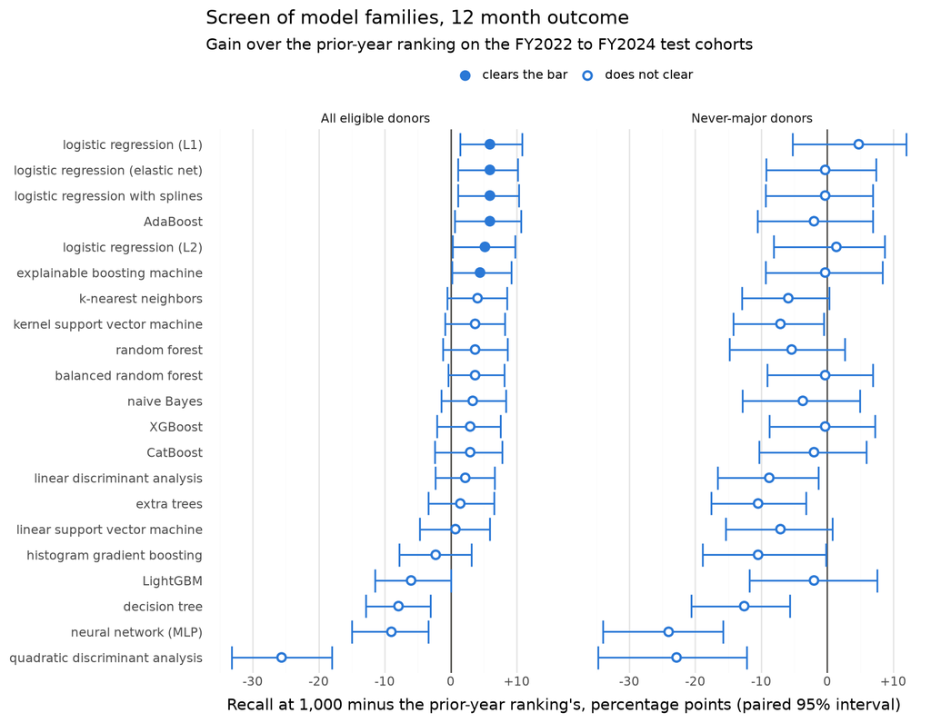

```python
# paired gain over the prior-year ranking, the comparison the 95% rule is applied to
plot_order = screen_table.sort("recall_all")["model"].to_list()
plot_df = (
    screen_diffs.filter(pl.col("group").is_in(["all eligible", "never major"]) & (pl.col("versus") == "prior-year giving"))
    .with_columns(
        pl.col("difference", "low", "high") * 100,
        result=pl.when(pl.col("low") > 0).then(pl.lit("clears the bar")).otherwise(pl.lit("does not clear")),
        group=pl.col("group").replace({"all eligible": "All eligible donors", "never major": "Never-major donors"}),
    )
    .to_pandas()
)
plot_df["model"] = pd.Categorical(plot_df["model"], categories=plot_order, ordered=True)

(
    ggplot(plot_df, aes("difference", "model"))
    + geom_vline(xintercept=0, color="#52514e", size=0.6)
    + geom_errorbarh(aes(xmin="low", xmax="high"), height=0, color="#2a78d6", size=0.7)
    + geom_point(aes(fill="result"), color="#2a78d6", size=2.4, stroke=0.9)
    + facet_wrap("group", ncol=2)
    + scale_fill_manual(values={"clears the bar": "#2a78d6", "does not clear": "white"})
    + scale_x_continuous(breaks=[-30, -20, -10, 0, 10, 20], labels=lambda xs: [f"{x:+.0f}" if x else "0" for x in xs])
    + labs(x="Recall at 1,000 minus the prior-year ranking's, percentage points (paired 95% interval)", y="", fill="",
           title="Screen of model families, 12 month outcome",
           subtitle="Gain over the prior-year ranking on the FY2022 to FY2024 test cohorts")
    + theme(legend_position="top", panel_grid_major_y=element_blank(), panel_spacing_x=0.04, figure_size=(9, 7))
)
```

```python
screen_timing = pl.concat([run[1] for run in screen_runs.values()], how="diagonal_relaxed")
timing_table = (
    screen_timing.group_by("model", maintain_order=True)
    .agg(total_minutes=((pl.col("tuning_seconds") + pl.col("fit_seconds") + pl.col("predict_seconds")).sum() / 60),
         final_fit_seconds=pl.col("fit_seconds").mean(), predict_seconds=pl.col("predict_seconds").mean(),
         setting_FY2022=pl.col("chosen_params").get(0), setting_FY2023=pl.col("chosen_params").get(1),
         setting_FY2024=pl.col("chosen_params").get(2))
    .with_columns(pl.col("total_minutes").round(1), pl.col("final_fit_seconds", "predict_seconds").round(2))
)
tt_ = {r["model"]: r for r in timing_table.iter_rows(named=True)}
show(timing_table, caption="Run time of the screen (tuning and final fits over the three test cohorts) and the setting tuning chose for each test cohort")
```

Table 15: Run time of the screen (tuning and final fits over the three test cohorts) and the setting tuning chose for each test cohort

| Model | Total minutes | Final fit seconds | Predict seconds | Setting FY2022 | Setting FY2023 | Setting FY2024 |
| --- | --- | --- | --- | --- | --- | --- |
| logistic regression (L2) | 2.70 | 0.46 | 0.04 | {'C': 0.01, 'class_weight': None} | {'C': 0.01, 'class_weight': None} | {'C': 0.01, 'class_weight': None} |
| logistic regression (L1) | 23.10 | 27.16 | 0.05 | {'C': 0.1} | {'C': 0.1} | {'C': 0.1} |
| logistic regression (elastic net) | 24.70 | 18.40 | 0.05 | {'C': 0.1} | {'C': 0.1} | {'C': 0.01} |
| logistic regression with splines | 1.50 | 0.98 | 0.10 | {'C': 0.01} | {'C': 1.0} | {'C': 0.1} |
| linear discriminant analysis | 0.80 | 0.39 | 0.05 | {'shrinkage': None} | {'shrinkage': None} | {'shrinkage': None} |
| quadratic discriminant analysis | 1.20 | 0.40 | 0.09 | {'shrinkage': 'auto'} | {'shrinkage': 0.9} | {'shrinkage': 'auto'} |
| naive Bayes | 1.10 | 0.36 | 0.08 | {'var_smoothing': 0.001} | {'var_smoothing': 0.001} | {'var_smoothing': 0.001} |
| k-nearest neighbors | 1.20 | 0.03 | 0.89 | {'n_neighbors': 100} | {'n_neighbors': 300} | {'n_neighbors': 25} |
| linear support vector machine | 4.10 | 1.00 | 0.05 | {'C': 0.01, 'class_weight': None} | {'C': 1.0, 'class_weight': None} | {'C': 0.01, 'class_weight': None} |
| kernel support vector machine | 2.10 | 0.61 | 4.68 | {'C': 0.1, 'class_weight': 'balanced'} | {'C': 0.1, 'class_weight': 'balanced'} | {'C': 0.1, 'class_weight': 'balanced'} |
| decision tree | 2.20 | 0.35 | 0.00 | {'max_depth': 3, 'class_weight': 'balanced'} | {'max_depth': 8, 'class_weight': 'balanced'} | {'max_depth': 5, 'class_weight': None} |
| random forest | 5.50 | 5.80 | 0.14 | {'min_samples_leaf': 50, 'class_weight': None} | {'min_samples_leaf': 10, 'class_weight': 'balanced_subsample'} | {'min_samples_leaf': 50, 'class_weight': None} |
| extra trees | 5.80 | 6.53 | 0.15 | {'min_samples_leaf': 10, 'class_weight': None} | {'min_samples_leaf': 10, 'class_weight': 'balanced_subsample'} | {'min_samples_leaf': 10, 'class_weight': 'balanced_subsample'} |
| balanced random forest | 2.20 | 1.87 | 0.12 | {'min_samples_leaf': 10} | {'min_samples_leaf': 1} | {'min_samples_leaf': 50} |
| LightGBM | 2.00 | 0.67 | 0.17 | {'num_leaves': 31, 'scale_pos_weight': 1} | {'num_leaves': 7, 'scale_pos_weight': 1} | {'num_leaves': 7, 'scale_pos_weight': 1} |
| histogram gradient boosting | 4.20 | 3.49 | 0.11 | {'max_leaf_nodes': 7, 'class_weight': 'balanced'} | {'max_leaf_nodes': 7, 'class_weight': 'balanced'} | {'max_leaf_nodes': 7, 'class_weight': 'balanced'} |
| XGBoost | 2.40 | 1.10 | 0.04 | {'max_depth': 3, 'scale_pos_weight': 1} | {'max_depth': 3, 'scale_pos_weight': 1} | {'max_depth': 3, 'scale_pos_weight': 1} |
| CatBoost | 6.30 | 5.58 | 0.01 | {'depth': 6, 'scale_pos_weight': 10} | {'depth': 6, 'scale_pos_weight': 1} | {'depth': 4, 'scale_pos_weight': 1} |
| AdaBoost | 15.40 | 5.07 | 0.29 | {'n_estimators': 50} | {'n_estimators': 50} | {'n_estimators': 50} |
| explainable boosting machine | 7.50 | 19.03 | 0.01 | {'interactions': 10} | {'interactions': 10} | {'interactions': 10} |
| neural network (MLP) | 3.70 | 4.18 | 0.06 | {'hidden_layer_sizes': (32,), 'alpha': 0.0001} | {'hidden_layer_sizes': (64, 32), 'alpha': 0.0001} | {'hidden_layer_sizes': (64, 32), 'alpha': 0.01} |

The screen gives a clear answer for all eligible donors and a weak one for never-major donors.

**All eligible donors.** 6 of the 21 models beat the prior-year ranking under the 95% paired rule: logistic regression (L2), logistic regression (L1), logistic regression (elastic net), logistic regression with splines, AdaBoost, explainable boosting machine. The best reach 81.3% recall at 1,000 against 75.4% for the ranking, a gain of 5.9 points (95% interval 1.4 to 10.8) for the L1 logistic regression. All of them also clear the former major or $500 rule. On the test cohorts that is about 8 more of the 134 converters on the lists over three years. The gain is larger on the no-contact pool (82.5% against 72.2%), but that pool rests on far fewer converters and its paired interval just reaches zero.

**Never-major donors.** No model clears the bar. The L1 logistic regression comes closest at 64.4% against 59.6%, a gain of 4.8 points with an interval from -5.2 to 12.0. Most models do worse than the ranking for these donors. With 59 never-major converters across the three test cohorts, the screen cannot separate a small real gain from noise here, and some of the models’ gain for all donors comes from ranking former major donors better.

**Average precision.** The best models nearly triple the prior-year ranking’s average precision (0.23 against 0.08), a much larger relative gain than in recall at 1,000. Average precision rewards placing converters near the very top of the list, and the prior-year ranking already reaches most converters by position 1,000, just not as early. A model that puts likely converters in the first hundred names is more useful to an officer working down the list, even when recall at 1,000 moves less.

**What does not work.** The flexible tree models do worst relative to their reputation. LightGBM falls below the bar (69.4%), and histogram gradient boosting, the single decision tree, the neural network, and quadratic discriminant analysis also land below the prior-year ranking. XGBoost and CatBoost sit just above it but do not clear it. With only 55 to 145 converters in the training cohorts, models that can carve the data into many small regions fit noise, and the tuning sometimes chose the larger trees (see the settings table). The strongest signals, prior-year giving and former major status, act in a steady, mostly one-directional way, which suits penalized linear models. The two models trained on a 10% sample of non-converters, k-nearest neighbors and the kernel support vector machine, land in the middle of the pack (79.5% and 79.1%) without clearing the bar.

**Run time.** Most models took a few minutes for the whole screen. The L1 and elastic net logistic regressions took 23 and 25 minutes because of the solver they need, while the L2 version took 3 minutes for nearly the same recall. AdaBoost took 15 minutes. Once fit, every model scores a cohort of 33,000 donors in a few seconds or less.

A caution applies to the whole table. With 21 models compared on the same 134 converters, the top of the ranking is partly luck, which is why the shortlist below carries families forward rather than a single winner, and why the FY2025 check comes only after the final choice. Still, the result does not hinge on one model: four different logistic regressions, AdaBoost, and the explainable boosting machine all land between 79.9% and 81.3%.

### 4.5 Shortlist

Four models move on to feature engineering, the training window comparison, and full tuning:

The elastic net and spline versions of logistic regression match the L1 version for all donors and do worse for never-major donors, so they add nothing. AdaBoost ties the leaders for all donors, but it is slower, weaker for never-major donors, and an additive boosted model like the explainable boosting machine without that model’s interpretability. The other models do not clear the bar.

### 4.6 Feature Engineering

The screen used every feature. This step asks which groups of features actually help, by refitting the four shortlisted models on nested feature sets and comparing them on the same resamples:

| Feature set | What it contains |
| --- | --- |
| Group EDA use list | The group EDA’s “use” features and the two contact flags for training |
| Use + test | Adds the features the group EDA expected to add little: recency, upgrade and additional gifts, soft credits in FY t, solicitation, Passport, state, and spouse on file |
| Use + engineered | Adds the engineered features from the Data Preparation section instead |
| All | Everything, the screen’s feature set |
| All without solicitation and Passport | Everything except the engagement features, which only exist from FY2021 |

The comparisons answer three questions. Do the engineered features help (use + engineered against the use list)? Do the group EDA’s “test” features help (use + test against the use list)? And do solicitation and Passport add anything once everything else is known (all against all without them)? The last question is one the business problem asks directly. Constituent type is tried once, added to the full set for the L2 logistic regression, as the sensitivity check the team agreed on.

```python
def by_status(*statuses):
    return [f for f, (_, status, _) in FEATURES.items() if status in statuses]

ENGAGEMENT = [f for f, (group, _, _) in FEATURES.items() if group in ("solicitation", "Passport")]
ALL_FEATURES = by_status("use", "test", "engineered", "training only")
assert ALL_FEATURES == SCREEN_FEATURES   # same list and order, so the screen's fits are reused from the cache
FEATURE_SETS = {
    "group EDA use list": by_status("use", "training only"),
    "use + test": by_status("use", "test", "training only"),
    "use + engineered": by_status("use", "engineered", "training only"),
    "all": ALL_FEATURES,
    "all without solicitation and Passport": [f for f in ALL_FEATURES if f not in ENGAGEMENT],
}

screen_by_name = {s["name"]: s for s in SCREEN}
SHORTLIST = {
    "logistic regression (L2)": screen_by_name["logistic regression (L2)"],
    "logistic regression (L1)": screen_spec("logistic regression (L1)", "linear",
                                            LogisticRegression(solver="liblinear", l1_ratio=1.0, max_iter=2000), True,
                                            product(C=[0.01, 0.1, 1.0])),
    "explainable boosting machine": screen_by_name["explainable boosting machine"],
    "XGBoost": screen_by_name["XGBoost"],
}

feature_runs = {
    (m, fs): cached_nested({**spec, "features": feats}, spec["grid"])
    for m, spec in SHORTLIST.items() for fs, feats in FEATURE_SETS.items()
}
# sensitivity check: constituent type added to the full set, for the L2 logistic regression only
l2 = SHORTLIST["logistic regression (L2)"]
feature_runs[("logistic regression (L2)", "all + constituent type")] = cached_nested(
    {**l2, "features": [*ALL_FEATURES, "type_group"]}, l2["grid"])
```

```python
fs_preds = {f"{m} | {fs}": run[0] for (m, fs), run in feature_runs.items()}
fs_summary, fs_bar_diffs, fs_boots = evaluate_models(fs_preds)

fs_with = test_scored
for name, p in fs_preds.items():
    fs_with = fs_with.join(p.rename({"score": f"score__{name}"}), on=["constituent_id", "t"], how="left")

def fs_row(g, name):
    return fs_summary.filter((pl.col("group") == g) & (pl.col("ranking") == name)).row(0, named=True)

fs_table = pl.DataFrame([
    {"model": m, "feature_set": fs,
     "features": len(FEATURE_SETS[fs]) if fs in FEATURE_SETS else len(ALL_FEATURES) + 1,
     "recall_all": fs_row("all eligible", f"{m} | {fs}")["recall"],
     "recall_never_major": fs_row("never major", f"{m} | {fs}")["recall"],
     "recall_no_contact": fs_row("no contact", f"{m} | {fs}")["recall"],
     "test_average_precision": test_average_precision(f"score__{m} | {fs}", fs_with)}
    for (m, fs) in feature_runs
])
ft = {(r["model"], r["feature_set"]): r for r in fs_table.iter_rows(named=True)}
fd = {(r["group"], r["model"]): r for r in fs_bar_diffs.filter(pl.col("versus") == "prior-year giving").iter_rows(named=True)}
show(fs_table.with_columns(pl.col("test_average_precision").round(3)),
     pct_cols=["recall_all", "recall_never_major", "recall_no_contact"],
     caption="Shortlisted models on each feature set: recall at 1,000 on the FY2022 to FY2024 test cohorts")
```

Table 16: Shortlisted models on each feature set: recall at 1,000 on the FY2022 to FY2024 test cohorts

| Model | Feature set | Features | Recall all | Recall never major | Recall no contact | Test average precision |
| --- | --- | --- | --- | --- | --- | --- |
| logistic regression (L2) | group EDA use list | 18 | 82.1% | 61.0% | 81.3% | 0.25 |
| logistic regression (L2) | use + test | 36 | 80.6% | 57.6% | 80.1% | 0.21 |
| logistic regression (L2) | use + engineered | 29 | 81.3% | 62.7% | 76.6% | 0.25 |
| logistic regression (L2) | all | 47 | 80.6% | 61.0% | 82.5% | 0.23 |
| logistic regression (L2) | all without solicitation and Passport | 35 | 81.3% | 62.7% | 82.5% | 0.22 |
| logistic regression (L1) | group EDA use list | 18 | 83.6% | 64.4% | 82.5% | 0.24 |
| logistic regression (L1) | use + test | 36 | 79.9% | 62.7% | 81.3% | 0.22 |
| logistic regression (L1) | use + engineered | 29 | 82.1% | 64.4% | 81.3% | 0.25 |
| logistic regression (L1) | all | 47 | 81.3% | 62.7% | 82.5% | 0.23 |
| logistic regression (L1) | all without solicitation and Passport | 35 | 82.1% | 61.0% | 82.5% | 0.23 |
| explainable boosting machine | group EDA use list | 18 | 82.1% | 61.0% | 80.1% | 0.23 |
| explainable boosting machine | use + test | 36 | 80.6% | 59.3% | 81.3% | 0.23 |
| explainable boosting machine | use + engineered | 29 | 81.3% | 61.0% | 80.1% | 0.26 |
| explainable boosting machine | all | 47 | 79.9% | 59.3% | 80.1% | 0.23 |
| explainable boosting machine | all without solicitation and Passport | 35 | 79.9% | 61.0% | 80.1% | 0.26 |
| XGBoost | group EDA use list | 18 | 75.4% | 54.2% | 74.2% | 0.17 |
| XGBoost | use + test | 36 | 80.6% | 61.0% | 81.3% | 0.19 |
| XGBoost | use + engineered | 29 | 77.6% | 55.9% | 76.6% | 0.19 |
| XGBoost | all | 47 | 78.4% | 59.3% | 77.7% | 0.20 |
| XGBoost | all without solicitation and Passport | 35 | 77.6% | 57.6% | 75.4% | 0.21 |
| logistic regression (L2) | all + constituent type | 48 | 80.6% | 61.0% | 82.5% | 0.23 |

```python
# each question is a paired difference between two feature sets of the same model
QUESTIONS = {
    "engineered features": ("use + engineered", "group EDA use list"),
    "group EDA test features": ("use + test", "group EDA use list"),
    "solicitation and Passport": ("all", "all without solicitation and Passport"),
    "everything beyond the use list": ("all", "group EDA use list"),
}
effect_rows = []
for m in SHORTLIST:
    for q, (a, b) in QUESTIONS.items():
        row = {"model": m, "question": q}
        for g, label in (("all eligible", "all"), ("never major", "never_major")):
            diff = paired_difference(fs_boots[g], f"{m} | {a}", f"{m} | {b}")
            row |= {f"{label}_gain": 100 * diff["difference"], f"{label}_low": 100 * diff["low"],
                    f"{label}_high": 100 * diff["high"]}
        effect_rows.append(row)
sens = paired_difference(fs_boots["all eligible"], "logistic regression (L2) | all + constituent type",
                         "logistic regression (L2) | all")
effect_rows.append({"model": "logistic regression (L2)", "question": "constituent type (sensitivity)",
                    "all_gain": 100 * sens["difference"], "all_low": 100 * sens["low"], "all_high": 100 * sens["high"]})
effects = pl.DataFrame(effect_rows)
ef_ = {(r["model"], r["question"]): r for r in effects.iter_rows(named=True)}
show(effects.with_columns(pl.exclude("model", "question").round(1)),
     caption="What each feature group adds: paired gain in recall at 1,000, percentage points, with 95% intervals")
```

Table 17: What each feature group adds: paired gain in recall at 1,000, percentage points, with 95% intervals

| Model | Question | All gain | All low | All high | Never major gain | Never major low | Never major high |
| --- | --- | --- | --- | --- | --- | --- | --- |
| logistic regression (L2) | engineered features | -0.70 | -4.20 | 2.40 | 1.70 | -6.20 | 7.50 |
| logistic regression (L2) | group EDA test features | -1.50 | -4.40 | 1.50 | -3.40 | -9.60 | 2.80 |
| logistic regression (L2) | solicitation and Passport | -0.70 | -3.30 | 1.60 | -1.70 | -5.50 | 0.00 |
| logistic regression (L2) | everything beyond the use list | -1.50 | -5.50 | 2.30 | 0.00 | -7.00 | 6.20 |
| logistic regression (L1) | engineered features | -1.50 | -4.10 | 0.00 | 0.00 | 0.00 | 0.00 |
| logistic regression (L1) | group EDA test features | -3.70 | -7.20 | -0.80 | -1.70 | -7.40 | 3.50 |
| logistic regression (L1) | solicitation and Passport | -0.70 | -2.50 | 0.00 | 1.70 | 0.00 | 5.30 |
| logistic regression (L1) | everything beyond the use list | -2.20 | -5.40 | 0.00 | -1.70 | -7.70 | 4.10 |
| explainable boosting machine | engineered features | -0.70 | -3.00 | 1.50 | 0.00 | 0.00 | 5.60 |
| explainable boosting machine | group EDA test features | -1.50 | -5.70 | 0.90 | -1.70 | -9.20 | 3.40 |
| explainable boosting machine | solicitation and Passport | 0.00 | -2.50 | 2.50 | -1.70 | -10.20 | 7.60 |
| explainable boosting machine | everything beyond the use list | -2.20 | -5.20 | 0.00 | -1.70 | -9.30 | 7.30 |
| XGBoost | engineered features | 2.20 | -1.60 | 5.90 | 1.70 | -5.80 | 10.00 |
| XGBoost | group EDA test features | 5.20 | 0.00 | 9.90 | 6.80 | 0.00 | 15.10 |
| XGBoost | solicitation and Passport | 0.70 | -2.60 | 4.10 | 1.70 | -5.20 | 7.90 |
| XGBoost | everything beyond the use list | 3.00 | -1.60 | 7.60 | 5.10 | -3.60 | 13.20 |
| logistic regression (L2) | constituent type (sensitivity) | 0.00 | 0.00 | 0.90 |  |  |  |

```python
linear_ebm = ["logistic regression (L2)", "logistic regression (L1)", "explainable boosting machine"]
main_qs = ["engineered features", "group EDA test features", "solicitation and Passport", "everything beyond the use list"]
le_gains = [ef_[(m, q)]["all_gain"] for m in linear_ebm for q in main_qs]
le_excluding_zero = [(m, q) for m in linear_ebm for q in main_qs if ef_[(m, q)]["all_high"] < 0 or ef_[(m, q)]["all_low"] > 0]
engagement = [ef_[(m, "solicitation and Passport")] for m in SHORTLIST]
l1_use = fd[("all eligible", "logistic regression (L1) | group EDA use list")]
ap_use = {m: ft[(m, "group EDA use list")]["test_average_precision"] for m in SHORTLIST}
ap_eng = {m: ft[(m, "use + engineered")]["test_average_precision"] for m in SHORTLIST}
assert all(ap_eng[m] > ap_use[m] for m in SHORTLIST)   # the engineered features raise average precision for every model
best_never = max(fs_table.iter_rows(named=True), key=lambda r: r["recall_never_major"])
```

**Fewer features do as well or better.** For the two logistic regressions and the explainable boosting machine, the smallest set, the group EDA’s use list with 18 inputs, matches or beats every larger set. The L1 logistic regression on the use list reaches 83.6% recall at 1,000, 8.2 points above the prior-year ranking (95% interval 3.5 to 13.2), the best result so far. For these three models, adding feature groups changes recall by between -3.7 and 0 points, and only 1 of the 12 paired intervals excludes zero: the group EDA’s “test” features lower the L1 model’s recall by 3.7 points (-7.2 to -0.8). With few converters to learn from, each extra feature is another chance to fit noise, and the penalized models and the boosting machine do best when the inputs are the ones the EDA already found useful.

**Solicitation and Passport add nothing.** Removing them changes recall by between -0.7 and +0.7 points across the four models, and every interval includes zero, for all eligible donors and for never-major donors. This answers the business problem’s question about engagement and viewing: once giving history is known, they do not help find future major donors, which matches the group EDA’s within-band results.

**The engineered features help a little, near the top of the list.** They do not raise recall at 1,000 for the linear models or the boosting machine, but they raise average precision for all four models, for example from 0.226 to 0.261 for the explainable boosting machine. They move some converters higher within the list without adding converters to it.

**XGBoost is the exception.** It is the only model that gains from more inputs: the group EDA’s “test” features raise its recall by 5.2 points (0.0 to 9.9), and on the use list alone it does no better than the prior-year ranking (75.4%). A flexible tree model needs varied inputs to split on, while the linear models get most of their signal from a few monotone features. Even XGBoost’s best set (80.6%) stays below the best linear models.

**Constituent type** changes the L2 model’s recall by 0.0 points (0.0 to 0.9), so leaving it out of the main model, as the team agreed, costs nothing.

**Never-major donors.** No model and feature set clears the bar. The best is logistic regression (L1) on the group EDA use list set at 64.4%, against 59.6% for the ranking.

A caution: choosing a feature set by its result on the test cohorts is itself part of model selection, so the winning set’s advantage is probably a little overstated. The differences between sets are small next to their intervals, so the safer reading is that the extra features neither help nor hurt much, and the simplest set does as well as any. The FY2025 check at the end remains the honest test of whatever is chosen.

From here on, the two logistic regressions and the explainable boosting machine use the group EDA’s use list, the smallest set and the best or tied for best for each of them. XGBoost keeps the use + test set, since it is the one model that gains from the extra inputs. The use + engineered set remains the alternative if placing converters near the very top of the list turns out to matter more than recall at 1,000.

### 4.7 Training Window

So far every model has trained on the FY2021 cohort onward, which gives the FY2022 test only 55 converters to learn from and the FY2024 test 145. The legacy-era cohorts add hundreds more, and the chosen feature sets are almost entirely giving history, which exists in every era. The open question is whether older donors behave enough like recent ones for their outcomes to help. The sustainer share was much lower before FY2014, and the legacy system recorded sustainers’ payments differently, so older years could also mislead a model.

Three training windows are compared, each ending in the cohort before the test cohort:

- **FY2021 onward**, the window used so far.
- **FY2014 onward**, roughly when sustaining took off (the sustainer share rose from about a quarter of donors to more than half over the following years), so donors look more like today’s.
- **FY1999 onward**, all of the complete legacy history.

Everything else stays fixed: the four shortlisted models with their chosen feature sets, nested tuning, and the FY2022 to FY2024 test cohorts. Features that do not exist in older cohorts (soft credits before FY t, and the engagement features in XGBoost’s set) are missing there, as set up in the Data Preparation section.

Before running the comparison I set a rule for one follow-up, so that the results would not decide whether to look further. If the FY1999 window helps across the board, it is used as it is. If it hurts across the board, the better of the shorter windows is used. If the results are mixed, meaning the long window helps for some groups or models and hurts for others, or the FY2014 window beats both, then older years carry signal but have drifted, and a version of the FY1999 window that weights recent cohorts more heavily is tested as well.

```python
CHOSEN_SETS = {"logistic regression (L2)": "group EDA use list", "logistic regression (L1)": "group EDA use list",
               "explainable boosting machine": "group EDA use list", "XGBoost": "use + test"}
WINDOWS = {"FY2021 onward": 2021, "FY2014 onward": 2014, "FY1999 onward": 1999}

def chosen_spec(m, train_start=2021):
    return {**SHORTLIST[m], "features": FEATURE_SETS[CHOSEN_SETS[m]], "train_start": train_start}

window_runs = {
    (m, w): cached_nested(chosen_spec(m, start), SHORTLIST[m]["grid"])
    for m in SHORTLIST for w, start in WINDOWS.items()
}
```

```python
win_preds = {f"{m} | {w}": run[0] for (m, w), run in window_runs.items()}
win_summary, win_bar_diffs, win_boots = evaluate_models(win_preds)
win_with = test_scored
for name, p in win_preds.items():
    win_with = win_with.join(p.rename({"score": f"score__{name}"}), on=["constituent_id", "t"], how="left")

def win_row(g, name):
    return win_summary.filter((pl.col("group") == g) & (pl.col("ranking") == name)).row(0, named=True)

win_table = pl.DataFrame([
    {"model": m, "window": w,
     "training_converters_FY2024_test": int(run[1].filter(pl.col("test_cohort") == 2024)["training_converters"][0]),
     "recall_all": win_row("all eligible", f"{m} | {w}")["recall"],
     "recall_never_major": win_row("never major", f"{m} | {w}")["recall"],
     "recall_no_contact": win_row("no contact", f"{m} | {w}")["recall"],
     "test_average_precision": test_average_precision(f"score__{m} | {w}", win_with),
     "total_minutes": float((run[1]["tuning_seconds"] + run[1]["fit_seconds"] + run[1]["predict_seconds"]).sum() / 60)}
    for (m, w), run in window_runs.items()
])
wt = {(r["model"], r["window"]): r for r in win_table.iter_rows(named=True)}
show(win_table.with_columns(pl.col("test_average_precision").round(3), pl.col("total_minutes").round(1)),
     pct_cols=["recall_all", "recall_never_major", "recall_no_contact"],
     caption="Shortlisted models trained on three windows: recall at 1,000 on the FY2022 to FY2024 test cohorts")
```

Table 18: Shortlisted models trained on three windows: recall at 1,000 on the FY2022 to FY2024 test cohorts

| Model | Window | Training converters FY2024 test | Recall all | Recall never major | Recall no contact | Test average precision | Total minutes |
| --- | --- | --- | --- | --- | --- | --- | --- |
| logistic regression (L2) | FY2021 onward | 145 | 82.1% | 61.0% | 81.3% | 0.25 | 2.10 |
| logistic regression (L2) | FY2014 onward | 421 | 82.8% | 64.4% | 82.5% | 0.26 | 10.70 |
| logistic regression (L2) | FY1999 onward | 667 | 82.1% | 64.4% | 81.3% | 0.24 | 18.30 |
| logistic regression (L1) | FY2021 onward | 145 | 83.6% | 64.4% | 82.5% | 0.24 | 1.90 |
| logistic regression (L1) | FY2014 onward | 421 | 82.8% | 64.4% | 82.5% | 0.27 | 20.70 |
| logistic regression (L1) | FY1999 onward | 667 | 82.1% | 61.0% | 82.5% | 0.27 | 58.70 |
| explainable boosting machine | FY2021 onward | 145 | 82.1% | 61.0% | 80.1% | 0.23 | 3.80 |
| explainable boosting machine | FY2014 onward | 421 | 81.3% | 64.4% | 80.1% | 0.24 | 14.20 |
| explainable boosting machine | FY1999 onward | 667 | 82.1% | 62.7% | 82.5% | 0.25 | 39.10 |
| XGBoost | FY2021 onward | 145 | 80.6% | 61.0% | 81.3% | 0.19 | 2.20 |
| XGBoost | FY2014 onward | 421 | 82.8% | 66.1% | 82.5% | 0.20 | 4.80 |
| XGBoost | FY1999 onward | 667 | 81.3% | 66.1% | 80.1% | 0.23 | 8.20 |

```python
WINDOW_PAIRS = [("FY2014 onward", "FY2021 onward"), ("FY1999 onward", "FY2021 onward"), ("FY1999 onward", "FY2014 onward")]
win_effect_rows = []
for m in SHORTLIST:
    for a, b in WINDOW_PAIRS:
        row = {"model": m, "comparison": f"{a} minus {b}"}
        for g, label in (("all eligible", "all"), ("never major", "never_major")):
            diff = paired_difference(win_boots[g], f"{m} | {a}", f"{m} | {b}")
            row |= {f"{label}_gain": 100 * diff["difference"], f"{label}_low": 100 * diff["low"],
                    f"{label}_high": 100 * diff["high"]}
        win_effect_rows.append(row)
win_effects = pl.DataFrame(win_effect_rows)
we = {(r["model"], r["comparison"]): r for r in win_effects.iter_rows(named=True)}
show(win_effects.with_columns(pl.exclude("model", "comparison").round(1)),
     caption="Paired differences between training windows in recall at 1,000, percentage points, with 95% intervals")
```

Table 19: Paired differences between training windows in recall at 1,000, percentage points, with 95% intervals

| Model | Comparison | All gain | All low | All high | Never major gain | Never major low | Never major high |
| --- | --- | --- | --- | --- | --- | --- | --- |
| logistic regression (L2) | FY2014 onward minus FY2021 onward | 0.70 | -2.30 | 3.80 | 3.40 | 0.00 | 9.20 |
| logistic regression (L2) | FY1999 onward minus FY2021 onward | 0.00 | -3.00 | 2.60 | 3.40 | -1.50 | 8.50 |
| logistic regression (L2) | FY1999 onward minus FY2014 onward | -0.70 | -3.90 | 1.70 | 0.00 | -4.20 | 0.00 |
| logistic regression (L1) | FY2014 onward minus FY2021 onward | -0.70 | -3.10 | 0.00 | 0.00 | -0.00 | 0.00 |
| logistic regression (L1) | FY1999 onward minus FY2021 onward | -1.50 | -4.40 | 0.00 | -3.40 | -8.80 | 0.00 |
| logistic regression (L1) | FY1999 onward minus FY2014 onward | -0.70 | -2.70 | 0.00 | -3.40 | -8.80 | 0.00 |
| explainable boosting machine | FY2014 onward minus FY2021 onward | -0.70 | -3.40 | 1.60 | 3.40 | -3.20 | 10.70 |
| explainable boosting machine | FY1999 onward minus FY2021 onward | 0.00 | -3.50 | 3.20 | 1.70 | -3.80 | 8.50 |
| explainable boosting machine | FY1999 onward minus FY2014 onward | 0.70 | -1.60 | 3.20 | -1.70 | -6.70 | 3.70 |
| XGBoost | FY2014 onward minus FY2021 onward | 2.20 | -1.40 | 6.80 | 5.10 | -1.80 | 12.70 |
| XGBoost | FY1999 onward minus FY2021 onward | 0.70 | -2.70 | 5.30 | 5.10 | -3.70 | 10.30 |
| XGBoost | FY1999 onward minus FY2014 onward | -1.50 | -4.00 | 0.70 | 0.00 | -9.50 | 4.50 |

```python
pair_2014 = "FY2014 onward minus FY2021 onward"
pair_1999 = "FY1999 onward minus FY2021 onward"
pair_99_14 = "FY1999 onward minus FY2014 onward"
def gain_range(pair, col):
    vals = [we[(m, pair)][col] for m in SHORTLIST]
    return min(vals), max(vals)
wd = {(r["group"], r["model"]): r for r in win_bar_diffs.filter(pl.col("versus") == "prior-year giving").iter_rows(named=True)}
all_clear = all(wd[("all eligible", f"{m} | {w}")]["low"] > 0 for m in SHORTLIST for w in WINDOWS)
never_2014_not_worse = all(wt[(m, "FY2014 onward")]["recall_never_major"] >= wt[(m, "FY2021 onward")]["recall_never_major"] for m in SHORTLIST)
ap_2014_higher = all(wt[(m, "FY2014 onward")]["test_average_precision"] > wt[(m, "FY2021 onward")]["test_average_precision"] for m in SHORTLIST)
assert all_clear and never_2014_not_worse and ap_2014_higher
extra_converters = wt[("logistic regression (L2)", "FY1999 onward")]["training_converters_FY2024_test"] - wt[("logistic regression (L2)", "FY2014 onward")]["training_converters_FY2024_test"]

def fmt_range(lo, hi):
    return f"{lo:.1f} to {hi:+.1f}" if hi > 0 else f"{lo:.1f} to 0"
```

**For all eligible donors the window makes little difference.** Moving from FY2021 onward to FY2014 onward changes recall by -0.7 to +2.2 points across the four models, and moving to FY1999 onward by -1.5 to +0.7, with every paired interval including zero. All twelve combinations of model and window still beat the prior-year ranking under the 95% rule.

**Longer windows lean toward helping never-major donors and the top of the list.** With FY2014 onward, never-major recall is the same as or higher than with FY2021 onward for all four models (0.0 to +5.1 points), and average precision is higher for all four. None of these never-major gains is clearly above zero, though. The largest interval lower bound is 0.0, and no model and window clears the never-major bar.

**Going back to FY1999 adds nothing beyond FY2014.** The extra fifteen years bring 246 more converters to the FY2024 training set, yet against FY2014 onward they change recall by -1.5 to +0.7 points for all eligible donors and -3.4 to 0 for never-major donors. They also make every model slower: the L1 logistic regression took 59 minutes on FY1999 onward against 21 on FY2014 onward.

**Applying the rule.** The rule set before the comparison assumed the long window would clearly help or clearly hurt. Instead no window measurably differs from another, and the point estimates point different ways: the FY1999 window raises never-major recall for three models and lowers it for the L1 logistic regression, and the FY2014 window beats both other windows for two of the models. Read as written, that is the mixed case, so the weighted FY1999 window is tested as the rule requires, even though the differences it would explain are within noise.

### 4.8 Weighting Recent Cohorts

The weighted version keeps all of FY1999 onward but counts recent cohorts more. Each training cohort’s weight halves every *h* years counting back from the most recent training cohort, so with *h* = 6 a cohort six years older counts half as much. The half-life *h* is chosen from 3, 6, and 12 years by inner cross-validation on each test cohort’s training data, like any other setting. To keep the run affordable, each model’s own settings are fixed at what the unweighted FY1999 run chose for that test cohort, which were themselves chosen by inner cross-validation on the same training data, so only the half-life is tuned here. The weights apply to fitting only; every validation and test donor counts equally.

```python
import ast

HALF_LIVES = [3, 6, 12]

def weighted_grid(m):
    # per test cohort: the settings the unweighted FY1999 run chose, crossed with each half-life
    chosen = window_runs[(m, "FY1999 onward")][1]
    return {int(r["test_cohort"]): [{**ast.literal_eval(r["chosen_params"]), "recency_half_life": h} for h in HALF_LIVES]
            for r in chosen.iter_rows(named=True)}

weighted_runs = {m: cached_nested(chosen_spec(m, 1999), [], grid_by_cohort=weighted_grid(m)) for m in SHORTLIST}
```

```python
wtd_preds = {**win_preds, **{f"{m} | FY1999 weighted": run[0] for m, run in weighted_runs.items()}}
wtd_summary, wtd_bar_diffs, wtd_boots = evaluate_models(wtd_preds)
wtd_with = win_with
for m, run in weighted_runs.items():
    wtd_with = wtd_with.join(run[0].rename({"score": f"score__{m} | FY1999 weighted"}), on=["constituent_id", "t"], how="left")

def wtd_row(g, name):
    return wtd_summary.filter((pl.col("group") == g) & (pl.col("ranking") == name)).row(0, named=True)

wtd_rows = []
for m, run in weighted_runs.items():
    name = f"{m} | FY1999 weighted"
    row = {"model": m,
           "half_life_by_test_cohort": " / ".join(str(ast.literal_eval(p)["recency_half_life"]) for p in run[1]["chosen_params"]),
           "recall_all": wtd_row("all eligible", name)["recall"],
           "recall_never_major": wtd_row("never major", name)["recall"],
           "test_average_precision": test_average_precision(f"score__{name}", wtd_with),
           "total_minutes": float((run[1]["tuning_seconds"] + run[1]["fit_seconds"] + run[1]["predict_seconds"]).sum() / 60)}
    for w in WINDOWS:
        for g, label in (("all eligible", "all"), ("never major", "never")):
            diff = paired_difference(wtd_boots[g], name, f"{m} | {w}")
            short = w.split()[0]
            row |= {f"{label}_vs_{short}": 100 * diff["difference"], f"{label}_vs_{short}_low": 100 * diff["low"],
                    f"{label}_vs_{short}_high": 100 * diff["high"]}
    wtd_rows.append(row)
wtd_table = pl.DataFrame(wtd_rows)
wr = {r["model"]: r for r in wtd_table.iter_rows(named=True)}
show(wtd_table.select("model", "half_life_by_test_cohort", "recall_all", "recall_never_major", "test_average_precision",
                      "total_minutes").with_columns(pl.col("test_average_precision").round(3), pl.col("total_minutes").round(1)),
     pct_cols=["recall_all", "recall_never_major"],
     caption="Recency-weighted FY1999 window: half-life chosen for each test cohort (FY2022 / FY2023 / FY2024) and recall at 1,000")
```

Table 20: Recency-weighted FY1999 window: half-life chosen for each test cohort (FY2022 / FY2023 / FY2024) and recall at 1,000

| Model | Half life by test cohort | Recall all | Recall never major | Test average precision | Total minutes |
| --- | --- | --- | --- | --- | --- |
| logistic regression (L2) | 12 / 6 / 6 | 82.8% | 66.1% | 0.25 | 3.90 |
| logistic regression (L1) | 12 / 12 / 6 | 82.1% | 62.7% | 0.27 | 19.60 |
| explainable boosting machine | 12 / 12 / 12 | 82.1% | 62.7% | 0.24 | 43.20 |
| XGBoost | 3 / 12 / 6 | 82.8% | 64.4% | 0.19 | 5.60 |

```python
wtd_effects = pl.DataFrame([
    {"model": m, "compared_with": w, "group": label,
     "gain": wr[m][f"{key}_vs_{w.split()[0]}"], "low": wr[m][f"{key}_vs_{w.split()[0]}_low"],
     "high": wr[m][f"{key}_vs_{w.split()[0]}_high"]}
    for m in SHORTLIST for w in WINDOWS for key, label in (("all", "all eligible"), ("never", "never major"))
])
wtd_excluding_zero = wtd_effects.filter((pl.col("low") > 0) | (pl.col("high") < 0))
show(wtd_effects.with_columns(pl.col("gain", "low", "high").round(1)),
     caption="Recency-weighted FY1999 window minus each unweighted window: paired difference in recall at 1,000, percentage points")
```

Table 21: Recency-weighted FY1999 window minus each unweighted window: paired difference in recall at 1,000, percentage points

| Model | Compared with | Group | Gain | Low | High |
| --- | --- | --- | --- | --- | --- |
| logistic regression (L2) | FY2021 onward | all eligible | 0.70 | -2.40 | 3.70 |
| logistic regression (L2) | FY2021 onward | never major | 5.10 | 0.00 | 10.90 |
| logistic regression (L2) | FY2014 onward | all eligible | 0.00 | -1.50 | 0.00 |
| logistic regression (L2) | FY2014 onward | never major | 1.70 | -3.10 | 5.00 |
| logistic regression (L2) | FY1999 onward | all eligible | 0.70 | -1.70 | 3.80 |
| logistic regression (L2) | FY1999 onward | never major | 1.70 | 0.00 | 5.40 |
| logistic regression (L1) | FY2021 onward | all eligible | -1.50 | -4.50 | 0.00 |
| logistic regression (L1) | FY2021 onward | never major | -1.70 | -7.30 | 3.30 |
| logistic regression (L1) | FY2014 onward | all eligible | -0.70 | -2.70 | 0.00 |
| logistic regression (L1) | FY2014 onward | never major | -1.70 | -7.20 | 3.20 |
| logistic regression (L1) | FY1999 onward | all eligible | 0.00 | 0.00 | 0.00 |
| logistic regression (L1) | FY1999 onward | never major | 1.70 | 0.00 | 7.10 |
| explainable boosting machine | FY2021 onward | all eligible | 0.00 | -3.10 | 2.80 |
| explainable boosting machine | FY2021 onward | never major | 1.70 | -3.80 | 9.40 |
| explainable boosting machine | FY2014 onward | all eligible | 0.70 | -1.40 | 3.10 |
| explainable boosting machine | FY2014 onward | never major | -1.70 | -5.70 | 3.70 |
| explainable boosting machine | FY1999 onward | all eligible | 0.00 | -2.40 | 2.20 |
| explainable boosting machine | FY1999 onward | never major | 0.00 | 0.00 | 3.40 |
| XGBoost | FY2021 onward | all eligible | 2.20 | -0.80 | 6.30 |
| XGBoost | FY2021 onward | never major | 3.40 | -2.40 | 11.10 |
| XGBoost | FY2014 onward | all eligible | 0.00 | -2.30 | 2.10 |
| XGBoost | FY2014 onward | never major | -1.70 | -5.70 | 0.00 |
| XGBoost | FY1999 onward | all eligible | 1.50 | -0.80 | 3.70 |
| XGBoost | FY1999 onward | never major | -1.70 | -4.90 | 6.60 |

```python
wtd_d = {(r["group"], r["model"]): r for r in wtd_bar_diffs.filter(pl.col("versus") == "prior-year giving").iter_rows(named=True)}
wtd_clear_all = all(wtd_d[("all eligible", f"{m} | FY1999 weighted")]["low"] > 0 for m in SHORTLIST)
wtd_clear_never = any(wtd_d[("never major", f"{m} | FY1999 weighted")]["low"] > 0 for m in SHORTLIST)
assert wtd_clear_all and not wtd_clear_never and wtd_excluding_zero.height == 0
wtd_recall = [wr[m]["recall_all"] for m in SHORTLIST]
wtd_never = [wr[m]["recall_never_major"] for m in SHORTLIST]
```

The weighted window does not change the picture. Tuning chose long half-lives more often than short ones (12 years for the explainable boosting machine in every test cohort), so the weighting it settled on is mild, and the results land close to the FY2014 window: 82.1% to 82.8% recall for all eligible donors and 62.7% to 66.1% for never-major donors. None of the 24 paired comparisons with the unweighted windows excludes zero, for either group. All four weighted models still beat the prior-year ranking for all eligible donors, and none clears it for never-major donors.

Taken together, the training window comparison finds no measurable effect in any direction. Adding older cohorts, with or without weighting, gives every model hundreds more converters to learn from without changing recall at 1,000 by more than the noise in 134 test converters. The most likely reason is that the strongest signals, prior-year giving and former major status, are already estimated well from the recent cohorts, and the older cohorts add more donors of the same kind rather than new information.

### 4.9 Hyperparameter Tuning

The screen and the experiments above used small grids. This step tunes the four shortlisted models properly, on the FY2014 window with each model’s chosen feature set, and uses the same runs to compare the four tuning measures.

[output not shown]

For each test cohort, every setting goes through the same grouped inner cross-validation, which records all four tuning measures. Each measure then picks its own best setting, and those picks are refit and scored on the test cohort. This shows whether the tuning measure changes the chosen setting, and whether that matters on the test cohorts.

Three rules were set before the runs:

1. **Tuning measure.** Average precision, used so far, stays the tuning measure unless another measure’s picks give higher recall at 1,000 with a paired 95% interval above zero. If no measure differs measurably, average precision stays.
2. **Full tuning carries forward.** The fully tuned version of each model is used from here on whatever its test result, because the tuning happens entirely inside the training cohorts. Accepting or rejecting it based on the test cohorts would itself be selecting on the test data. Its comparison with the lightly tuned FY2014 versions is reported for information only.
3. **All four models move on** to the final comparison, where the selection rule decides between them.

```python
def random_grid(options, n, seed=SEED):
    # n distinct settings drawn at random from the full grid of options
    full = product(**options)
    rng = np.random.default_rng(seed)
    return [full[i] for i in sorted(rng.choice(len(full), size=n, replace=False))]

TUNE_GRIDS = {
    "logistic regression (L2)": product(C=[0.001, 0.003, 0.01, 0.03, 0.1, 0.3, 1.0, 3.0], class_weight=BALANCED),
    "logistic regression (L1)": product(C=[0.003, 0.01, 0.03, 0.1, 0.3, 1.0], class_weight=BALANCED),
    "explainable boosting machine": product(interactions=[0, 5, 10], learning_rate=[0.005, 0.015], min_samples_leaf=[4, 50]),
    "XGBoost": random_grid({"max_depth": [2, 3, 4, 6], "learning_rate": [0.01, 0.03, 0.05, 0.1],
                            "n_estimators": [100, 300, 600], "min_child_weight": [1, 5, 20, 50],
                            "subsample": [0.6, 0.8, 1.0], "colsample_bytree": [0.5, 0.8, 1.0],
                            "reg_lambda": [1, 10, 50], "scale_pos_weight": [1, 10]}, n=30),
}
TUNE_START = 2014   # the training window chosen above

def pick(tbl, metric):
    # the grid setting a tuning measure prefers
    col = pl.col(metric).fill_nan(None)
    return tbl.sort(col, descending=TUNING_METRICS[metric] == "max", nulls_last=True)["params"][0]

def nested_multi(spec, grid, data=None, target="y_12m", window=1, test_cohorts=TEST_COHORTS):
    """Tune once per test cohort, then refit and score the setting each tuning measure picks.
    Returns {measure: (preds, timing)} and the tuning table."""
    data = frame if data is None else data
    out = {metric: ([], []) for metric in TUNING_METRICS}
    tuning = []
    for T in test_cohorts:
        train = data.filter(pl.col("t").is_between(spec["train_start"], T - window) & pl.col(target).is_not_null())
        start = perf_counter()
        tbl = tune(spec, grid, train, target=target).with_columns(test_cohort=pl.lit(T))
        tune_seconds = perf_counter() - start
        fitted = {}   # a setting picked by several measures is fit once
        for metric in TUNING_METRICS:
            best = pick(tbl, metric)
            if best not in fitted:
                model_params, run_params = split_params(grid[[str(g) for g in grid].index(best)])
                chosen = {**spec, **run_params, "model": clone(spec["model"]).set_params(**model_params)}
                fitted[best] = rolling_test(chosen, data, target, window, [T])
            p, tm = fitted[best]
            out[metric][0].append(p)
            out[metric][1].append(tm.with_columns(chosen_params=pl.lit(best), tuning_seconds=pl.lit(tune_seconds)))
        tuning.append(tbl)
    return {m: (pl.concat(p), pl.concat(tm)) for m, (p, tm) in out.items()}, pl.concat(tuning)

def cached_multi(spec, grid, **kw):
    """nested_multi, saved to disk like cached_nested."""
    key_parts = ["multi-measure", CACHE_VERSION, spec["name"], repr(spec["model"]), spec["scaled"], spec.get("splines"),
                 spec.get("subsample"), spec.get("drop_empty"), spec["features"], spec["train_start"],
                 [str(g) for g in grid], sorted((k, str(v)) for k, v in kw.items())]
    key = hashlib.sha1(json.dumps(key_parts, default=str).encode()).hexdigest()[:16]
    paths = {f"{m}_{part}": CACHE_DIR / f"{key}_{m}_{part}.parquet" for m in TUNING_METRICS for part in ("preds", "timing")}
    paths["tuning"] = CACHE_DIR / f"{key}_tuning.parquet"
    if not RERUN and all(p.exists() for p in paths.values()):
        return ({m: (pl.read_parquet(paths[f"{m}_preds"]), pl.read_parquet(paths[f"{m}_timing"])) for m in TUNING_METRICS},
                pl.read_parquet(paths["tuning"]))
    by_metric, tuning = nested_multi(spec, grid, **kw)
    CACHE_DIR.mkdir(exist_ok=True)
    for m, (p, tm) in by_metric.items():
        p.write_parquet(paths[f"{m}_preds"])
        tm.write_parquet(paths[f"{m}_timing"])
    tuning.write_parquet(paths["tuning"])
    return by_metric, tuning
```

```python
tuned_runs = {m: cached_multi(chosen_spec(m, TUNE_START), TUNE_GRIDS[m]) for m in SHORTLIST}
```

```python
MEASURE_LABELS = {"average_precision": "average precision", "roc_auc": "ROC AUC", "log_loss": "log loss",
                  "recall_top_3pct": "recall in top 3%"}
tune_preds = {f"{m} | tuned on {MEASURE_LABELS[k]}": by_metric[k][0]
              for m, (by_metric, _) in tuned_runs.items() for k in TUNING_METRICS}
tune_preds |= {f"{m} | light grid": window_runs[(m, "FY2014 onward")][0] for m in SHORTLIST}
tune_summary, tune_bar_diffs, tune_boots = evaluate_models(tune_preds)
tune_with = test_scored
for name, p in tune_preds.items():
    tune_with = tune_with.join(p.rename({"score": f"score__{name}"}), on=["constituent_id", "t"], how="left")

def tune_row(g, name):
    return tune_summary.filter((pl.col("group") == g) & (pl.col("ranking") == name)).row(0, named=True)

tune_rows = []
for m, (by_metric, tuning_tbl) in tuned_runs.items():
    ap_picks = by_metric["average_precision"][1]["chosen_params"].to_list()
    for k in TUNING_METRICS:
        name = f"{m} | tuned on {MEASURE_LABELS[k]}"
        picks = by_metric[k][1]["chosen_params"].to_list()
        row = {"model": m, "tuning_measure": MEASURE_LABELS[k],
               "same_pick_as_average_precision": f"{sum(a == b for a, b in zip(picks, ap_picks))} of 3",
               "recall_all": tune_row("all eligible", name)["recall"],
               "recall_never_major": tune_row("never major", name)["recall"],
               "recall_no_contact": tune_row("no contact", name)["recall"],
               "test_average_precision": test_average_precision(f"score__{name}", tune_with)}
        if k != "average_precision":
            for g, label in (("all eligible", "all"), ("never major", "never")):
                diff = paired_difference(tune_boots[g], name, f"{m} | tuned on average precision")
                row |= {f"{label}_vs_ap": 100 * diff["difference"], f"{label}_vs_ap_low": 100 * diff["low"],
                        f"{label}_vs_ap_high": 100 * diff["high"]}
        tune_rows.append(row)
tune_table = pl.DataFrame(tune_rows)
tr_ = {(r["model"], r["tuning_measure"]): r for r in tune_table.iter_rows(named=True)}
show(tune_table.select("model", "tuning_measure", "same_pick_as_average_precision", "recall_all", "recall_never_major",
                       "recall_no_contact", "test_average_precision").with_columns(pl.col("test_average_precision").round(3)),
     pct_cols=["recall_all", "recall_never_major", "recall_no_contact"],
     caption="Fully tuned models by tuning measure: recall at 1,000 on the FY2022 to FY2024 test cohorts")
```

Table 22: Fully tuned models by tuning measure: recall at 1,000 on the FY2022 to FY2024 test cohorts

| Model | Tuning measure | Same pick as average precision | Recall all | Recall never major | Recall no contact | Test average precision |
| --- | --- | --- | --- | --- | --- | --- |
| logistic regression (L2) | average precision | 3 of 3 | 82.8% | 64.4% | 82.5% | 0.27 |
| logistic regression (L2) | ROC AUC | 0 of 3 | 82.8% | 62.7% | 81.3% | 0.25 |
| logistic regression (L2) | log loss | 0 of 3 | 82.1% | 64.4% | 81.3% | 0.25 |
| logistic regression (L2) | recall in top 3% | 1 of 3 | 82.8% | 64.4% | 82.5% | 0.27 |
| logistic regression (L1) | average precision | 3 of 3 | 82.8% | 64.4% | 82.5% | 0.26 |
| logistic regression (L1) | ROC AUC | 0 of 3 | 82.8% | 66.1% | 82.5% | 0.27 |
| logistic regression (L1) | log loss | 0 of 3 | 82.8% | 66.1% | 82.5% | 0.27 |
| logistic regression (L1) | recall in top 3% | 0 of 3 | 82.8% | 64.4% | 82.5% | 0.28 |
| explainable boosting machine | average precision | 3 of 3 | 82.1% | 64.4% | 81.3% | 0.23 |
| explainable boosting machine | ROC AUC | 0 of 3 | 81.3% | 64.4% | 80.1% | 0.24 |
| explainable boosting machine | log loss | 0 of 3 | 81.3% | 62.7% | 80.1% | 0.23 |
| explainable boosting machine | recall in top 3% | 0 of 3 | 80.6% | 62.7% | 80.1% | 0.23 |
| XGBoost | average precision | 3 of 3 | 82.1% | 64.4% | 80.1% | 0.25 |
| XGBoost | ROC AUC | 1 of 3 | 82.1% | 61.0% | 77.7% | 0.26 |
| XGBoost | log loss | 1 of 3 | 82.8% | 62.7% | 77.7% | 0.26 |
| XGBoost | recall in top 3% | 0 of 3 | 82.8% | 66.1% | 81.3% | 0.26 |

```python
measure_effects = tune_table.filter(pl.col("tuning_measure") != "average precision").select(
    "model", "tuning_measure", *[c for c in tune_table.columns if "_vs_ap" in c])
# rule 1: another measure replaces average precision only if its recall gain over the average precision picks holds
measure_wins = measure_effects.filter(pl.col("all_vs_ap_low") > 0)
show(measure_effects.with_columns(pl.exclude("model", "tuning_measure").round(1)),
     caption="Each tuning measure's picks minus the average precision picks: paired difference in recall at 1,000, percentage points")
```

Table 23: Each tuning measure's picks minus the average precision picks: paired difference in recall at 1,000, percentage points

| Model | Tuning measure | All vs ap | All vs ap low | All vs ap high | Never vs ap | Never vs ap low | Never vs ap high |
| --- | --- | --- | --- | --- | --- | --- | --- |
| logistic regression (L2) | ROC AUC | 0.00 | -2.30 | 2.60 | -1.70 | -5.70 | 3.20 |
| logistic regression (L2) | log loss | -0.70 | -2.30 | 0.70 | 0.00 | -2.00 | 0.00 |
| logistic regression (L2) | recall in top 3% | 0.00 | -0.70 | 0.00 | 0.00 | 0.00 | 1.60 |
| logistic regression (L1) | ROC AUC | 0.00 | 0.00 | 0.00 | 1.70 | 0.00 | 5.80 |
| logistic regression (L1) | log loss | 0.00 | 0.00 | 0.00 | 1.70 | 0.00 | 5.80 |
| logistic regression (L1) | recall in top 3% | 0.00 | 0.00 | 0.00 | 0.00 | 0.00 | 0.00 |
| explainable boosting machine | ROC AUC | -0.70 | -2.40 | 0.00 | 0.00 | 0.00 | 3.20 |
| explainable boosting machine | log loss | -0.70 | -2.40 | 0.00 | -1.70 | -7.10 | 4.70 |
| explainable boosting machine | recall in top 3% | -1.50 | -3.70 | 0.00 | -1.70 | -6.80 | 4.30 |
| XGBoost | ROC AUC | 0.00 | -3.00 | 2.70 | -3.40 | -10.50 | 2.90 |
| XGBoost | log loss | 0.70 | -1.70 | 3.40 | -1.70 | -8.00 | 3.80 |
| XGBoost | recall in top 3% | 0.70 | 0.00 | 3.00 | 1.70 | -4.40 | 6.90 |

```python
# information only (rule 2): the fully tuned models against the light-grid FY2014 versions, and against the bar
full_vs_light = []
for m in SHORTLIST:
    row = {"model": m}
    for g, label in (("all eligible", "all"), ("never major", "never")):
        d_ = paired_difference(tune_boots[g], f"{m} | tuned on average precision", f"{m} | light grid")
        bar_ = paired_difference(tune_boots[g], f"{m} | tuned on average precision", "prior-year giving")
        row |= {f"{label}_recall": tune_row(g, f"{m} | tuned on average precision")["recall"],
                f"{label}_vs_light": 100 * d_["difference"], f"{label}_vs_light_low": 100 * d_["low"],
                f"{label}_vs_light_high": 100 * d_["high"],
                f"{label}_vs_prior_year": 100 * bar_["difference"], f"{label}_vs_prior_year_low": 100 * bar_["low"],
                f"{label}_vs_prior_year_high": 100 * bar_["high"]}
    full_vs_light.append(row)
full_vs_light = pl.DataFrame(full_vs_light)
fl = {r["model"]: r for r in full_vs_light.iter_rows(named=True)}
show(full_vs_light.with_columns(pl.col("^.*_vs_.*$").round(1)), pct_cols=["all_recall", "never_recall"],
     caption="Fully tuned models (average precision picks) against their light-grid versions and the prior-year ranking, percentage points")
```

Table 24: Fully tuned models (average precision picks) against their light-grid versions and the prior-year ranking, percentage points

| Model | All recall | All vs light | All vs light low | All vs light high | All vs prior year | All vs prior year low | All vs prior year high | Never recall | Never vs light | Never vs light low | Never vs light high | Never vs prior year | Never vs prior year low | Never vs prior year high |
| --- | --- | --- | --- | --- | --- | --- | --- | --- | --- | --- | --- | --- | --- | --- |
| logistic regression (L2) | 82.8% | 0.00 | 0.00 | 0.00 | 7.40 | 2.70 | 12.30 | 64.4% | 0.00 | 0.00 | 0.00 | 4.80 | -4.80 | 12.80 |
| logistic regression (L1) | 82.8% | 0.00 | 0.00 | 0.00 | 7.40 | 2.60 | 12.30 | 64.4% | 0.00 | 0.00 | 0.00 | 4.80 | -5.10 | 12.60 |
| explainable boosting machine | 82.1% | 0.70 | 0.00 | 2.60 | 6.70 | 1.90 | 11.40 | 64.4% | 0.00 | -3.20 | 0.00 | 4.80 | -3.50 | 12.20 |
| XGBoost | 82.1% | -0.70 | -3.70 | 1.60 | 6.70 | 2.20 | 11.10 | 64.4% | -1.70 | -8.20 | 3.70 | 4.80 | -3.40 | 12.50 |

```python
assert measure_wins.height == 0   # rule 1: average precision stays the tuning measure
same_picks = [int(r["same_pick_as_average_precision"][0]) for r in tune_rows if r["tuning_measure"] != "average precision"]
m_all = measure_effects["all_vs_ap"].to_list()
light_all = [fl[m]["all_vs_light"] for m in SHORTLIST]
tuned_all = [fl[m]["all_recall"] for m in SHORTLIST]
tuned_never = [fl[m]["never_recall"] for m in SHORTLIST]
tuned_gain = [fl[m]["all_vs_prior_year"] for m in SHORTLIST]
assert all(fl[m]["all_vs_prior_year_low"] > 0 for m in SHORTLIST)
assert not any(fl[m]["never_vs_prior_year_low"] > 0 for m in SHORTLIST)
xgb_picks = tuned_runs["XGBoost"][0]["average_precision"][1]["chosen_params"].to_list()
xgb_depths = [ast.literal_eval(p)["max_depth"] for p in xgb_picks]
xgb_ap_light = test_average_precision("score__XGBoost | light grid", tune_with)
```

**Full tuning changes little next to the light grids.** Against the lightly tuned FY2014 versions, the fully tuned models differ by -0.7 to +0.7 points of recall, with every interval including zero. Under the second rule the fully tuned versions carry forward anyway, since their settings were chosen without looking at the test cohorts.

**XGBoost responded to regularization.** Tuned on average precision it chose shallow trees of depth 3 or less in 2 of the 3 test cohorts (depths 2, 2, 6), and its average precision on the test cohorts rose from 0.200 with the light grid to 0.249, close to the other three models. That supports the screen’s reading that its earlier weakness came from overfitting rather than from the algorithm.

**Where the four models stand.** Fully tuned on the FY2014 window, the four models reach 82.1% to 82.8% recall at 1,000 for all eligible donors, 6.7 to 7.4 points above the prior-year ranking, and all four clear the bar under the 95% rule. For never-major donors they reach 64.4% against 59.6% for the ranking, a gain whose interval still includes zero. The next section compares the four directly and chooses between them.

## 5 Model Comparison and Selection

This section compares the four tuned models and two ensembles of them, then picks one model with rules set before the comparison was run.

### 5.1 Candidates

The four tuned models are the L1 and L2 logistic regressions, the explainable boosting machine, and XGBoost, each trained on the FY2014 window with its chosen feature set and the settings average precision picked. Two ensembles are added, which need no new fitting. Each averages the models’ ranks within a cohort, so that scores on different scales count equally:

- **All four models**, the broadest average.
- **L1 logistic regression and the explainable boosting machine**, the two most different approaches: one coefficient per feature against one learned curve per feature.

### 5.2 Selection Rules

The rules were set before the comparison:

1. **Simplicity order.** L1 logistic regression (the fewest active inputs, one coefficient each), then L2 logistic regression (every input kept, one coefficient each), then the explainable boosting machine (a curve per feature plus pairwise interactions), then XGBoost (hundreds of trees), then the ensembles.
2. **Start from the simplest.** A more complex candidate replaces the current choice only if its recall at 1,000 is higher with a paired 95% interval above zero, for all eligible donors or for never-major donors, and it is not measurably worse for the other group.
3. **No measurable difference keeps the simpler model.**
4. **Explanations do not exclude anyone.** Every candidate can show each donor’s main drivers in the working queue, through coefficients, the boosting machine’s curves, or SHAP values for XGBoost.

```python
TUNED = {m: tuned_runs[m][0]["average_precision"][0] for m in SHORTLIST}

def rank_average(preds_list, name):
    # average of within-cohort percentile ranks, so models on different score scales count equally
    joined = preds_list[0].rename({"score": "s0"})
    for i, p in enumerate(preds_list[1:], start=1):
        joined = joined.join(p.rename({"score": f"s{i}"}), on=["constituent_id", "t"], how="inner")
    cols = [f"s{i}" for i in range(len(preds_list))]
    return joined.select("constituent_id", "t", score=pl.mean_horizontal(
        [pl.col(c).rank("average").over("t") / pl.len().over("t") for c in cols])).with_columns(pl.lit(name).alias("_"))\
        .drop("_")

ENSEMBLES = {
    "ensemble: all four": rank_average(list(TUNED.values()), "ensemble: all four"),
    "ensemble: L1 + EBM": rank_average([TUNED["logistic regression (L1)"], TUNED["explainable boosting machine"]],
                                       "ensemble: L1 + EBM"),
}
SIMPLICITY_ORDER = ["logistic regression (L1)", "logistic regression (L2)", "explainable boosting machine", "XGBoost",
                    "ensemble: L1 + EBM", "ensemble: all four"]
candidates = {**TUNED, **ENSEMBLES}
assert set(candidates) == set(SIMPLICITY_ORDER)
assert all(p.height == test_scored.height for p in candidates.values())   # every test donor is scored once

cand_summary, cand_bar_diffs, cand_boots = evaluate_models(candidates)
cand_with = test_scored
for name, p in candidates.items():
    cand_with = cand_with.join(p.rename({"score": f"score__{name}"}), on=["constituent_id", "t"], how="left")

def cand_row(g, name):
    return cand_summary.filter((pl.col("group") == g) & (pl.col("ranking") == name)).row(0, named=True)

cd_ = {(r["group"], r["model"], r["versus"]): r for r in cand_bar_diffs.iter_rows(named=True)}
cand_table = pl.DataFrame([
    {"candidate": c,
     "recall_all": cand_row("all eligible", c)["recall"],
     "gain_vs_prior_year": 100 * cd_[("all eligible", c, "prior-year giving")]["difference"],
     "gain_low": 100 * cd_[("all eligible", c, "prior-year giving")]["low"],
     "gain_high": 100 * cd_[("all eligible", c, "prior-year giving")]["high"],
     "recall_never_major": cand_row("never major", c)["recall"],
     "recall_no_contact": cand_row("no contact", c)["recall"],
     "test_average_precision": test_average_precision(f"score__{c}", cand_with)}
    for c in SIMPLICITY_ORDER
])
ct_ = {r["candidate"]: r for r in cand_table.iter_rows(named=True)}
show(cand_table.with_columns(pl.col("gain_vs_prior_year", "gain_low", "gain_high").round(1),
                             pl.col("test_average_precision").round(3)),
     pct_cols=["recall_all", "recall_never_major", "recall_no_contact"],
     caption="Candidates in order of simplicity: recall at 1,000 on the FY2022 to FY2024 test cohorts")
```

Table 25: Candidates in order of simplicity: recall at 1,000 on the FY2022 to FY2024 test cohorts

| Candidate | Recall all | Gain vs prior year | Gain low | Gain high | Recall never major | Recall no contact | Test average precision |
| --- | --- | --- | --- | --- | --- | --- | --- |
| logistic regression (L1) | 82.8% | 7.40 | 2.60 | 12.30 | 64.4% | 82.5% | 0.26 |
| logistic regression (L2) | 82.8% | 7.40 | 2.70 | 12.30 | 64.4% | 82.5% | 0.27 |
| explainable boosting machine | 82.1% | 6.70 | 1.90 | 11.40 | 64.4% | 81.3% | 0.23 |
| XGBoost | 82.1% | 6.70 | 2.20 | 11.10 | 64.4% | 80.1% | 0.25 |
| ensemble: L1 + EBM | 83.6% | 8.20 | 3.10 | 12.60 | 64.4% | 82.5% | 0.27 |
| ensemble: all four | 83.6% | 8.20 | 3.10 | 12.50 | 64.4% | 82.2% | 0.27 |

```python
# rules 2 and 3, applied in order of simplicity
current = SIMPLICITY_ORDER[0]
selection_log = []
for challenger in SIMPLICITY_ORDER[1:]:
    d_all = paired_difference(cand_boots["all eligible"], challenger, current)
    d_never = paired_difference(cand_boots["never major"], challenger, current)
    wins = (d_all["low"] > 0 and d_never["high"] >= 0) or (d_never["low"] > 0 and d_all["high"] >= 0)
    selection_log.append({
        "challenger": challenger, "current_choice": current,
        "all_gain": 100 * d_all["difference"], "all_low": 100 * d_all["low"], "all_high": 100 * d_all["high"],
        "never_major_gain": 100 * d_never["difference"], "never_major_low": 100 * d_never["low"],
        "never_major_high": 100 * d_never["high"], "replaces_current": bool(wins),
    })
    if wins:
        current = challenger
SELECTED = current
selection_log = pl.DataFrame(selection_log)
show(selection_log.with_columns(pl.col("^.*_(gain|low|high)$").round(1)),
     caption="Selection, step by step: each challenger against the current choice, paired differences in recall at 1,000 (percentage points)")
```

Table 26: Selection, step by step: each challenger against the current choice, paired differences in recall at 1,000 (percentage points)

| Challenger | Current choice | All gain | All low | All high | Never major gain | Never major low | Never major high | Replaces current |
| --- | --- | --- | --- | --- | --- | --- | --- | --- |
| logistic regression (L2) | logistic regression (L1) | 0.00 | 0.00 | 1.50 | 0.00 | 0.00 | 3.40 | False |
| explainable boosting machine | logistic regression (L1) | -0.70 | -3.60 | 1.60 | 0.00 | -6.80 | 7.00 | False |
| XGBoost | logistic regression (L1) | -0.70 | -4.10 | 2.20 | 0.00 | -6.60 | 7.00 | False |
| ensemble: L1 + EBM | logistic regression (L1) | 0.70 | -1.30 | 2.40 | 0.00 | 0.00 | 0.00 | False |
| ensemble: all four | logistic regression (L1) | 0.70 | -1.80 | 2.30 | 0.00 | 0.00 | 4.50 | False |

```python
run_time_rows = []
for m in SHORTLIST:
    tm = tuned_runs[m][0]["average_precision"][1]
    tuning_tbl = tuned_runs[m][1]
    run_time_rows.append({
        "model": m, "grid_settings": len(TUNE_GRIDS[m]),
        "tuning_minutes": float(tm["tuning_seconds"].sum() / 60),
        "final_fit_seconds": float(tm["fit_seconds"].mean()),
        "scoring_seconds": float(tm["predict_seconds"].mean()),
    })
run_times = pl.DataFrame(run_time_rows)
rt_ = {r["model"]: r for r in run_times.iter_rows(named=True)}
sel = {r["challenger"]: r for r in selection_log.iter_rows(named=True)}
assert SELECTED == "logistic regression (L1)" and not selection_log["replaces_current"].any()
assert cd_[("all eligible", SELECTED, "former major or $500")]["low"] > 0   # the selected model also clears the second bar
assert len(set(cand_table["recall_never_major"].round(6).to_list())) == 1   # every candidate has the same never-major recall
show(run_times.with_columns(pl.col("tuning_minutes", "final_fit_seconds", "scoring_seconds").round(1)),
     caption="Run time of the tuned models on the FY2014 window: tuning over the three test cohorts, and the average final fit and scoring time per test cohort")
```

Table 27: Run time of the tuned models on the FY2014 window: tuning over the three test cohorts, and the average final fit and scoring time per test cohort

| Model | Grid settings | Tuning minutes | Final fit seconds | Scoring seconds |
| --- | --- | --- | --- | --- |
| logistic regression (L2) | 16 | 12.70 | 0.80 | 0.00 |
| logistic regression (L1) | 12 | 34.90 | 8.60 | 0.00 |
| explainable boosting machine | 12 | 91.30 | 38.90 | 0.00 |
| XGBoost | 30 | 38.90 | 1.90 | 0.00 |

### 5.3 Strengths and Weaknesses

Strengths and weaknesses of the candidates

| Candidate | Strengths | Weaknesses |
| --- | --- | --- |
| L1 logistic regression | Uses only the inputs that carry signal, with one coefficient each, so it is the easiest to explain to development staff. Fast to fit and to score. | Each feature pushes the odds in one direction only, so curved or threshold effects have to come from the log transform. No interactions unless they are built as features. |
| L2 logistic regression | Same form as L1, and steadier when inputs are correlated, since it shares weight across them. | Keeps every input, so the coefficients are harder to read when correlated inputs split the weight between them. |
| Explainable boosting machine | Learns a curve for each feature and a few pairwise interactions, and shows each donor’s contributions directly. | The slowest to tune by far, and its curves are more to explain than one number per feature. Its gain over the regressions did not appear on the test cohorts. |
| XGBoost | The most flexible, finding interactions on its own, and competitive once heavily regularized. | Overfits at ordinary settings with this few converters, is sensitive to tuning, and needs SHAP values to explain a donor’s score. |
| Ensembles | The highest recall and average precision, by a small margin, since averaging smooths out each model’s errors. | Every component model has to be fit, maintained, and explained, for a gain of about one converter over three years. |

### 5.4 Selected Model

Under the rules, the **L1 logistic regression** is the final model. No challenger beats it measurably. The L2 version differs by 0.0 points of recall for all eligible donors, the boosting machine and XGBoost by -0.7 and -0.7, and the ensembles by +0.7 (95% interval -1.8 to 2.3 for the four-model ensemble). The ensembles have the highest recall, at 83.6%, but on the test cohorts that edge amounts to about 1 converter over three years, far inside the noise.

The selected model holds 82.8% of next-year converters in its top 1,000, 7.4 points above the prior-year ranking (95% interval 2.6 to 12.3), and it also clears the former major or $500 rule. For never-major donors every candidate, including the selected one, holds 64.4%, which suggests they all find the same never-major converters and miss the same ones. That is 4.8 points above the prior-year ranking, but the interval (-5.1 to 12.6) includes zero, so the model does not clear the never-major bar. On the no-contact pool, where officer selection is the comparison, it holds 82.5% against 70.8% for officers and 72.2% for the prior-year ranking.

## 6 Best Model Performance

### 6.1 The Final Model

The selected model is an L1-penalized logistic regression on the group EDA’s use list, trained on cohorts from FY2014 onward. This section reports its performance in three settings: on the cohorts it was trained on (in-sample), on the FY2022 to FY2024 rolling test (out-of-sample, the basis for every choice so far), and once on the FY2025 cohort, which had been held back from every comparison. Three rules were set before the FY2025 cohort was scored:

1. **The FY2025 check cannot change the model.** It is a check, not a selection. Whatever it shows, the selected model stays, and a weak result is reported as a risk.
2. **Calibration.** If the model’s average predicted probability on the test cohorts is more than 25% above or below the observed conversion rate (a ratio outside 0.8 to 1.25), the probabilities get a one-parameter intercept correction estimated on the most recent labeled training cohort. That correction changes the probabilities staff would see but never the order of the list. Inside that range the probabilities are reported as they are.
3. **The penalty strength** of each fitted model is chosen by inner cross-validation on that model’s own training cohorts, as in every test so far.

Two models are fit this way. The check model trains on FY2014 to FY2024 and scores the FY2025 cohort. The final model trains on FY2014 to FY2025, every cohort with a known 12 month outcome, and is the one that would score next year’s list.

```python
import joblib

FINAL_SPEC = chosen_spec(SELECTED, TUNE_START)
FINAL_GRID = TUNE_GRIDS[SELECTED]

def fit_final(train_end, spec=None, grid=None, target="y_12m", train_start=None):
    """Tune by inner cross-validation on train_start to train_end, then fit on all of it.

    Defaults to the selected 12 month model on the FY2014 window. The tuning (the slow part) is cached;
    the final fit with the chosen setting is redone each time, so the fitted pipeline never has to be
    saved to disk.
    """
    spec, grid = spec or FINAL_SPEC, grid or FINAL_GRID
    train_start = TUNE_START if train_start is None else train_start
    key_parts = ["final", CACHE_VERSION, spec["name"], repr(spec["model"]), spec["features"],
                 train_start, train_end, [str(g) for g in grid]]
    if target != "y_12m":
        key_parts.append(target)   # appended only for other outcomes, so the 12 month keys are unchanged
    key = hashlib.sha1(json.dumps(key_parts, default=str).encode()).hexdigest()[:16]
    tuning_path, meta_path = CACHE_DIR / f"final_{key}_tuning.parquet", CACHE_DIR / f"final_{key}_meta.json"
    train = frame.filter(pl.col("t").is_between(train_start, train_end) & pl.col(target).is_not_null())
    if not RERUN and tuning_path.exists() and meta_path.exists():
        tuning_tbl, meta = pl.read_parquet(tuning_path), json.loads(meta_path.read_text())
    else:
        start = perf_counter()
        tuning_tbl = tune(spec, grid, train, target=target)
        meta = {"tune_seconds": perf_counter() - start, "best": pick(tuning_tbl, "average_precision")}
        CACHE_DIR.mkdir(exist_ok=True)
        tuning_tbl.write_parquet(tuning_path)
        meta_path.write_text(json.dumps(meta))
    params = grid[[str(g) for g in grid].index(meta["best"])]
    model = clone(spec["model"]).set_params(**params)
    if "random_state" in model.get_params():
        # the liblinear solver shuffles rows; a fixed seed makes the reported coefficients reproducible
        model.set_params(random_state=SEED)
    fitted_spec = {**spec, "model": model}
    X, cols = design(train, fitted_spec["features"])
    # models without a preprocessing pipeline (the boosting machine) are slow to refit and can be saved,
    # so their fitted estimator is cached too; the pipelines refit in seconds
    est_path = CACHE_DIR / f"final_{key}_estimator.joblib"
    if not spec["scaled"] and not RERUN and est_path.exists() and "fit_seconds" in meta:
        est, fit_seconds = joblib.load(est_path), meta["fit_seconds"]
    else:
        est = build(fitted_spec, cols)
        start = perf_counter()
        fit_model(est, X, train[target].cast(pl.Int8).to_numpy())
        fit_seconds = perf_counter() - start
        if not spec["scaled"]:
            joblib.dump(est, est_path)
            meta_path.write_text(json.dumps({**meta, "fit_seconds": fit_seconds}))
    return {"estimator": est, "columns": cols, "params": params, "tuning": tuning_tbl, "train_end": train_end,
            "features": fitted_spec["features"], "training_rows": train.height,
            "training_converters": int(train[target].sum()),
            "tune_seconds": meta["tune_seconds"], "fit_seconds": fit_seconds}

def score_with(fitted, df):
    # probabilities for df's donors with the contact flags off, and the time it took
    X, _ = design(scoring_view(df), FINAL_SPEC["features"])
    start = perf_counter()
    p = predict_score(fitted["estimator"], X)
    return df.select("constituent_id", "t").with_columns(score=pl.Series(p)), perf_counter() - start

check_model = fit_final(2024)   # scores the FY2025 cohort once
final_model = fit_final(2025)   # every cohort with a known 12 month outcome
```

### 6.2 In-Sample and Out-of-Sample Performance

The table compares the selected model with the two bars in three settings. In-sample is the check model scored on the FY2014 to FY2024 cohorts it was trained on. Out-of-sample is the rolling test from the previous sections, where each test cohort was scored by a model trained only on earlier cohorts. The FY2025 check is the check model scored on a cohort it never saw, whose outcomes fall in FY2026, the first year without federal funding.

```python
def no_contact_pool(df, cohorts):
    # contacted donors dropped and held-out donors reweighted, as in the Benchmarks section
    held = (clean["cultivation"].filter(pl.col("fiscal_year").is_in(cohorts))
            .group_by(t=pl.col("fiscal_year").cast(pl.Int32)).agg(w_held=pl.len() / pl.col("holdout").sum()))
    return (df.filter(~pl.col("contacted")).join(held, on="t", how="left")
            .with_columns(w=pl.when(pl.col("held_out")).then(pl.col("w_held")).otherwise(pl.lit(1.0)),
                          officer=pl.col("held_out").cast(pl.Int32)))

def mean_average_precision(df, col):
    # average precision within each cohort, averaged over cohorts
    return float(np.mean([average_precision_score(d["y"].cast(pl.Int8).to_numpy(), d[col].to_numpy())
                          for d in df.partition_by("t")]))

PERF_SPECS = {"model": "model_score", "prior-year giving": "prior_total", "former major or $500": "rule_former_or_500"}

def performance(setting, df, pred):
    d = df.join(pred.rename({"score": "model_score"}), on=["constituent_id", "t"], how="left")
    b_all, b_never = bootstrap(d, PERF_SPECS), bootstrap(d.filter(~pl.col("former_major")), PERF_SPECS)
    g_all = paired_difference(b_all, "model", "prior-year giving")
    g_never = paired_difference(b_never, "model", "prior-year giving")
    g_rule = paired_difference(b_all, "model", "former major or $500")
    r, p, l = b_all["point"]["model"]
    lo, hi = np.quantile(b_all["draws"]["model"][:, 0], [0.025, 0.975])
    return {"setting": setting, "cohorts": f"FY{d['t'].min()} to FY{d['t'].max()}" if d["t"].n_unique() > 1 else f"FY{d['t'].min()}",
            "converters": int(d["y"].sum()), "recall": r, "recall_low": lo, "recall_high": hi,
            "precision": p, "lift": round(l, 1), "prior_year_recall": b_all["point"]["prior-year giving"][0],
            "gain": 100 * g_all["difference"], "gain_low": 100 * g_all["low"], "gain_high": 100 * g_all["high"],
            "gain_vs_rule": 100 * g_rule["difference"], "gain_vs_rule_low": 100 * g_rule["low"],
            "never_major_recall": b_never["point"]["model"][0],
            "never_major_prior_year": b_never["point"]["prior-year giving"][0],
            "never_major_gain": 100 * g_never["difference"], "never_major_gain_low": 100 * g_never["low"],
            "never_major_gain_high": 100 * g_never["high"],
            "average_precision": mean_average_precision(d, "model_score"),
            "prior_year_average_precision": mean_average_precision(d, "prior_total")}

fy25 = scored.filter(pl.col("t") == 2025)
fy25_pred, fy25_seconds = score_with(check_model, fy25)
in_sample = scored.filter(pl.col("t").is_between(TUNE_START, 2024))
in_sample_pred, _ = score_with(check_model, in_sample)

perf = pl.DataFrame([
    performance("in-sample (check model on its training cohorts)", in_sample, in_sample_pred),
    performance("out-of-sample (rolling test)", test_scored, TUNED[SELECTED]),
    performance("FY2025 check (held out until now)", fy25, fy25_pred),
])
pf = {r["setting"].split(" (")[0]: r for r in perf.iter_rows(named=True)}
show(perf.select("setting", "cohorts", "converters", "recall", "recall_low", "recall_high", "precision", "lift",
                 "prior_year_recall", "gain", "gain_low", "gain_high", "never_major_recall", "never_major_gain",
                 "average_precision").with_columns(pl.col("gain", "gain_low", "gain_high", "never_major_gain").round(1),
                                                    pl.col("average_precision").round(3)),
     pct_cols=["recall", "recall_low", "recall_high", "precision", "prior_year_recall", "never_major_recall"],
     caption="Selected model: recall at 1,000 in-sample, out-of-sample, and on the FY2025 check, with the paired gain over the prior-year ranking in percentage points")
```

Table 28: Selected model: recall at 1,000 in-sample, out-of-sample, and on the FY2025 check, with the paired gain over the prior-year ranking in percentage points

| Setting | Cohorts | Converters | Recall | Recall low | Recall high | Precision | Lift | Prior year recall | Gain | Gain low | Gain high | Never major recall | Never major gain | Average precision |
| --- | --- | --- | --- | --- | --- | --- | --- | --- | --- | --- | --- | --- | --- | --- |
| in-sample (check model on its training cohorts) | FY2014 to FY2024 | 465 | 85.4% | 82.0% | 88.3% | 3.6% | 21.30 | 81.1% | 4.20 | 2.30 | 6.10 | 74.9% | 2.60 | 0.27 |
| out-of-sample (rolling test) | FY2022 to FY2024 | 134 | 82.8% | 75.7% | 89.0% | 3.7% | 26.80 | 75.4% | 7.40 | 2.60 | 12.30 | 64.4% | 4.80 | 0.26 |
| FY2025 check (held out until now) | FY2025 | 81 | 75.3% | 65.8% | 83.5% | 6.1% | 24.80 | 69.2% | 6.10 | -1.30 | 13.70 | 59.1% | 2.40 | 0.26 |

```python
# officer selection on the FY2025 no-contact pool, the one comparison with current practice outside the test cohorts
nc25 = no_contact_pool(fy25, [2025]).join(fy25_pred.rename({"score": "model_score"}), on=["constituent_id", "t"], how="left")
b_nc25 = bootstrap(nc25, {"model": "model_score", "officer selection": "officer", "prior-year giving": "prior_total"})
nc25_tbl = summarize(b_nc25, "ranking")
n25 = {r["ranking"]: r for r in nc25_tbl.iter_rows(named=True)}
show(nc25_tbl.select("ranking", "recall", "recall_low", "recall_high", "precision"),
     pct_cols=["recall", "recall_low", "recall_high", "precision"],
     caption="FY2025 no-contact pool: the selected model, officer selection, and the prior-year ranking")
```

Table 29: FY2025 no-contact pool: the selected model, officer selection, and the prior-year ranking

| Ranking | Recall | Recall low | Recall high | Precision |
| --- | --- | --- | --- | --- |
| model | 71.3% | 47.6% | 87.0% | 3.7% |
| officer selection | 69.4% | 46.0% | 81.7% | 3.6% |
| prior-year giving | 69.5% | 49.7% | 83.9% | 3.6% |

### 6.3 Recall at Other List Sizes

```python
oos_df = test_scored.join(TUNED[SELECTED].rename({"score": "model_score"}), on=["constituent_id", "t"], how="left")
size_rows = []
for k in (250, 500, 1000, 2000):
    for g, df in (("all eligible", oos_df), ("never major", oos_df.filter(~pl.col("former_major")))):
        b = bootstrap(df, {"model": "model_score", "prior-year giving": "prior_total"}, k=k)
        g_ = paired_difference(b, "model", "prior-year giving")
        size_rows.append({"list_size": k, "group": g, "model_recall": b["point"]["model"][0],
                          "prior_year_recall": b["point"]["prior-year giving"][0], "model_precision": b["point"]["model"][1],
                          "gain": 100 * g_["difference"], "gain_low": 100 * g_["low"], "gain_high": 100 * g_["high"]})
sizes = pl.DataFrame(size_rows)
sz = {(r["list_size"], r["group"]): r for r in sizes.iter_rows(named=True)}
show(sizes.with_columns(pl.col("gain", "gain_low", "gain_high").round(1)),
     pct_cols=["model_recall", "prior_year_recall", "model_precision"], pct_digits=1,
     caption="Recall by list size on the FY2022 to FY2024 test cohorts, with the paired gain over the prior-year ranking in percentage points")
```

Table 30: Recall by list size on the FY2022 to FY2024 test cohorts, with the paired gain over the prior-year ranking in percentage points

| List size | Group | Model recall | Prior year recall | Model precision | Gain | Gain low | Gain high |
| --- | --- | --- | --- | --- | --- | --- | --- |
| 250 | all eligible | 69.4% | 63.3% | 12.4% | 6.10 | 0.40 | 12.80 |
| 250 | never major | 44.1% | 45.8% | 3.5% | -1.70 | -8.20 | 2.30 |
| 500 | all eligible | 76.1% | 69.4% | 6.8% | 6.70 | 0.90 | 12.10 |
| 500 | never major | 50.8% | 51.9% | 2.0% | -1.00 | -9.80 | 9.30 |
| 1,000 | all eligible | 82.8% | 75.4% | 3.7% | 7.40 | 2.60 | 12.30 |
| 1,000 | never major | 64.4% | 59.6% | 1.3% | 4.80 | -5.10 | 12.60 |
| 2,000 | all eligible | 86.6% | 87.2% | 1.9% | -0.70 | -3.20 | 1.90 |
| 2,000 | never major | 69.5% | 72.9% | 0.7% | -3.40 | -8.60 | 0.00 |

### 6.4 Calibration

Staff would see each donor’s probability of becoming a major donor next year, so the probabilities should be about right, not just the order. Calibration is checked on the rolling test cohorts by comparing the average predicted probability with the observed conversion rate, overall and by position in the ranking.

```python
def calibration_by_band(df, score_col):
    # predicted and observed conversion by position in the ranking, pooled over cohorts
    bands = [(1, 100), (101, 250), (251, 500), (501, 1000), (1001, 2000), (2001, 5000), (5001, None)]
    ranked_df = df.with_columns(position=pl.col(score_col).rank("ordinal", descending=True).over("t"))
    rows = []
    for lo, hi in bands:
        sel_ = ranked_df.filter(pl.col("position") >= lo) if hi is None else ranked_df.filter(pl.col("position").is_between(lo, hi))
        rows.append({"ranks": f"{lo:,} and below" if hi is None else f"{lo:,} to {hi:,}", "donor_years": sel_.height,
                     "converters": int(sel_["y"].sum()), "mean_predicted": sel_[score_col].mean(),
                     "observed_rate": sel_["y"].mean()})
    return pl.DataFrame(rows)

def brier(df, score_col):
    y = df["y"].cast(pl.Float64).to_numpy()
    return float(np.mean((df[score_col].to_numpy() - y) ** 2)), float(np.mean((y.mean() - y) ** 2))

cal_ratio = {t: float(d["model_score"].sum() / d["y"].sum()) for (t,), d in oos_df.group_by("t")}
pooled_ratio = float(oos_df["model_score"].sum() / oos_df["y"].sum())
NEEDS_RECALIBRATION = not (0.8 <= pooled_ratio <= 1.25)   # rule 2
cal_bands = calibration_by_band(oos_df, "model_score")
brier_model, brier_base = brier(oos_df, "model_score")
fy25_df = fy25.join(fy25_pred.rename({"score": "model_score"}), on=["constituent_id", "t"], how="left")
fy25_ratio = float(fy25_df["model_score"].sum() / fy25_df["y"].sum())
show(cal_bands, pct_cols=["mean_predicted", "observed_rate"], pct_digits=2,
     caption="Calibration on the FY2022 to FY2024 test cohorts: predicted and observed next-year conversion by position in the ranking")
```

Table 31: Calibration on the FY2022 to FY2024 test cohorts: predicted and observed next-year conversion by position in the ranking

| Ranks | Donor years | Converters | Mean predicted | Observed rate |
| --- | --- | --- | --- | --- |
| 1 to 100 | 300 | 66 | 24.72% | 22.00% |
| 101 to 250 | 450 | 27 | 5.60% | 6.00% |
| 251 to 500 | 750 | 9 | 1.75% | 1.20% |
| 501 to 1,000 | 1,500 | 9 | 1.02% | 0.60% |
| 1,001 to 2,000 | 3,000 | 5 | 0.45% | 0.17% |
| 2,001 to 5,000 | 9,000 | 3 | 0.09% | 0.03% |
| 5,001 and below | 82,190 | 15 | 0.02% | 0.02% |

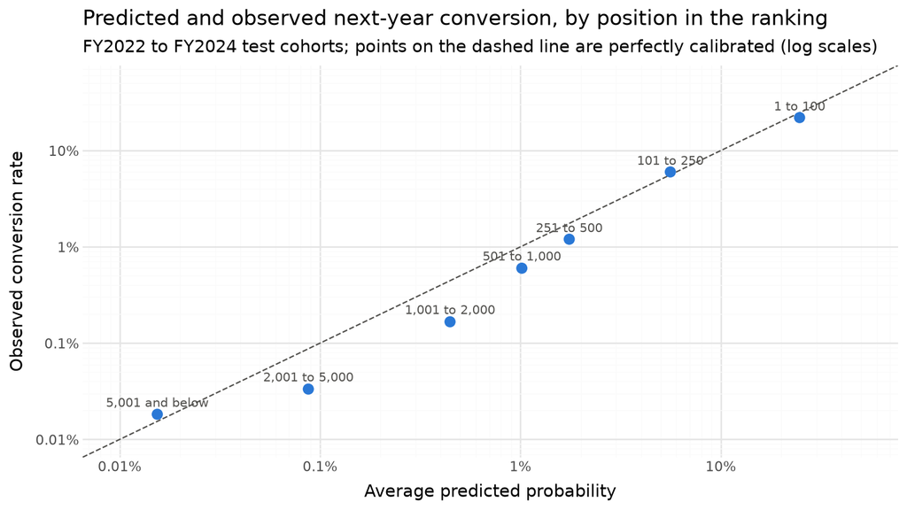

```python
cal_plot = cal_bands.with_columns(ranks=pl.col("ranks").cast(pl.Enum(cal_bands["ranks"].to_list()))).to_pandas()
lim = (1e-4, 0.5)   # wide enough for the first hundred names, near 25%
(
    ggplot(cal_plot, aes("mean_predicted", "observed_rate"))
    + geom_abline(intercept=0, slope=1, color="#52514e", linetype="dashed")
    + geom_point(color="#2a78d6", size=3)
    + geom_text(aes(label="ranks"), nudge_y=0.12, size=8, color="#52514e")
    + scale_x_log10(labels=lambda xs: [f"{100 * x:g}%" for x in xs], limits=lim)
    + scale_y_log10(labels=lambda xs: [f"{100 * x:g}%" for x in xs], limits=lim)
    + labs(x="Average predicted probability", y="Observed conversion rate",
           title="Predicted and observed next-year conversion, by position in the ranking",
           subtitle="FY2022 to FY2024 test cohorts; points on the dashed line are perfectly calibrated (log scales)")
    + theme(figure_size=(8, 4.5))
)
```

### 6.5 What Drives the Score

```python
def input_names(fitted):
    # the model's inputs: the features, then a missing-value indicator for each feature that had gaps in training
    imputer = fitted["estimator"].named_steps["simpleimputer"]
    return list(fitted["columns"]) + [f"missing: {fitted['columns'][i]}" for i in imputer.indicator_.features_]

def describe(name):
    base = name.removeprefix("missing: ")
    if base.startswith("gender_"):
        desc = f"Gender recorded as {base.removeprefix('gender_')}"
    else:
        desc = FEATURES[base][2]
    return f"Missing value for: {desc}" if name.startswith("missing: ") else desc

coefs = final_model["estimator"].named_steps["logisticregression"].coef_[0]
sds = final_model["estimator"].named_steps["standardscaler"].scale_
names = input_names(final_model)
assert len(names) == len(coefs) == len(sds)
X_final, _ = design(frame.filter(pl.col("t").is_between(TUNE_START, 2025)), FINAL_SPEC["features"])
binary = [bool(np.isin(col[~np.isnan(col)], [0, 1]).all()) for col in X_final.T] + [True] * (len(names) - X_final.shape[1])
drivers = (
    pl.DataFrame({"input": names, "coefficient": coefs, "sd": sds, "binary": binary})
    .with_columns(
        odds_ratio_per_sd=pl.col("coefficient").exp(),
        # a rare yes/no input has a small standard deviation, so its effect is clearer as yes against no
        odds_ratio_yes_vs_no=pl.when(pl.col("binary")).then((pl.col("coefficient") / pl.col("sd")).exp()),
        in_model=pl.col("coefficient").abs() >= 0.005,   # weights that round to 0.00 count as dropped
        definition=pl.col("input").map_elements(describe, return_dtype=pl.String),
    )
    .sort(pl.col("coefficient").abs(), descending=True)
)
dv = {r["input"]: r for r in drivers.iter_rows(named=True)}
SHORT_NAMES = {"change_from_last_year": "the change from last year", "two_years_before": "giving in the two years before",
               "years_since_first_gift": "years since the first gift", "legacy_gift_count": "the legacy gift count",
               "largest_gift_share": "the largest gift's share", "soft_before": "soft credits before FY t",
               "sustainer": "the sustainer flag", "missing: monthly_amount": "the missing monthly amount indicator"}
dropped = [r["input"] for r in drivers.iter_rows(named=True) if not r["in_model"]]
dropped_text = ", ".join([SHORT_NAMES.get(i, i) for i in dropped if not i.startswith("gender_")]
                         + (["gender"] if any(i.startswith("gender_") for i in dropped) else []))
n_active, n_inputs = int(drivers["in_model"].sum()), drivers.height
show(drivers.select("input", "definition", "coefficient", "odds_ratio_per_sd", "odds_ratio_yes_vs_no", "in_model")
     .with_columns(pl.col("coefficient", "odds_ratio_per_sd", "odds_ratio_yes_vs_no").round(3)),
     caption="Final model coefficients per standard deviation of each input (dollar inputs log-transformed), with the odds ratio for yes against no on 0/1 inputs, largest first")
```

Table 32: Final model coefficients per standard deviation of each input (dollar inputs log-transformed), with the odds ratio for yes against no on 0/1 inputs, largest first

| Input | Definition | Coefficient | Odds ratio per sd | Odds ratio yes vs no | In model |
| --- | --- | --- | --- | --- | --- |
| prior_total | Giving in FY t: own payments, soft credits, and legacy gifts | 0.92 | 2.52 |  | True |
| largest_gift_t | Largest single gift in FY t | 0.87 | 2.39 |  | True |
| prev_total | Giving in FY t-1 | 0.26 | 1.29 |  | True |
| monthly_amount | Average sustaining payment in FY t (empty for non-sustainers) | -0.24 | 0.79 |  | True |
| former_major | Major donor in any earlier fiscal year | 0.14 | 1.15 | 6.95 | True |
| missing: soft_before | Missing value for: Received a soft credit before FY t (empty through FY2021) | 0.13 | 1.14 | 1.30 | True |
| contacted | Selected in FY t and contacted in FY t+1 (off when scoring) | 0.11 | 1.12 | 3.17 | True |
| years_last5 | Fiscal years with a gift, FY t-4 to FY t | 0.10 | 1.11 |  | True |
| legacy_years | Fiscal years with a legacy-system gift | 0.07 | 1.08 |  | True |
| age_at_t | Age at June 30 of FY t, from the FY2026 snapshot age | 0.07 | 1.07 |  | True |
| missing: monthly_amount | Missing value for: Average sustaining payment in FY t (empty for non-sustainers) | 0.06 | 1.06 | 1.14 | True |
| held_out | Selected in FY t and held out of contact (off when scoring) | 0.01 | 1.01 | 1.22 | True |
| sustainer | Made a recurring (Unite) or sustaining (legacy) payment in FY t | -0.00 | 1.00 | 1.00 | False |
| change_from_last_year | FY t giving minus FY t-1 giving | 0.00 | 1.00 |  | False |
| two_years_before | Total giving in FY t-2 and FY t-1 | 0.00 | 1.00 |  | False |
| years_since_first_gift | Years from the first fiscal year with a gift (legacy included) to FY t | 0.00 | 1.00 |  | False |
| legacy_gift_count | Number of legacy-system gifts | 0.00 | 1.00 |  | False |
| largest_gift_share | Largest single gift as a share of FY t giving | 0.00 | 1.00 |  | False |
| soft_before | Received a soft credit before FY t (empty through FY2021) | 0.00 | 1.00 | 1.00 | False |
| gender_Female | Gender recorded as Female | 0.00 | 1.00 | 1.00 | False |
| gender_Male | Gender recorded as Male | 0.00 | 1.00 | 1.00 | False |
| gender_Unknown | Gender recorded as Unknown | 0.00 | 1.00 | 1.00 | False |

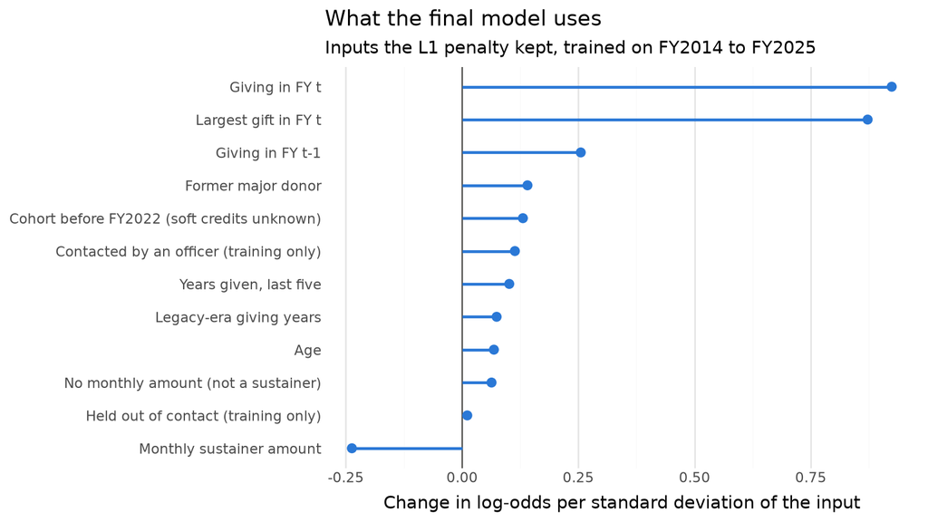

```python
PLOT_LABELS = {"prior_total": "Giving in FY t", "largest_gift_t": "Largest gift in FY t", "prev_total": "Giving in FY t-1",
               "former_major": "Former major donor", "missing: soft_before": "Cohort before FY2022 (soft credits unknown)",
               "contacted": "Contacted by an officer (training only)", "years_last5": "Years given, last five",
               "legacy_years": "Legacy-era giving years", "age_at_t": "Age", "missing: monthly_amount": "No monthly amount (not a sustainer)",
               "held_out": "Held out of contact (training only)", "sustainer": "Sustainer", "monthly_amount": "Monthly sustainer amount"}
active = drivers.filter(pl.col("in_model")).sort("coefficient").with_columns(
    label=pl.col("input").replace_strict(PLOT_LABELS, default=pl.col("input")))
active_pd = active.with_columns(label=pl.col("label").cast(pl.Enum(active["label"].to_list()))).to_pandas()
(
    ggplot(active_pd, aes("coefficient", "label"))
    + geom_vline(xintercept=0, color="#52514e")
    + geom_segment(aes(x=0, xend="coefficient", y="label", yend="label"), color="#2a78d6", size=1)
    + geom_point(color="#2a78d6", size=2.5)
    + labs(x="Change in log-odds per standard deviation of the input", y="",
           title="What the final model uses", subtitle="Inputs the L1 penalty kept, trained on FY2014 to FY2025")
    + theme(panel_grid_major_y=element_blank(), figure_size=(8, 4.5))
)
```

```python
def contributions(fitted, df):
    """Each input's contribution to each donor's log-odds: the coefficient times the donor's standardized input."""
    X, _ = design(scoring_view(df), FINAL_SPEC["features"])
    Z = fitted["estimator"][:-1].transform(X)
    lr = fitted["estimator"][-1]
    return Z * lr.coef_[0], float(lr.intercept_[0])

# the never-major donor ranked highest in the FY2025 check, scored by the check model
top_never = fy25_df.filter(~pl.col("former_major")).sort("model_score", descending=True).head(1)
contrib, intercept = contributions(check_model, fy25.join(top_never.select("constituent_id", "t"), on=["constituent_id", "t"]))
example = (
    pl.DataFrame({"input": input_names(check_model), "contribution": contrib[0]})
    .filter(pl.col("contribution").abs() > 1e-6).sort(pl.col("contribution").abs(), descending=True).head(6)
)
example_rank = int(fy25_df.with_columns(r=pl.col("model_score").rank("ordinal", descending=True))
                   .join(top_never.select("constituent_id"), on="constituent_id")["r"][0])
example_vals = fy25.join(top_never.select("constituent_id", "t"), on=["constituent_id", "t"]).row(0, named=True)
show(example.with_columns(pl.col("contribution").round(2)),
     caption="The largest contributions to one donor's score: the top-ranked never-major donor in the FY2025 check")
```

Table 33: The largest contributions to one donor's score: the top-ranked never-major donor in the FY2025 check

| Input | Contribution |
| --- | --- |
| largest_gift_t | 2.63 |
| prior_total | 2.13 |
| prev_total | 0.41 |
| missing: soft_before | -0.20 |
| years_last5 | 0.17 |
| legacy_years | 0.16 |

```python
ins, oos_r, chk = pf["in-sample"], pf["out-of-sample"], pf["FY2025 check"]
assert oos_r["gain_low"] > 0 and chk["gain_vs_rule_low"] > 0 and not NEEDS_RECALIBRATION
assert all(sz[(k, "all eligible")]["gain_low"] > 0 for k in (250, 500, 1000)) and sz[(2000, "all eligible")]["gain_high"] > 0
top_band, mid_band = cal_bands.row(0, named=True), cal_bands.filter(pl.col("ranks") == "2,001 to 5,000").row(0, named=True)
band_101 = cal_bands.filter(pl.col("ranks") == "101 to 250").row(0, named=True)
```

**In-sample against out-of-sample.** Scored on the cohorts it was trained on, the model holds 85.4% of converters in each year’s top 1,000, against 82.8% on the rolling test cohorts it had not seen. A gap of 2.5 points is small, as expected from a penalized linear model with 12 active inputs, so the model is not memorizing its training donors. Its gain over the prior-year ranking is actually larger out of sample (7.4 points against 4.2), mainly because the ranking itself does better in the older training cohorts (81.1%) than in FY2022 to FY2024 (75.4%).

**The FY2025 check.** On the cohort held back from every comparison, the model holds 75.3% of converters against 69.2% for the prior-year ranking, a gain of 6.1 points (95% interval -1.3 to 13.7). That is about the same size as the gain on the test cohorts, but with 81 converters the interval includes zero, so FY2025 alone does not clear the prior-year bar. The model does clear the former major or $500 rule on FY2025 by 10.4 points (lower bound 3.2). Both the model and the ranking find a smaller share of FY2025 converters than in earlier cohorts, which fits the group EDA’s finding that more FY2026 converters came from lower in the giving range. For never-major donors the model holds 59.1% against 56.6%. On the FY2025 no-contact pool it holds 71.3%, against 69.4% for officer selection and 69.5% for the ranking, with intervals too wide to separate them. Under the first rule, the result does not change the model, and the weaker FY2025 showing is carried into the Results section as a risk.

**List size.** The model’s advantage sits at the top of the list. At 250, 500, and 1,000 names it holds 6.1 to 7.4 points more of the converters than the prior-year ranking, each gain clearing the 95% rule. By 2,000 names the two have converged (86.6% against 87.2%), because a list that long reaches most of the same converters either way. For never-major donors the model does not beat the ranking at any list size. The model is most useful for short lists worked intensively, which is how the cultivation program works.

**Calibration.** Over the test cohorts the model predicted 1.21 times as many conversions as occurred, inside the 0.8 to 1.25 range, so under the second rule the probabilities are reported without correction. The first hundred names are close to right (24.7% predicted against 22.0% observed), while the middle of the list is overpredicted (0.087% against 0.033% at ranks 2,001 to 5,000). The ratio also varies by cohort, from 1.03 to 1.48. The FY2025 check is a warning: there the model predicted only 48% of the conversions that happened, because the FY2026 influx roughly doubled the conversion rate. Its Brier score on the test cohorts (0.00117) is better than predicting the base rate for everyone (0.00138), but staff should read the probabilities as a ranking with rough magnitudes, and the calibration should be checked again once FY2027 outcomes are known.

**What drives the score.** The L1 penalty kept 12 of the 22 inputs. The largest weights go to FY t giving and the largest single gift in FY t (odds ratios of 2.52 and 2.39 per standard deviation of their logs), followed by FY t-1 giving. Being a former major donor multiplies the odds by 6.9 against an otherwise similar donor. A higher monthly sustainer amount lowers the odds, matching the group EDA’s finding that sustainers convert less than their giving predicts. The sustainer flag and the indicator for a missing monthly amount are mirror images of each other, so the penalty splits their weight arbitrarily, and they should be read together. Contact by an officer raises the odds in training (3.2 times), which is the program effect the flag is there to absorb, and it is switched off when donors are scored. The indicator for a missing “soft credit before FY t” marks the cohorts before FY2022, so its positive weight says those older cohorts converted somewhat more often at the same giving level. Donors scored today all have that indicator switched off, which pulls their probabilities down toward the recent base rate and may be part of why the model underpredicted the FY2026 influx. The penalty dropped the sustainer flag, the change from last year, giving in the two years before, years since the first gift, the legacy gift count, the largest gift’s share, soft credits before FY t, gender, since the inputs above already carry what they would add.

**One donor’s score.** The table above breaks down the score of the never-major donor the check model ranked highest in FY2025, number 105 overall. This donor gave $600 in FY2025 and $600 the year before, gave in 5 of the last five years, and was 69 years old. Most of the score comes from the size of the FY2025 gift and total, with smaller contributions from steady giving. The donor did not become a major donor in FY2026, a reminder that even near the top of the list conversion is uncommon: 6% of donors ranked 101 to 250 converted in the test cohorts. This breakdown, coefficient times the donor’s standardized input, is what the working queue in the Business Validation section shows for each donor.

**Run time.** Tuning the penalty by inner cross-validation took 18 minutes on the final training data, fitting the final model took 6 seconds on 306,685 donor-years, and scoring a cohort of 32,886 donors took 0.02 seconds. A yearly refit and rescoring needs nothing beyond an ordinary laptop.

## 7 Longer Windows and Giving Tier

The business problem asks for two more things besides the 12 month list: which donors are likely to become major donors within 3 to 5 years (the long-term nurture segment), and the giving tier a converter is likely to reach. This section handles both with less tuning than the 12 month model, as planned, and reports the longer windows as a projection.

### 7.1 Becoming a Major Donor Within 3 or 5 Years

A strictly time-based test of a longer outcome needs training cohorts whose outcome windows had closed by the test cohort’s prediction date. For the 3 year outcome, a test cohort T can only train on cohorts up to T-3, and for the 5 year outcome up to T-5. That pushes the training data back into the legacy years, so these models train on cohorts from FY1999 onward rather than FY2014, which the training window comparison found does no harm.

Test design for the longer outcomes

| Outcome | Test cohorts | Labeled check | Training cohorts for the first test |
| --- | --- | --- | --- |
| Within 3 years | FY2021 and FY2022 (outcomes through FY2025) | FY2023 (its window reaches FY2026) | FY1999 to FY2018 |
| Within 5 years | FY2016 to FY2020 (outcomes through FY2025) | FY2021 (its window reaches FY2026) | FY1999 to FY2011 |

The four shortlisted models are refit on each outcome with their chosen feature sets and their screen-sized grids, and compared with the prior-year ranking and the former major or $500 rule on the same resamples. Three rules were set before the runs. The L1 logistic regression, the 12 month model, is the reported model for the longer outcomes unless another shortlisted model beats it under the same paired rule. With no measurable difference, it stays. And as with FY2025, the labeled checks cannot change anything.

```python
LONG_START = 1999
LONG = {
    "within 3 years": {"target": "y_3yr", "window": 3, "test": [2021, 2022], "check": 2023},
    "within 5 years": {"target": "y_5yr", "window": 5, "test": [2016, 2017, 2018, 2019, 2020], "check": 2021},
}
long_runs = {
    (o, m): cached_nested(chosen_spec(m, LONG_START), SHORTLIST[m]["grid"],
                          target=cfg["target"], window=cfg["window"], test_cohorts=cfg["test"])
    for o, cfg in LONG.items() for m in SHORTLIST
}
```

```python
LONG_BARS = {"prior-year giving": "prior_total", "former major or $500": "rule_former_or_500"}

def long_frame(cfg, cohorts):
    # donor-years in the given cohorts with the longer outcome as y
    return scored.filter(pl.col("t").is_in(cohorts)).with_columns(y=pl.col(cfg["target"]), w=pl.lit(1.0))

long_rows, long_boots, long_choice, long_selection = [], {}, {}, []
for o, cfg in LONG.items():
    df = long_frame(cfg, cfg["test"])
    for m in SHORTLIST:
        df = df.join(long_runs[(o, m)][0].rename({"score": f"score__{m}"}), on=["constituent_id", "t"], how="left")
    specs = {**LONG_BARS, **{m: f"score__{m}" for m in SHORTLIST}}
    b = {"all eligible": bootstrap(df, specs), "never major": bootstrap(df.filter(~pl.col("former_major")), specs)}
    long_boots[o] = b
    for name in specs:
        row = {"outcome": o, "ranking": name, "converters": int(df["y"].sum()),
               "recall_all": b["all eligible"]["point"][name][0], "recall_never_major": b["never major"]["point"][name][0]}
        if name in SHORTLIST:
            for g, label in (("all eligible", "all"), ("never major", "never")):
                d_ = paired_difference(b[g], name, "prior-year giving")
                row |= {f"{label}_gain": 100 * d_["difference"], f"{label}_low": 100 * d_["low"], f"{label}_high": 100 * d_["high"]}
        long_rows.append(row)
    # rule 1: the 12 month model stays unless another shortlisted model beats it on paired draws
    current = SELECTED
    for challenger in [m for m in SIMPLICITY_ORDER if m in SHORTLIST and m != SELECTED]:
        d_all = paired_difference(b["all eligible"], challenger, current)
        d_never = paired_difference(b["never major"], challenger, current)
        wins = (d_all["low"] > 0 and d_never["high"] >= 0) or (d_never["low"] > 0 and d_all["high"] >= 0)
        long_selection.append({"outcome": o, "challenger": challenger, "current_choice": current,
                               "all_gain": 100 * d_all["difference"], "all_low": 100 * d_all["low"], "all_high": 100 * d_all["high"],
                               "never_major_gain": 100 * d_never["difference"], "never_major_low": 100 * d_never["low"],
                               "never_major_high": 100 * d_never["high"], "replaces_current": bool(wins)})
        if wins:
            current = challenger
    long_choice[o] = current
long_table = pl.DataFrame(long_rows)
long_selection = pl.DataFrame(long_selection)
lg = {(r["outcome"], r["ranking"]): r for r in long_table.iter_rows(named=True)}
show(long_table.with_columns(pl.col("^.*_(gain|low|high)$").round(1)),
     pct_cols=["recall_all", "recall_never_major"],
     caption="Longer outcomes: recall at 1,000 on the test cohorts, with the paired gain over the prior-year ranking in percentage points")
```

Table 34: Longer outcomes: recall at 1,000 on the test cohorts, with the paired gain over the prior-year ranking in percentage points

| Outcome | Ranking | Converters | Recall all | Recall never major | All gain | All low | All high | Never gain | Never low | Never high |
| --- | --- | --- | --- | --- | --- | --- | --- | --- | --- | --- |
| within 3 years | prior-year giving | 223 | 58.8% | 39.8% |  |  |  |  |  |  |
| within 3 years | former major or $500 | 223 | 61.8% | 30.5% |  |  |  |  |  |  |
| within 3 years | logistic regression (L2) | 223 | 67.3% | 41.8% | 8.50 | 4.10 | 13.10 | 2.00 | -4.70 | 7.90 |
| within 3 years | logistic regression (L1) | 223 | 66.4% | 42.6% | 7.60 | 3.30 | 12.30 | 2.80 | -3.00 | 9.40 |
| within 3 years | explainable boosting machine | 223 | 65.9% | 41.8% | 7.10 | 2.60 | 11.70 | 2.00 | -4.10 | 8.10 |
| within 3 years | XGBoost | 223 | 65.9% | 40.2% | 7.10 | 2.50 | 11.10 | 0.30 | -4.70 | 4.80 |
| within 5 years | prior-year giving | 708 | 58.4% | 48.8% |  |  |  |  |  |  |
| within 5 years | former major or $500 | 708 | 50.1% | 31.3% |  |  |  |  |  |  |
| within 5 years | logistic regression (L2) | 708 | 61.9% | 48.3% | 3.40 | 0.60 | 6.50 | -0.50 | -3.50 | 2.50 |
| within 5 years | logistic regression (L1) | 708 | 61.2% | 46.6% | 2.70 | -0.20 | 5.20 | -2.30 | -5.40 | 0.60 |
| within 5 years | explainable boosting machine | 708 | 64.0% | 51.1% | 5.50 | 3.20 | 7.90 | 2.20 | 0.20 | 4.20 |
| within 5 years | XGBoost | 708 | 62.0% | 49.1% | 3.60 | 0.90 | 5.80 | 0.30 | -2.40 | 2.20 |

```python
show(long_selection.with_columns(pl.col("^.*_(gain|low|high)$").round(1)),
     caption="Model choice for the longer outcomes, step by step: each challenger against the current choice, paired differences in recall at 1,000 (percentage points)")
```

Table 35: Model choice for the longer outcomes, step by step: each challenger against the current choice, paired differences in recall at 1,000 (percentage points)

| Outcome | Challenger | Current choice | All gain | All low | All high | Never major gain | Never major low | Never major high | Replaces current |
| --- | --- | --- | --- | --- | --- | --- | --- | --- | --- |
| within 3 years | logistic regression (L2) | logistic regression (L1) | 0.90 | -0.50 | 2.70 | -0.80 | -5.60 | 2.30 | False |
| within 3 years | explainable boosting machine | logistic regression (L1) | -0.40 | -3.80 | 2.60 | -0.80 | -5.70 | 3.50 | False |
| within 3 years | XGBoost | logistic regression (L1) | -0.40 | -3.80 | 2.00 | -2.50 | -9.30 | 2.50 | False |
| within 5 years | logistic regression (L2) | logistic regression (L1) | 0.70 | -0.80 | 2.60 | 1.80 | -0.20 | 4.10 | False |
| within 5 years | explainable boosting machine | logistic regression (L1) | 2.80 | 1.00 | 4.90 | 4.50 | 2.10 | 7.20 | True |
| within 5 years | XGBoost | explainable boosting machine | -2.00 | -3.80 | -0.60 | -2.00 | -4.70 | 0.20 | False |

```python
# labeled checks for the model reported for each outcome; they are reported but cannot change it
long_checks = {
    o: cached_nested(chosen_spec(long_choice[o], LONG_START), SHORTLIST[long_choice[o]]["grid"],
                     target=cfg["target"], window=cfg["window"], test_cohorts=[cfg["check"]])
    for o, cfg in LONG.items()
}
long_check_rows = []
for o, cfg in LONG.items():
    df = long_frame(cfg, [cfg["check"]]).join(long_checks[o][0].rename({"score": "model_score"}), on=["constituent_id", "t"], how="left")
    b = bootstrap(df, {"model": "model_score", **LONG_BARS})
    d_ = paired_difference(b, "model", "prior-year giving")
    long_check_rows.append({"outcome": o, "model": long_choice[o], "check_cohort": cfg["check"], "converters": int(df["y"].sum()),
                            "model_recall": b["point"]["model"][0], "prior_year_recall": b["point"]["prior-year giving"][0],
                            "gain": 100 * d_["difference"], "gain_low": 100 * d_["low"], "gain_high": 100 * d_["high"]})
long_check_table = pl.DataFrame(long_check_rows)
lc = {r["outcome"]: r for r in long_check_table.iter_rows(named=True)}
show(long_check_table.with_columns(pl.col("gain", "gain_low", "gain_high").round(1)),
     pct_cols=["model_recall", "prior_year_recall"],
     caption="Labeled checks for the longer outcomes, using the model reported for each, reported only")
```

Table 36: Labeled checks for the longer outcomes, using the model reported for each, reported only

| Outcome | Model | Check cohort | Converters | Model recall | Prior year recall | Gain | Gain low | Gain high |
| --- | --- | --- | --- | --- | --- | --- | --- | --- |
| within 3 years | logistic regression (L1) | 2,023 | 120 | 65.8% | 56.5% | 9.30 | 2.80 | 15.80 |
| within 5 years | explainable boosting machine | 2,021 | 169 | 54.4% | 49.0% | 5.40 | 1.20 | 9.70 |

```python
o3, o5 = "within 3 years", "within 5 years"
m3, m5 = long_choice[o3], long_choice[o5]
assert m3 == SELECTED and m5 == "explainable boosting machine"
r3, r5 = lg[(o3, m3)], lg[(o5, m5)]
r5_l1 = lg[(o5, SELECTED)]
rule3 = paired_difference(long_boots[o3]["all eligible"], m3, "former major or $500")
rule5 = paired_difference(long_boots[o5]["all eligible"], m5, "former major or $500")
sw = long_selection.filter((pl.col("outcome") == o5) & pl.col("replaces_current")).row(0, named=True)
assert r3["all_low"] > 0 and r5["all_low"] > 0 and r5["never_low"] > 0 and not r3["never_low"] > 0
assert rule3["low"] > 0 and rule5["low"] > 0 and all(lc[o]["gain_low"] > 0 for o in LONG)
```

**Within 3 years.** The L1 logistic regression, the 12 month model refit on the 3 year outcome, holds 66.4% of 3 year converters in its top 1,000, against 58.8% for the prior-year ranking, a gain of 7.6 points (95% interval 3.3 to 12.3). It also clears the former major or $500 rule (4.6 points, lower bound 1.5). No other shortlisted model beats it, so it stays the 3 year model. For never-major donors it gains 2.8 points, with an interval that includes zero. On the FY2023 check, whose window reaches into FY2026, it holds 65.8% against 56.5%, a gain of 9.3 points (2.8 to 15.8).

**Within 5 years.** Here the rule changes the model. The L1 logistic regression gains only 2.7 points over the prior-year ranking (-0.2 to 5.2), not enough to clear the bar. The explainable boosting machine beats it on the same resamples by 2.8 points for all eligible donors (1.0 to 4.9) and 4.5 for never-major donors (2.1 to 7.2), so it replaces the regression for this outcome. It holds 64.0% of 5 year converters against 58.4% for the ranking (+5.5 points, 3.2 to 7.9), and 51.1% of never-major converters against 48.8%, a gain of 2.2 points whose interval (0.2 to 4.2) stays above zero. That makes it the only model in this notebook to clear the never-major bar for any outcome. Its FY2021 check agrees: 54.4% against 49.0%, a gain of 5.4 points (1.2 to 9.7).

A plausible reason the boosting machine does better over five years is that a long horizon depends on how a donor’s giving has been moving, not just its level. Its curve for each feature can capture that a modest but steady or rising giver is a better long-term prospect than the level alone suggests, while the regression is limited to one slope per input. The test cohorts for the 5 year outcome all come from the legacy era, though, so this result describes how giving history predicted long-term conversion in FY2016 to FY2020. As the business problem anticipated, it should be read as a projection for current donors, not a tested forecast.

### 7.2 Giving Tier

For donors who do convert, the business problem asks for the tier they are likely to reach: $1,200 to $1,999, $2,000 to $4,999, or $5,000 and up. The tier is measured in the conversion year, FY t+1, using the couple’s combined giving when only the couple together reaches $1,200, as in the group EDA. Three approaches are compared, from simplest to most complex, each trained on the converters in cohorts FY2014 through the year before the test cohort and tested on the converters in FY2022 to FY2024:

- **Giving band rule.** Predict the tier most common among earlier converters in the same band of FY t giving.
- **Multinomial logistic regression.** One model for the three tiers, on the same feature set and preprocessing as the 12 month model.
- **Ordinal logistic regression.** A model that treats the tiers as ordered, on four inputs: FY t giving, the largest gift in FY t, FY t-1 giving, and former major status.

They are scored by exact accuracy and by accuracy within one tier. With only three tiers, within one tier misses only when a $1,200 converter is predicted at $5,000 and up or the reverse, so it is close to automatic and is reported mainly for completeness. The rule set before the comparison: the band rule is used unless a more complex approach has higher exact accuracy with a paired 95% interval above zero.

```python
TIER_NAMES = ["$1,200", "$2,000", "$5,000+"]
conversion_giving = person_years.select(
    "constituent_id", t=pl.col("fy") - 1,
    conversion_total=pl.when(pl.col("major_combined_only")).then(pl.col("total") + pl.col("spouse_total")).otherwise(pl.col("total")),
)
converters = (
    frame.filter(pl.col("y_12m"))
    .join(conversion_giving, on=["constituent_id", "t"], how="left")
    .with_columns(tier=pl.col("conversion_total").cut([2000, 5000], labels=TIER_NAMES, left_closed=True).cast(pl.Enum(TIER_NAMES)))
    .with_columns(tier_code=pl.col("tier").to_physical().cast(pl.Int64))
)
assert converters["conversion_total"].null_count() == 0 and (converters["conversion_total"] >= 1200).all()
tier_counts = (converters.filter(pl.col("t").is_between(TUNE_START, 2024))
               .group_by(cohorts_=pl.when(pl.col("t") < 2022).then(pl.lit("training, FY2014 to FY2021"))
                         .otherwise(pl.lit("test, FY2022 to FY2024")), tier=pl.col("tier"))
               .len().pivot(on="tier", index="cohorts_", values="len").rename({"cohorts_": "converters"})
               .select("converters", *TIER_NAMES).sort("converters", descending=True))
show(tier_counts, caption="Tier reached in the conversion year by 12 month converters")
```

Table 37: Tier reached in the conversion year by 12 month converters

| Converters | $1,200 | $2,000 | $5,000+ |
| --- | --- | --- | --- |
| training, FY2014 to FY2021 | 233 | 84 | 14 |
| test, FY2022 to FY2024 | 79 | 51 | 4 |

```python
from statsmodels.miscmodels.ordinal_model import OrderedModel

GIVING_BANDS = [240, 500]   # FY t giving: $240 or less, $241 to $500, over $500
ORDINAL_INPUTS = ["prior_total", "largest_gift_t", "prev_total", "former_major"]

def band_rule(train, test):
    # most common tier among training converters in the same FY t giving band
    band = pl.col("prior_total").cut(GIVING_BANDS).cast(pl.String).alias("band")
    modal = (train.with_columns(band).group_by("band", "tier_code").len()
             .sort("len", descending=True).unique("band", keep="first").select("band", "tier_code"))
    overall = int(train["tier_code"].mode()[0])
    return test.with_columns(band).join(modal, on="band", how="left")["tier_code_right"].fill_null(overall).to_numpy()

def multinomial(train, test):
    spec = {**FINAL_SPEC, "model": LogisticRegression(max_iter=2000)}
    X, cols = design(train, spec["features"])
    est = build(spec, cols).fit(X, train["tier_code"].to_numpy())
    X_test, _ = design(scoring_view(test), spec["features"])
    return est.classes_[est.predict_proba(X_test).argmax(axis=1)]

def ordinal(train, test):
    def inputs(df):
        return df.select([pl.col(c).cast(pl.Float64) for c in ORDINAL_INPUTS]).to_numpy()
    X, X_test = inputs(train), inputs(test)
    X[:, :3], X_test[:, :3] = signed_log(X[:, :3]), signed_log(X_test[:, :3])
    res = OrderedModel(train["tier_code"].to_numpy(), X, distr="logit").fit(method="bfgs", disp=False, maxiter=2000)
    return res.model.predict(res.params, exog=X_test).argmax(axis=1)

TIER_APPROACHES = {"giving band rule": band_rule, "multinomial logistic regression": multinomial,
                   "ordinal logistic regression": ordinal}
tier_parts = []
for T in TEST_COHORTS:
    train = converters.filter(pl.col("t").is_between(TUNE_START, T - 1))
    test = converters.filter(pl.col("t") == T)
    tier_parts.append(test.select("constituent_id", "couple_id", "t", "tier_code", "former_major").with_columns(
        [pl.Series(name, fn(train, test)).cast(pl.Int64).alias(name) for name, fn in TIER_APPROACHES.items()]))
tier_preds = pl.concat(tier_parts)
assert tier_preds.height == int(test_scored["y"].sum())
```

```python
def tier_bootstrap(df, cols, reps=REPS, seed=SEED):
    # exact accuracy for each prediction column on couple-clustered resamples (paired across columns)
    couples = df["couple_id"].unique().sort()
    idx = couples.search_sorted(df["couple_id"]).to_numpy()
    hits = {c: (df[c] == df["tier_code"]).cast(pl.Float64).to_numpy() for c in cols}
    rng = np.random.default_rng(seed)
    draws = {c: np.empty(reps) for c in cols}
    for r in range(reps):
        mult = np.bincount(rng.integers(0, len(couples), len(couples)), minlength=len(couples))[idx]
        for c in cols:
            draws[c][r] = (hits[c] * mult).sum() / mult.sum()
    return {c: hits[c].mean() for c in cols}, draws

approaches = list(TIER_APPROACHES)
tier_point, tier_draws = tier_bootstrap(tier_preds, approaches)
tier_rows = []
for a in approaches:
    within_one = float(((tier_preds[a] - tier_preds["tier_code"]).abs() <= 1).mean())
    diff = tier_draws[a] - tier_draws["giving band rule"]
    tier_rows.append({
        "approach": a, "exact_accuracy": tier_point[a],
        "accuracy_low": float(np.quantile(tier_draws[a], 0.025)), "accuracy_high": float(np.quantile(tier_draws[a], 0.975)),
        "within_one_tier": within_one,
        "gain_vs_rule": 100 * (tier_point[a] - tier_point["giving band rule"]),
        "gain_low": 100 * float(np.quantile(diff, 0.025)), "gain_high": 100 * float(np.quantile(diff, 0.975)),
        "share_predicted_2000_or_more": float((tier_preds[a] >= 1).mean()),
    })
tier_table = pl.DataFrame(tier_rows)
tt = {r["approach"]: r for r in tier_table.iter_rows(named=True)}
TIER_CHOICE = "giving band rule"
for a in approaches[1:]:   # simplest first; a more complex approach must win on paired draws
    if tt[a]["gain_low"] > 0 and tt[a]["exact_accuracy"] > tt[TIER_CHOICE]["exact_accuracy"]:
        TIER_CHOICE = a
show(tier_table.with_columns(pl.col("gain_vs_rule", "gain_low", "gain_high").round(1)),
     pct_cols=["exact_accuracy", "accuracy_low", "accuracy_high", "within_one_tier", "share_predicted_2000_or_more"],
     caption="Tier predictions for the FY2022 to FY2024 test converters")
```

Table 38: Tier predictions for the FY2022 to FY2024 test converters

| Approach | Exact accuracy | Accuracy low | Accuracy high | Within one tier | Gain vs rule | Gain low | Gain high | Share predicted 2000 or more |
| --- | --- | --- | --- | --- | --- | --- | --- | --- |
| giving band rule | 59.0% | 50.7% | 67.6% | 97.0% | 0.00 | 0.00 | 0.00 | 0.0% |
| multinomial logistic regression | 46.3% | 38.3% | 54.8% | 88.8% | -12.70 | -20.70 | -4.40 | 31.3% |
| ordinal logistic regression | 58.2% | 50.0% | 66.9% | 97.0% | -0.70 | -3.10 | 1.50 | 2.2% |

```python
assert TIER_CHOICE == "giving band rule"
tier_test = converters.filter(pl.col("t").is_in(TEST_COHORTS))
tier_share = {name: float((tier_test["tier"] == name).mean()) for name in TIER_NAMES}
tier_train = converters.filter(pl.col("t").is_between(TUNE_START, 2021))
tier_share_train = {name: float((tier_train["tier"] == name).mean()) for name in TIER_NAMES}
nv_tier = tier_preds.filter(~pl.col("former_major"))
```

The tier cannot be predicted from these data any better than by always naming the most common tier. In every band of FY t giving, most earlier converters landed in the $1,200 tier, so the band rule predicts $1,200 for everyone and is right 59% of the time, the share of test converters who stopped there. The multinomial regression tries to pick out $2,000 and $5,000 converters, predicting one of those tiers for 31% of converters, and does measurably worse (-12.7 points, 95% interval -20.7 to -4.4). The ordinal regression almost always predicts $1,200 too and lands within a point of the rule. Under the rule set for this comparison, the band rule stays.

The practical reading is that whether a new major donor gives $1,200 or $2,000 is not visible in the giving history before conversion. It may depend on things the data do not record, such as the size of the ask or the donor’s relationship with an officer. For the working queue this means the tier should be shown as an expected mix rather than a prediction: among test-cohort converters 59% reached $1,200 to $1,999, 38% reached $2,000 to $4,999, and 3% reached $5,000 or more. The $2,000 share is higher than in the FY2014 to FY2021 converters (25%), another sign that recent converters are giving more when they convert.

## 8 Business Validation

The model beats the benchmark. This section asks the business question: is that enough to help PBS Utah close a gap of about $2 million a year, and what would staff actually work from?

### 8.1 What the List Is Worth

```python
# converters each ranking puts in a list of 1,000 per year, on the test cohorts and in FY2025
per_year = len(TEST_COHORTS)
found = {
    "selected model": oos_r["recall"] * oos_r["converters"] / per_year,
    "prior-year giving": oos_r["prior_year_recall"] * oos_r["converters"] / per_year,
}
found_25 = {"selected model": chk["recall"] * chk["converters"], "prior-year giving": chk["prior_year_recall"] * chk["converters"]}

# what converters give in the conversion year, and whether they stay major a year later
test_conv = converters.filter(pl.col("t").is_in(TEST_COHORTS))
mean_conv_total = float(test_conv["conversion_total"].mean())
median_conv_total = float(test_conv["conversion_total"].median())
mean_increase = float((test_conv["conversion_total"] - test_conv["prior_total"]).mean())
next_major = person_years.filter(pl.col("major")).select("constituent_id", t=pl.col("fy") - 2, major_after=pl.lit(True))
stay = (converters.filter(pl.col("t").is_between(TUNE_START, 2024))
        .join(next_major, on=["constituent_id", "t"], how="left")["major_after"].fill_null(False).mean())

value_rows = []
for name in ("selected model", "prior-year giving"):
    value_rows.append({"ranking": name, "converters_per_year_test": found[name], "converters_FY2025": found_25[name],
                       "conversion_year_giving_per_year": found[name] * mean_conv_total,
                       "increase_over_FY_t_per_year": found[name] * mean_increase})
value = pl.DataFrame(value_rows)
gain_per_year = found["selected model"] - found["prior-year giving"]
GAP = 2_000_000
show(value.with_columns(pl.col("converters_per_year_test", "converters_FY2025").round(1),
                        pl.col("conversion_year_giving_per_year", "increase_over_FY_t_per_year").round(0)),
     caption="Converters on a list of 1,000 and their conversion-year giving, per year (test cohort average) and in FY2025")
```

Table 39: Converters on a list of 1,000 and their conversion-year giving, per year (test cohort average) and in FY2025

| Ranking | Converters per year test | Converters FY2025 | Conversion year giving per year | Increase over FY t per year |
| --- | --- | --- | --- | --- |
| selected model | 37.00 | 61.00 | 79,689.00 | 62,579.00 |
| prior-year giving | 33.70 | 56.00 | 72,541.00 | 56,966.00 |

```python
l250 = sz[(250, "all eligible")]
conv_value_share = value.filter(pl.col("ranking") == "selected model")["conversion_year_giving_per_year"][0] / GAP
gain_value = gain_per_year * mean_conv_total
# a perfect list would hold every converter: the ceiling on what ranking the eligible pool can deliver
perfect_value = oos_r["converters"] / per_year * mean_conv_total
```

On the test cohorts the selected model’s list of 1,000 held 37.0 converters a year, against 33.7 for a list ranked by prior-year giving, about 3 more a year. In FY2025, the year of the influx, the counts were 61 and 56. A converter gave $2,154 on average in the conversion year (the median is $1,200, since most land just over the line), about $1,691 more than in the year before. Only 39% of new major donors were still major donors the following year.

Put in dollars, the converters on the model’s list give about $79,689 a year in their conversion year, roughly 4% of a $2 million gap, and the model’s edge over the simple ranking is worth about $7,148 a year. These figures count only the conversion year and only donors who would have converted anyway, since contact effects are outside this model, so they understate what a cultivated list could produce. Even so, the scale is clear. A perfect list that held every converter would bring in about $96,201 a year in conversion-year giving, so no ranking of current non-major donors, however good, closes a $2 million gap through new major donors alone.

Where the model does help is in how staff time is spent. Its advantage is largest at the top of the list: in a list of 250, about one donor in 8 became a major donor the next year, and the list held 69% of all converters, 6.1 points more than the prior-year ranking. Officers can start with the donors most likely to convert and see why each one is on the list.